# Epidemic Zones Analysis

Norman Hassell, Perrine Marcenac, Cédric Batiano, and Melissa Rolfes

2026-11-01

## 1. Reading and Cleaning Influenza Testing Data

```r
# library loading
library(patchwork)
library(fda.usc)
library(fda)
library(rnaturalearth)
library(tinytex)
library(tidyverse)
library(gridExtra)
library(lubridate)
library(xaringan)
library(ggplot2)
library(sf)
library(sp)
library(rnaturalearthdata)
library(janitor)
library(wesanderson)
library(reshape2)
library(dtw)
library(TSdist)
library(TSclust)
library(viridis)
library(purrr)
library(parallel)
library(cluster)
library(ggpubr)
library(flextable)
library(zoo)
library(readxl)
library(ggforce)
library(cowplot)
library(downloadthis)
library(dtwclust)
library(broom)
library(imputeTS)
library(pracma)
library(WDI)
library(Hmisc)
library(maps)
library(R.devices)
library(plotly)
library(countrycode)
library(kmer)
library(ape)
library(DBI)
library(odbc)
library(kernlab)
library(factoextra)
library(modelr)
library(dplyr)
library(magrittr)
library(rstatix)
library(scales)
library(cowplot)
library(fitdistrplus)
library(nortest)
library(modeest)
library(diptest)
library(multimode)
library(cowplot)
library(kableExtra)
library(gtsummary)
library(smacof)
library(clue)
library(fpc)
library(igraph)
library(ggraph)
library(kernlab)
library(grid)

`%notin%` <- Negate(`%in%`)

# Function to calculate season of date
getSeason <- function(input.date){
  numeric.date <- 100*month(input.date)+day(input.date)
  ## input Seasons upper limits in the form MMDD in the "break =" option:
  cuts <- base::cut(numeric.date, breaks = c(0,319,0620,0921,1220,1231))
  # rename the resulting groups (could've been done within cut(...levels=) if "Winter" wasn't double
  levels(cuts) <- c("Winter","Spring","Summer","Fall","Winter")
  return(cuts)
}

# Set seed for reproducability
set.seed(1234)
```

Our primary data source for our analysis was Influenza testing data uploaded to [WHO FluNet](https://who.int/tools/flunet) (World Health Organization, n.d.-a). The following code-block goes through the data ingestion and basic output cleaning. In some recent data pulls we’ve had issues with data formatting, so we have saved the output of data to file (`co_final.tsv`).

```r
# Data import from WHO FluNet API endpoint

# frontdoor access was not working
# co <- read_csv("https://frontdoor-l4uikgap6gz3m.azurefd.net/FLUMART/VIW_FNT?$format=csv")

# public api alternative
# co_base <- read_csv("https://xmart-api-public.who.int/FLUMART/VIW_FNT?$format=csv")
#
# # Limit data from import to years of interest
# co_base <- co_base %>%
#   filter(ISO_YEAR %in% c(2011:2024)) %>%
#   dplyr::select(WHOREGION, ITZ, COUNTRY_AREA_TERRITORY, COUNTRY_CODE,
#          ISO_YEAR, ISO_WEEK, ISO_WEEKSTARTDATE,
#          INF_ALL, INF_NEGATIVE, SPEC_PROCESSED_NB,
#          AH1, AH1N12009, AH3, AH5, ANOTSUBTYPED, INF_A,
#          BVIC_NODEL, BYAM, BNOTDETERMINED, INF_B) %>%
#   rename(COUNTRY = COUNTRY_AREA_TERRITORY,
#          SDATE = ISO_WEEKSTARTDATE) %>%
#   mutate(SDATE = as.Date(SDATE)) %>%
#   group_by(COUNTRY, COUNTRY_CODE) %>%
#   arrange(SDATE, .by_group=TRUE) %>%
#   ungroup()
#
# # Shortening and renaming country names for graphical purposes
# co_base <- co_base %>% mutate(COUNTRY = case_when(COUNTRY == "Bolivia (Plurinational State of)" ~ "Bolivia",
#                                         COUNTRY == "Venezuela (Bolivarian Republic of)" ~ "Venezuela",
#                                         COUNTRY == "Iran (Islamic Republic of)" ~ "Iran",
#                                         COUNTRY == "United Kingdom of Great Britain and Northern Ireland" ~ "United Kingdom",
#                                         COUNTRY == "Kosovo (in accordance with UN Security Council resolution 1244 (1999))" ~ "Kosovo",
#                                         COUNTRY == "occupied Palestinian territory, including east Jerusalem" ~ "Palestine",
#                                         COUNTRY == "Lao People's Democratic Republic" ~ "Lao PDR",
#                                         COUNTRY == "Democratic People's Republic of Korea" ~ "North Korea",
#                                         COUNTRY == "Democratic Republic of the Congo" ~ "Congo (DRC)",
#                                         COUNTRY == 'Saint Martin (French part)' ~ 'Saint Martin',
#                                         COUNTRY == 'Netherlands (Kingdom of the)' ~ 'Netherlands',
#                                         COUNTRY == 'United Republic of Tanzania' ~ 'Tanzania',
#                                         COUNTRY == "Türkiye" ~ "Turkey",
#                                         TRUE ~ as.character(COUNTRY)))
#
# # Create a TOTAL variable that uses INF_NEGATIVE when available, SPEC_PROCESSED_NB otherwise;
#   # Have to do this before the sentinel/non-sentinel consolidation step because that step requires NA->0 conversion
# co_base <- co_base %>%
#   mutate(INF_ALL = case_when(is.na(INF_ALL)==T ~ 0,
#                              TRUE ~ as.numeric(INF_ALL)),
#          TOTAL = case_when(is.na(INF_NEGATIVE)==F ~ as.numeric(INF_ALL+INF_NEGATIVE),
#                            is.na(INF_NEGATIVE)==T ~ as.numeric(SPEC_PROCESSED_NB)))
#
#
# # New FluNet dashboard splits out non-sentinel from sentinel data for recent years in select countries; collapse back together
# co_base <- co_base %>% group_by(COUNTRY,COUNTRY_CODE,SDATE) %>%
#   replace(is.na(.),0) %>%
#   summarise(SPEC_PROCESSED_NB = sum(SPEC_PROCESSED_NB),
#             AH1 = sum(AH1),
#             AH1N12009 = sum(AH1N12009),
#             AH3 = sum(AH3),
#             AH5 = sum(AH5),
#             ANOTSUBTYPED = sum(ANOTSUBTYPED),
#             INF_A = sum(INF_A),
#             BVIC = sum(BVIC_NODEL),
#             BYAM = sum(BYAM),
#             BNOTDETERMINED = sum(BNOTDETERMINED),
#             INF_B = sum(INF_B),
#             INF_ALL = sum(INF_ALL),
#             INF_NEGATIVE = sum(INF_NEGATIVE),
#             TOTAL = sum(TOTAL),
#             ITZ = first(ITZ)) %>%
#   ungroup()
#
# # Group together split-out UK data
# co_base_non_uk <- co_base %>% filter(grepl(x = COUNTRY, pattern = "United Kingdom") == F)
#
# co_base_uk <- co_base %>% filter(grepl(x = COUNTRY, pattern = "United Kingdom") == T) %>%
#   mutate(COUNTRY_CODE = "GBR", COUNTRY = "United Kingdom") %>%
#   group_by(COUNTRY, COUNTRY_CODE, SDATE) %>%
#   summarise(SPEC_PROCESSED_NB = sum(SPEC_PROCESSED_NB),
#             AH1 = sum(AH1),
#             AH1N12009 = sum(AH1N12009),
#             AH3 = sum(AH3),
#             AH5 = sum(AH5),
#             ANOTSUBTYPED = sum(ANOTSUBTYPED),
#             INF_A = sum(INF_A),
#             BVIC = sum(BVIC),
#             BYAM = sum(BYAM),
#             BNOTDETERMINED = sum(BNOTDETERMINED),
#             INF_B = sum(INF_B),
#             INF_ALL = sum(INF_ALL),
#             INF_NEGATIVE = sum(INF_NEGATIVE),
#             TOTAL = sum(TOTAL),
#             ITZ = first(ITZ)) %>%
#   ungroup()
#
# co_base <- bind_rows(co_base_non_uk, co_base_uk)
#
# # remove un-needed dataframes
# rm(co_base_non_uk, co_base_uk)
#
# # New FluNet data omits weeks with no data; create dataset with every week included
# co_base <- co_base %>%
#   mutate(WEEK = isoweek(SDATE),
#          MONTH = month(SDATE),
#          YEAR = isoyear(SDATE))
#
# country.df <- data.frame(COUNTRY= unique(co_base$COUNTRY), COUNTRY_CODE = unique(co_base$COUNTRY_CODE))
# year.df <- data.frame(YEAR = unique(co_base$YEAR))
# coyr.df <- merge(country.df, year.df, all = TRUE)
# dates.df <- data.frame(SDATE = seq(ymd("2011-01-03"), ymd("2024-12-23"), by="week"))
# dates.df <- dates.df %>% mutate(WEEK = isoweek(SDATE),
#                                 MONTH = month(SDATE),
#                                 YEAR = isoyear(SDATE))
# alldates.df <- left_join(coyr.df,dates.df, by='YEAR') %>%
#   group_by(COUNTRY) %>% arrange(SDATE, .by_group=TRUE) %>% ungroup()
#
# co_base <- full_join(co_base, alldates.df) %>%
#   group_by(COUNTRY, COUNTRY_CODE) %>% arrange(SDATE, .by_group=TRUE) %>%
#   dplyr::select(1,2,3,18,19,20,21,4:17) %>%
#   ungroup() %>%
#   group_by(COUNTRY, YEAR) %>%
#   mutate(inf_all_yr_sum = sum(INF_ALL, na.rm=T),
#          inf_a_yr_sum = sum(INF_A, na.rm=T),
#          inf_b_yr_sum = sum(INF_B, na.rm=T),
#          yr_points = length(na.omit(INF_ALL)),
#          frac_yr_covered = yr_points/length(INF_ALL)) %>%
#   ungroup() %>%
#   group_by(COUNTRY) %>%
#   mutate(total_points = length(na.omit(INF_ALL))) %>%
#   ungroup()
#
#
# # remove un-needed dataframes
# rm(alldates.df, coyr.df, dates.df, year.df)
#
# # replace incorrect apostrophes
# co_base$COUNTRY <- gsub(x = co_base$COUNTRY, pattern = "’", replacement = "'")
#
# # copy down ITZ designations by country
# co_base <- co_base %>% group_by(COUNTRY) %>% fill(ITZ, .direction = "downup")
#
# # make week key for shifted week
# sdates <- seq(round_date(ymd("2009-01-01"), "week", week_start = 1),
#               round_date(ymd("2025-12-31"), "week", week_start = 1), by = 'weeks')
#
# sweeks <- isoweek(sdates)
# syears <- isoyear(sdates)
#
# # create time_tbl key for shifted year
# time_tbl <- tibble(YEAR = syears, WEEK = sweeks, SDATE = sdates) %>%
#   mutate(shifted_year = if_else(WEEK < 30, YEAR - 1, YEAR)) %>%
#   group_by(shifted_year) %>%
#   mutate(shifted_week = seq_along(shifted_year)) %>%
#   ungroup() %>%
#   filter(shifted_year >= 2010 & shifted_year <= 2025) %>%
#   mutate(season = getSeason(SDATE),
#          season_year = case_when(
#            WEEK >= 52 ~ YEAR + 1,
#            .default = YEAR
#          ))
#
# # join time_tbl to get shifted year week data for source data
# co_base <- co_base %>%
#   mutate(shifted_year = if_else(WEEK < 30, YEAR - 1, YEAR)) %>%
#   left_join(time_tbl, by = c("YEAR","WEEK","SDATE","shifted_year")) %>%
#   group_by(COUNTRY, shifted_year) %>%
#   mutate(shifted_yr_points = length(na.omit(INF_ALL)),
#          frac_s_yr_covered = shifted_yr_points/length(INF_ALL), # calculate number of data points
#          inf_all_s_yr_sum = sum(INF_ALL, na.rm=T),
#          inf_a_s_yr_sum = sum(INF_A, na.rm=T),
#          inf_b_s_yr_sum = sum(INF_B, na.rm=T)) %>%
#   ungroup()
#
# #write_tsv(co_base, "data/co_final.tsv")
# # Data pulled and written at on 2025-09-23
#
# itz_co <- co_base %>% select(COUNTRY, ITZ) %>% distinct()
```

We also pulled in data from transmission zones and coded them in correspondence to the Ledor S. Igboh publication (Igboh et al. 2023) addressing potential epidemic zones in Africa. The influenza transmission zone (ITZ) designation per country was obtained from a second WHO FluNet export (World Health Organization, n.d.-a) (pulled 21 Aug 2025).

```r
### FluNET data from WHO (pulled 21 Aug 2025; Melissa Rolfes)
### This code only pulls the COUNTRY and ITZ for later comparison

flunet_base <- read.csv("data/VIW_FNT.csv") %>%
  rename(COUNTRY = COUNTRY_AREA_TERRITORY) %>%
  select(COUNTRY, ITZ) %>%
  mutate(COUNTRY = case_when(COUNTRY == "Bolivia (Plurinational State of)" ~ "Bolivia",
                             COUNTRY == "Venezuela (Bolivarian Republic of)" ~ "Venezuela",
                             COUNTRY == "Iran (Islamic Republic of)" ~ "Iran",
                             COUNTRY == "United Kingdom of Great Britain and Northern Ireland" ~ "United Kingdom",
                             COUNTRY == "Kosovo (in accordance with UN Security Council resolution 1244 (1999))" ~ "Kosovo",
                             COUNTRY == "occupied Palestinian territory, including east Jerusalem" ~ "Palestine",
                             COUNTRY == "Lao People's Democratic Republic" ~ "Lao PDR",
                             COUNTRY == "Democratic People's Republic of Korea" ~ "North Korea",
                             COUNTRY == "Democratic Republic of the Congo" ~ "Congo (DRC)",
                             COUNTRY == 'Saint Martin (French part)' ~ 'Saint Martin',
                             COUNTRY == 'Netherlands (Kingdom of the)' ~ 'Netherlands',
                             COUNTRY == 'United Republic of Tanzania' ~ 'Tanzania',
                             COUNTRY == "Türkiye" ~ "Turkey",
                             TRUE ~ as.character(COUNTRY))) %>%
  distinct()

# Group together split-out UK data
flunet_base_non_uk <- flunet_base %>% filter(grepl(x = COUNTRY, pattern = "United Kingdom") == F)

flunet_base_uk <- flunet_base %>% filter(grepl(x = COUNTRY, pattern = "United Kingdom") == T) %>%
  mutate(COUNTRY = "United Kingdom") %>%
  group_by(COUNTRY, ITZ) %>%
  summarise(ITZ = first(ITZ)) %>%
  ungroup()

itz_co <- bind_rows(flunet_base_non_uk, flunet_base_uk) %>%
  ### Adding in the zones identified in Ledor Igboh's manuscript... Africa only
  mutate(afro_pattern = case_when(COUNTRY == "Morocco" ~ "NH",
                                  COUNTRY == "Algeria" ~ "NH",
                                  COUNTRY == "Tunisia" ~ "NH",
                                  COUNTRY == "Egypt" ~ "NH",
                                  COUNTRY == "Niger" ~ "NH",
                                  COUNTRY == "Mali" ~ "NH, some SH",
                                  COUNTRY == "Senegal" ~ "NH, some SH",
                                  COUNTRY == "Côte d'Ivoire" ~"not clear",
                                  COUNTRY == "Ghana" ~ "SH, some NH",
                                  COUNTRY == "Burkina Faso" ~ "NH",
                                  COUNTRY == "Togo" ~ "NH, some SH",
                                  COUNTRY == "Nigeria" ~ "NH, some SH",
                                  COUNTRY == "Cameroon" ~ "NH, some SH",
                                  COUNTRY == "Central African Republic" ~"SH",
                                  COUNTRY == "Congo (DRC)" ~ "not clear",
                                  COUNTRY == "Ethiopia" ~ "NH, some SH",
                                  COUNTRY == "Kenya" ~ "SH, some NH",
                                  COUNTRY == "Uganga" ~ "SH, some NH",
                                  COUNTRY == "Rwanda" ~ "not clear",
                                  COUNTRY == "Tanzania" ~ "NH, some SH",
                                  COUNTRY == "Zambia" ~ "SH",
                                  COUNTRY == "Mozambique" ~ "NH, some SH",
                                  COUNTRY == "Madagascar" ~ "not clear",
                                  COUNTRY == "South Africa" ~ "SH",
                                  COUNTRY == "Mauritius" ~ "not clear"))

# remove un-needed dataframes
rm(flunet_base_non_uk, flunet_base_uk)
```

## 2. Country Categorization

For our influenza testing data, we can think of the data itself as a probability density with a result scale for weeks. However, there is one critical issue. If our peak of activity falls across yearly transitions, the data cannot be evaluated properly.

For example, we can look at a mock dataset plot of count densities that cross a yearly boundary.

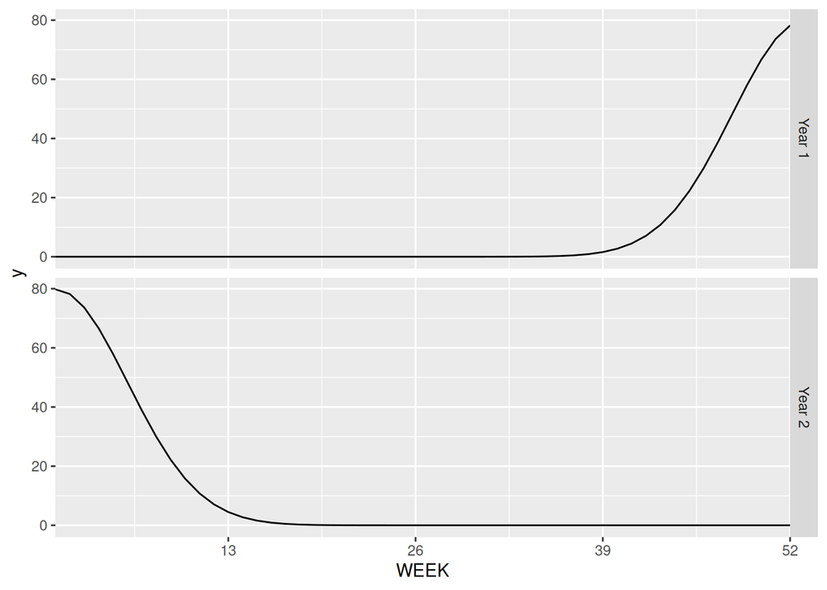

```r
co <- read_tsv("data/co_final.tsv") %>%
  left_join(., itz_co %>% select(-ITZ), by = c("COUNTRY"))


gen_inf_dens <- function(df, variable) {
  ndist <- data.frame(WEEK = 1:52)
  ndist$probability <- dnorm(x = ndist$WEEK, mean = mean(unlist(df[[variable]])), sd = sd(unlist(df[[variable]])))
  return(ndist)
}

# create sequence of weeks
x <- seq(-52, 51, by = 1)
# Choose the mean as 0 and standard deviation as 5
y <- dnorm(x, mean = 0, sd = 5)
y <- y * 1000

week_example <- tibble(x,y) %>%
  mutate(YEAR = if_else(x < 0, "Year 1", "Year 2")) %>%
  group_by(YEAR) %>%
  mutate(WEEK = seq_along(YEAR)) %>%
  ungroup()

t_example_plot <- ggplot(week_example, aes(WEEK,y)) +
  geom_line() +
  facet_grid(rows = vars(YEAR)) +
  scale_x_continuous(expand = c(0,0), breaks = c(13,26,39,52), limits = c(1,52))

t_example_plot
```

If our peak activity crosses over a transition the end result for probability density will place the density in the middle of the period:

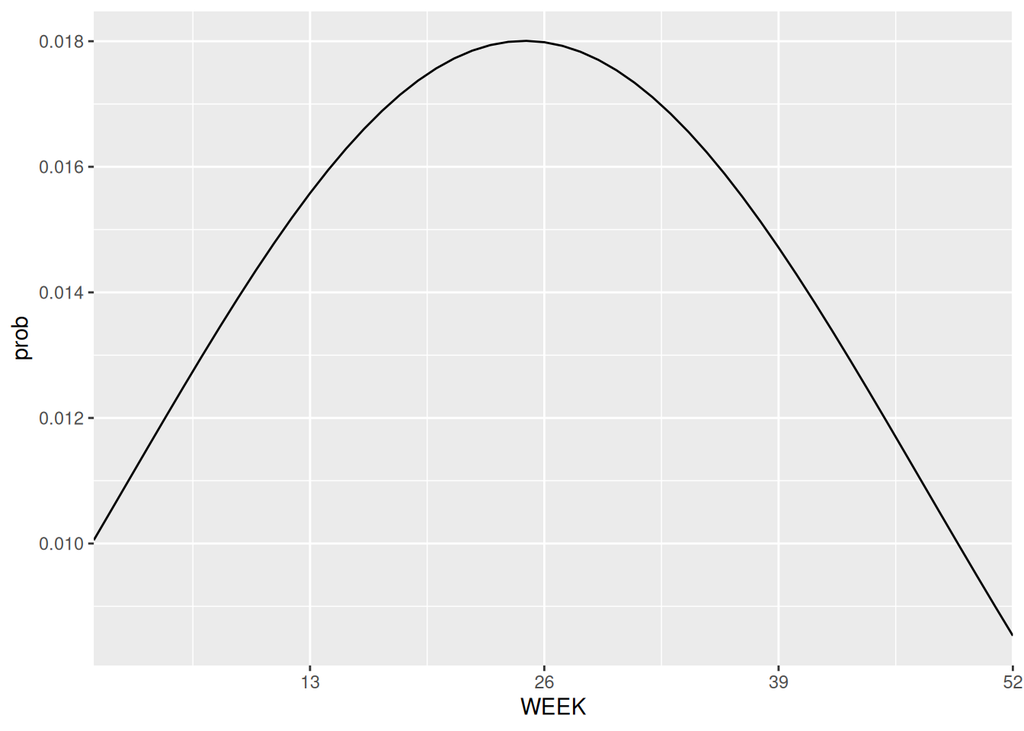

```r
week_example <- week_example %>%
  rowwise() %>%
  mutate(y_dist = list(rep(WEEK, round(y)))) %>%
  ungroup()

# create sequence of weeks
x_p <- seq(1, 52, by = 1)
# Choose the mean as 0 and standard deviation as 5
y_p <- dnorm(x_p, mean = mean(unlist(week_example$y_dist)), sd = sd(unlist(week_example$y_dist)))

week_prob <- tibble(WEEK = x_p, prob = y_p)

week_prob_plot <- ggplot(week_prob, aes(WEEK,prob)) +
  geom_line() +
  scale_x_continuous(expand = c(0,0), breaks = c(13,26,39,52), limits = c(1,52))

week_prob_plot
```

To correct for this issue we must assess what proper windows for data assessment should be.

A convenient way to break up the data to evaluate this is by northern hemisphere calendar quarters.

We then calculate which quarter has the maximum count density for each country across seasonal years, which start at week 52 of previous calendar year to week 51 of the defined seasonal year.

Example: seasonal year 2011 would start at calendar year 2010, week 52 (2010-12-27) and end on 2011, week 51 (2011-12-19).

Note this “seasonal year” (which shifts at week 52) is used only to classify each country’s `max_season` here; it is distinct from the “shifted year” (which shifts at week 30) introduced below, which is the week axis actually used for the Q4/Q1 (SY) clustering and GAM analysis later in the document.

The season that has the most occurrences of being identified as the maximum in yearly blocks is identified as the `max_season`. If two seasons have the same number of occurrences as maximums, the total sum of `INF_ALL` across that country’s season occurrences is used as a tie breaker with the maximum `INF_ALL` sum being taken as priority. If the sum of `INF_ALL` across seasons is the same, that country is filtered out, as this is a sign of poor quality data. Country season year blocks with zero counts or missing data for `INF_ALL` are dropped.

Using this process, a single year of a large volume of submitted data cannot throw off the overall pattern of seasonal density of submissions for a given country.

Season years 2011-2019 and 2024 were evaluated for the calculation of maximum seasonal activity for each country. Season years 2020-2023 are excluded throughout this analysis because the COVID-19 pandemic (lockdowns, travel restrictions, and disrupted surveillance) suppressed normal influenza circulation and reporting, making seasonal patterns from this period unrepresentative of typical influenza activity.

```r
countries_all_season_zero <- co %>%
  filter((season_year <= 2024 & season_year >= 2011) & season_year %notin% 2020:2023) %>%
  group_by(COUNTRY, COUNTRY_CODE) %>%
  summarise(inf_all_sum = sum(INF_ALL, na.rm = T)) %>%
  ungroup() %>%
  filter(inf_all_sum == 0) %>%
  mutate(max_season = NA_character_)


countries_dup_max_season <- co %>%
  filter((season_year <= 2024 & season_year >= 2011) & season_year %notin% 2020:2023) %>%
  group_by(COUNTRY, COUNTRY_CODE, season_year, season) %>%
  summarise(inf_all_season_sum = sum(INF_ALL, na.rm = T)) %>%
  ungroup() %>%
  group_by(COUNTRY, COUNTRY_CODE, season_year) %>%
  mutate(max_season = case_when(inf_all_season_sum == max(inf_all_season_sum) &
                                  inf_all_season_sum > 0 ~ season,
                                .default = NA_character_)) %>%
  ungroup() %>%
  filter(is.na(max_season) == F) %>%
  group_by(COUNTRY, COUNTRY_CODE, max_season) %>%
  mutate(num_season_occurences = length(max_season),
         inf_all_season_sum_total = sum(inf_all_season_sum)) %>%
  group_by(COUNTRY, COUNTRY_CODE) %>%
  # filter to season(s) with max occurrences of season year max
  filter(num_season_occurences == max(num_season_occurences)) %>%
  ungroup() %>%
  select(COUNTRY, COUNTRY_CODE, max_season, num_season_occurences, inf_all_season_sum_total) %>%
  distinct() %>%
  group_by(COUNTRY, COUNTRY_CODE) %>%
  # filter to max occurring season with the max count
  filter(inf_all_season_sum_total == max(inf_all_season_sum_total)) %>%
  # filter out countries with more than one max season if counts are tied
  # indicates poor data
  filter(length(max_season) > 1) %>%
  summarise(max_season = paste0(max_season, collapse = ", ")) %>%
  ungroup()

co_season_max <- co %>%
  filter((season_year <= 2024 & season_year >= 2011) & season_year %notin% 2020:2023) %>%
  group_by(COUNTRY, COUNTRY_CODE, season_year, season) %>%
  summarise(inf_all_season_sum = sum(INF_ALL, na.rm = T)) %>%
  ungroup() %>%
  group_by(COUNTRY, COUNTRY_CODE, season_year) %>%
  mutate(max_season = case_when(inf_all_season_sum == max(inf_all_season_sum) &
                                  inf_all_season_sum > 0 ~ season,
                                .default = NA_character_)) %>%
  ungroup() %>%
  filter(is.na(max_season) == F) %>%
  group_by(COUNTRY, COUNTRY_CODE, max_season) %>%
  mutate(num_season_occurences = length(max_season),
         inf_all_season_sum_total = sum(inf_all_season_sum)) %>%
  group_by(COUNTRY, COUNTRY_CODE) %>%
  # filter to season(s) with max occurrences of season year max
  filter(num_season_occurences == max(num_season_occurences)) %>%
  ungroup() %>%
  select(COUNTRY, COUNTRY_CODE, max_season, num_season_occurences, inf_all_season_sum_total) %>%
  distinct() %>%
  group_by(COUNTRY, COUNTRY_CODE) %>%
  # filter to max occurring season with the max count
  filter(inf_all_season_sum_total == max(inf_all_season_sum_total)) %>%
  # filter out countries with more than one max season if counts are tied
  # indicates poor data
  filter(length(max_season) < 2) %>%
  ungroup() %>%
  mutate(q_season = case_when(max_season == "Winter" ~ "Q1",
                              max_season == "Spring" ~ "Q2",
                              max_season == "Summer" ~ "Q3",
                              max_season == "Fall" ~ "Q4"),
         sy_cy = case_when(q_season == "Q1" | q_season == "Q4" ~ "SY",
                           q_season == "Q2" | q_season == "Q3" ~ "CY"))

co_season_results_summary <- bind_rows(
  countries_all_season_zero %>%
  mutate(max_season = NA_character_,
         num_season_occurences = NA_integer_,
         inf_all_season_sum_total = NA_real_,
         q_season = NA_character_,
         sy_cy = "Excluded: zero INF_ALL counts") %>%
  select(COUNTRY, COUNTRY_CODE, max_season, num_season_occurences,
         inf_all_season_sum_total, q_season, sy_cy),
  countries_dup_max_season %>%
    mutate(num_season_occurences = NA_integer_,
           inf_all_season_sum_total = NA_real_,
           q_season = NA_character_,
           sy_cy = "Excluded: more than one max season identified"),
  co_season_max
) %>%
  arrange(COUNTRY) %>%
  ungroup()

# Join data to co to create co_cat for data separation
co_cat <- co %>%
  left_join(co_season_results_summary, by = c("COUNTRY","COUNTRY_CODE")) %>%
  group_by(COUNTRY) %>%
  mutate(inf_all_relative = (INF_ALL/sum(INF_ALL, na.rm = T)) * (total_points * 10)) %>%
  ungroup() %>%
  rowwise() %>%
  mutate(inf_all_dist = if(is.na(inf_all_relative) | is.nan(inf_all_relative)) {
    list(NA)
  } else {
    list(rep(WEEK, round(inf_all_relative)))
  }) %>%
  ungroup()


# Seasonal summary table
season_tbl <- co_season_results_summary %>%
  select(sy_cy) %>%
  tbl_summary(statistic = all_categorical() ~ "{n} ({p}%)")

# Compute country overall max season, filter out countries with zero count maxes and
# countries that have more than one season max (indication of poor data)
co_cat2 <- co_cat %>%
  group_by(COUNTRY, season) %>%
  summarise(inf_all_rel_season = sum(inf_all_relative, na.rm = T)) %>%
  ungroup() %>%
  group_by(COUNTRY) %>%
  mutate(season_max = if_else(inf_all_rel_season == max(inf_all_rel_season), TRUE, FALSE),
         count_of_TRUE = sum(season_max == "TRUE")) %>%
  mutate(flag_zeromax = case_when(season_max == F ~ "Exclude: Insufficient for timing", T ~ "Include"),
         flag_GTonemax = case_when(max(count_of_TRUE) > 1 ~ "Exclude: more than 1 max, likely poor data",
                                   T ~ "Include"))


### Number of countries: this should be a dataframe with 1 row per country.
### include:
### - max_season -- which season had the max flu detections
### - flag_GTonemax -- which season had more than 1 Max season, which means that there is probably too little data to tell

n_countries <- co_cat2 %>% group_by(COUNTRY) %>% filter(flag_zeromax == "Include") %>% slice(1) %>%
  mutate(q_season = case_when(season == "Winter" ~ "Q1",
                                season == "Spring" ~ "Q2",
                                season == "Summer" ~ "Q3",
                                season == "Fall" ~ "Q4"),
         flag_maxseason = case_when(flag_GTonemax == "Include" ~ q_season, T ~ flag_GTonemax),
         nh_sh = case_when(flag_maxseason == "Exclude: more than 1 max, likely poor data" ~ "Exclude: more than 1 max, likely poor data",
                           q_season == "Q1" | q_season == "Q4" ~ "NH",
                           q_season == "Q2" | q_season == "Q3" ~ "SH"))

### Exclude countries with more than 1 peak or 0 peaks
co_season <- co_cat2 %>%
  filter(flag_zeromax == "Include") %>% #filter(season_max == T) %>%
  filter(flag_GTonemax == "Include") %>% #filter(length(season_max) <= 1 & inf_all_rel_season > 0) %>%
  ungroup() %>%
  rename(max_season = season)
```

First, let’s look **at countries that should be excluded for lack of data:**

How many countries should be excluded because they have more than 1 detection peak in the data (suggesting poor data)?

```r
season_tbl
```

| **Characteristic** | **N = 180**<sup>1</sup> |
| --- | --- |
| sy_cy |  |
| CY | 49 (27%) |
| Excluded: more than one max season identified | 1 (0.6%) |
| Excluded: zero INF_ALL counts | 4 (2.2%) |
| SY | 126 (70%) |

<sup>1</sup> n (%)

Once we exclude these countries with poor data, we use each countries’ maximum season to look at the overall count distribution.

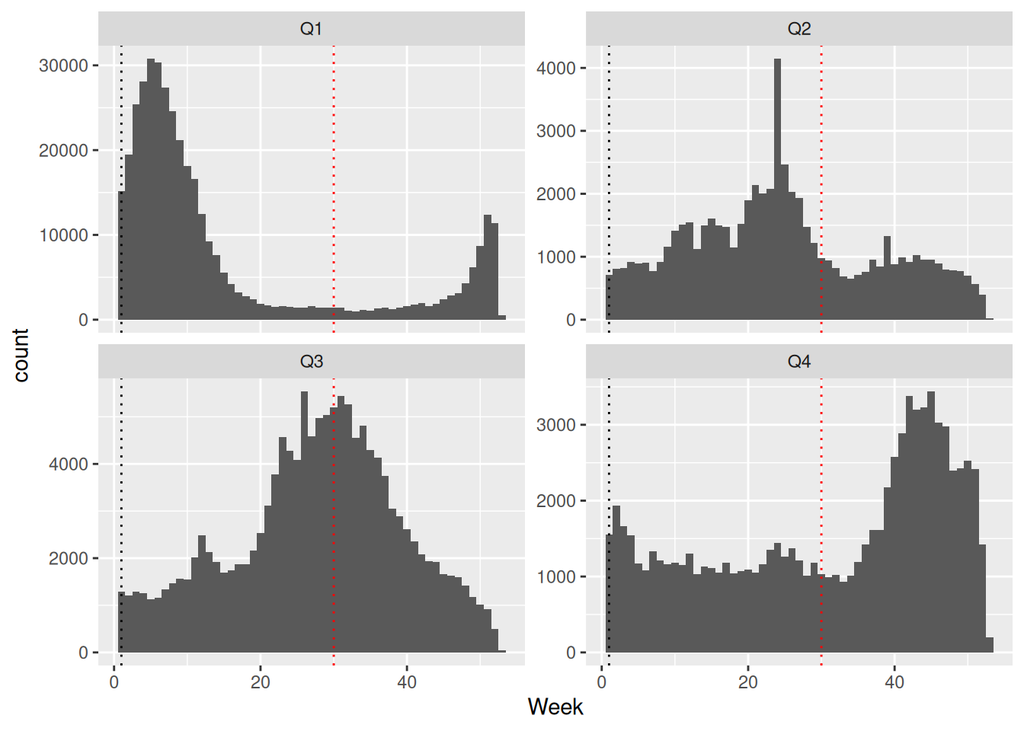

```r
# Unnest weekly distributions (inf_all_dist) for assessment by max season
co_by_season <- co_cat %>%
  filter((season_year <= 2024 & season_year >= 2011) & season_year %notin% 2020:2023) %>%
  dplyr::select(COUNTRY, max_season, sy_cy, inf_all_dist) %>%
  unnest() %>%
  mutate(max_quarter = case_when(max_season == "Winter" ~ "Q1",
                                 max_season == "Spring" ~ "Q2",
                                 max_season == "Summer" ~ "Q3",
                                 max_season == "Fall" ~ "Q4"),
         label = paste(COUNTRY, max_quarter, sy_cy, sep = "\n"))

# Create plot of count activity split by max season
peak_season_plot <- ggplot(co_by_season %>% filter(sy_cy %in% c("SY","CY")), aes(inf_all_dist)) +
  geom_histogram(binwidth = 1) +
  facet_wrap(~factor(max_quarter, levels=c("Q1", "Q2", "Q3", "Q4")),
             scales = "free_y") +
  geom_vline(xintercept = 1, color = "black", linetype = 3) +
  geom_vline(xintercept = 30, color = "red", linetype = 3) +
  xlab("Week")

peak_season_plot
```

The plots above show clear sampling density and peaks for countries with maximum densities in each quarter. Within the plots, the black line is the start of the calendar year (week 1) and the red line is the start of a “shifted-year” (week 30). We can see from the outputs that Q1 and Q4 max groups have peak densities cross the calendar year margin, whereas Q2 and Q3 group’s densities cross the shifted year margin. For more thorough verification we can look at individual country results as well.

```r
country_peak_season_plot <- ggplot(co_by_season, aes(inf_all_dist)) +
  geom_histogram(binwidth = 1) +
  facet_wrap_paginate(~label, scales = "free_y", ncol = 5, nrow = 5, page = 1) +
  geom_vline(xintercept = 1, color = "black", linetype = 3) +
  geom_vline(xintercept = 30, color = "red", linetype = 3) +
  xlab("Week")

c_num_pg <- n_pages(country_peak_season_plot)

pdf("plots/inf_all_country_dist.pdf", paper = "USr", width = 9)
for(i in 1:c_num_pg) {
  print(
    ggplot(co_by_season, aes(inf_all_dist)) +
      geom_histogram(binwidth = 1) +
      facet_wrap_paginate(~label, scales = "free_y", ncol = 5, nrow = 5, page = i) +
      geom_vline(xintercept = 1, color = "black", linetype = 3) +
      geom_vline(xintercept = 30, color = "red", linetype = 3) +
      xlab("Week")
  )
}
invisible(dev.off())
```

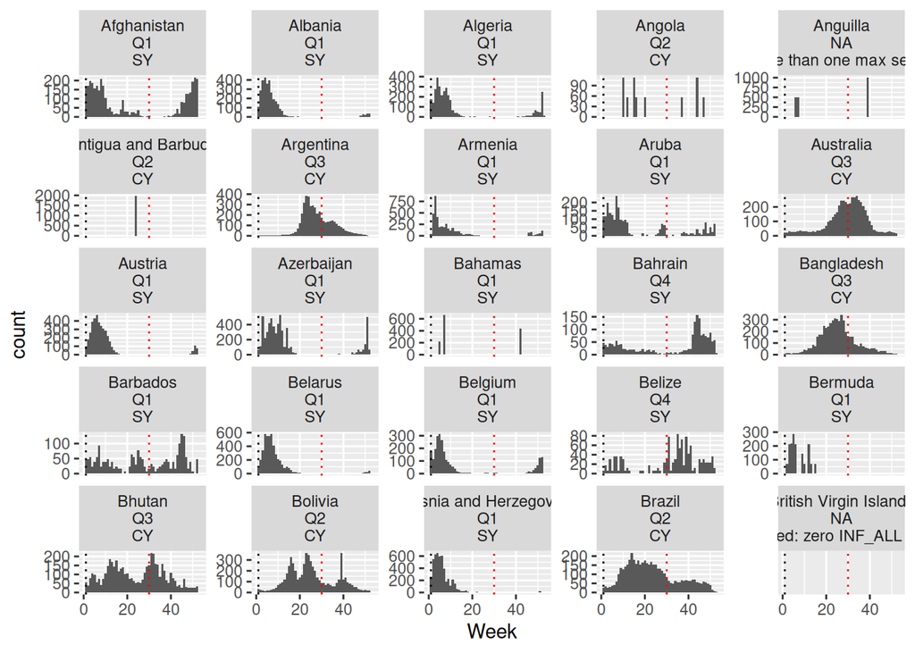

```r
country_peak_season_plot
```

```r
download_file(
  path = "plots/inf_all_country_dist.pdf",
  output_name = "inf_all_country_dist.pdf",
  button_label = "Download inf_all_country_dist.pdf",
  button_type = "danger",
  has_icon = TRUE,
  icon = "fa fa-save",
  self_contained = FALSE
)
```

Given these results, it appears sufficient to evaluate countries with max activity in Q4/Q1 with a shifted year (SY) and countries with max activity in Q2/Q3 with a calendar year (CY).

We will also filter initial data years to those that have greater than 40% coverage and ≥100 samples, then split into SY and CY categories.

```r
co_sy_0 <- co_cat %>% dplyr::select(-inf_all_dist) %>%
  filter(max_season %in% c("Fall", "Winter")) %>%
  filter(shifted_year %notin% 2019:2022) %>%
  mutate(flag_100detections = case_when(inf_all_s_yr_sum >= 100 ~ "Include",
                                        inf_all_s_yr_sum < 100 ~ "Exclude: <100 detections in time window"),
         xflag_100detections = ifelse(flag_100detections == "Include", 1, 0),
         flag_fewweeks = case_when(frac_s_yr_covered >= 0.4 ~ "Include",
                                   frac_s_yr_covered < 0.4 ~ "Exclude: <40% of weeks reported in time window"),
         xflag_fewweeks = ifelse(flag_fewweeks == "Include", 1, 0),
         flag_lowdata = case_when(inf_all_s_yr_sum >= 100 & frac_s_yr_covered >= 0.4 ~ "Include",
                                  T ~ "Exclude: <100 detections or <40% of weeks reported in time window"),
         xflag_lowdata = case_when(flag_lowdata == "Include" ~ 1,
                                   flag_lowdata == "Exclude: <100 detections or <40% of weeks reported in time window" ~ 0))

# Prepping data for Supplementary Table 1 to explain country inclusion/exclusion
co_sy_1 <- co_sy_0 %>%
  group_by(COUNTRY, shifted_year) %>%
  summarise(inf_all_s_yr_sum = min(inf_all_s_yr_sum),
            frac_s_yr_covered = min(frac_s_yr_covered)) %>%
  mutate(flag_100detections = case_when(inf_all_s_yr_sum >= 100 ~ "Include",
                                        inf_all_s_yr_sum < 100 ~ "Exclude: <100 detections in time window"),
         xflag_100detections = ifelse(flag_100detections == "Include", 1, 0),

         flag_fewweeks = case_when(frac_s_yr_covered >= 0.4 ~ "Include",
                                   frac_s_yr_covered < 0.4 ~ "Exclude: <40% of weeks reported in time window"),
         xflag_fewweeks = ifelse(flag_fewweeks == "Include", 1, 0),

         flag_lowdata = case_when(inf_all_s_yr_sum >= 100 & frac_s_yr_covered >= 0.4 ~ "Include",
                                  T ~ "Exclude: <100 detections or <40% of weeks reported in time window"),
         xflag_lowdata = case_when(flag_lowdata == "Include" ~ 1,
                                   flag_lowdata == "Exclude: <100 detections or <40% of weeks reported in time window" ~ 0)) %>%
  ungroup()

tbl_exclusions_sy <- co_sy_1 %>% group_by(COUNTRY) %>%
  summarise(flag_lowdata_sum = sum(xflag_lowdata),
            flag_100detections_sum = sum(xflag_100detections),
            flag_fewweeks_sum = sum(xflag_fewweeks)) %>%
  mutate(flag_lowdata = case_when(flag_lowdata_sum == 0 ~ "Exclude", T ~ "Include"),
         flag_100detections = case_when(flag_100detections_sum == 0 ~ "Exclude", T ~ "Include"),
         flag_fewweeks = case_when(flag_fewweeks_sum == 0 ~ "Exclude", T ~ "Include")) #%>%
  #  select(COUNTRY, flag_lowdata, flag_100detections, flag_fewweeks) %>%
  # left_join(., co_sy_1 %>% select(COUNTRY) %>% group_by(COUNTRY) %>% slice(1), by = c("COUNTRY")) # not clear the intention of this code line, as it doesn't change tbl_exclusions_sy df, comment out


co_sy <- co_sy_0 %>% filter(flag_lowdata == "Include")  ## excludes countries with insufficient data


co_cy_0 <- co_cat %>% dplyr::select(-inf_all_dist) %>%
  filter(max_season %in% c("Spring", "Summer")) %>%
  filter(YEAR %notin% 2020:2023) %>%
  #filter(inf_all_yr_sum > 100 & frac_yr_covered >= 0.4)
  mutate(flag_100detections = case_when(inf_all_yr_sum >= 100 ~ "Include",
                                        inf_all_yr_sum < 100 ~ "Exclude: <100 detections in time window"),
         xflag_100detections = ifelse(flag_100detections == "Include", 1, 0),

         flag_fewweeks = case_when(frac_yr_covered >= 0.4 ~ "Include",
                                   frac_yr_covered < 0.4 ~ "Exclude: <40% of weeks reported in time window"),
         xflag_fewweeks = ifelse(flag_fewweeks == "Include", 1, 0),

         flag_lowdata = case_when(inf_all_yr_sum >= 100 & frac_yr_covered >= 0.4 ~ "Include",
                                  T ~ "Exclude: <100 detections or <40% of weeks reported in time window"),
         xflag_lowdata = case_when(flag_lowdata == "Include" ~ 1,
                                   flag_lowdata == "Exclude: <100 detections or <40% of weeks reported in time window" ~ 0))

# Prepping data for Supplementary Table 1 to explain country inclusion/exclusion
co_cy_1 <- co_cy_0 %>%
  group_by(COUNTRY, YEAR) %>%
  summarise(inf_all_yr_sum = min(inf_all_yr_sum),
            frac_yr_covered = min(frac_yr_covered)) %>%
  mutate(flag_100detections = case_when(inf_all_yr_sum >= 100 ~ "Include",
                                        inf_all_yr_sum < 100 ~ "Exclude: <100 detections in time window"),
         xflag_100detections = ifelse(flag_100detections == "Include", 1, 0),

         flag_fewweeks = case_when(frac_yr_covered >= 0.4 ~ "Include",
                                   frac_yr_covered < 0.4 ~ "Exclude: <40% of weeks reported in time window"),
         xflag_fewweeks = ifelse(flag_fewweeks == "Include", 1, 0),

         flag_lowdata = case_when(inf_all_yr_sum >= 100 & frac_yr_covered >= 0.4 ~ "Include",
                                  T ~ "Exclude: <100 detections or <40% of weeks reported in time window"),
         xflag_lowdata = case_when(flag_lowdata == "Include" ~ 1,
                                   flag_lowdata == "Exclude: <100 detections or <40% of weeks reported in time window" ~ 0)) %>%
  ungroup()

tbl_exclusions_cy <- co_cy_1 %>% group_by(COUNTRY) %>%
  summarise(flag_lowdata_sum = sum(xflag_lowdata),
            flag_100detections_sum = sum(xflag_100detections),
            flag_fewweeks_sum = sum(xflag_fewweeks)) %>%
  mutate(flag_lowdata = case_when(flag_lowdata_sum == 0 ~ "Exclude", T ~ "Include"),
         flag_100detections = case_when(flag_100detections_sum == 0 ~ "Exclude", T ~ "Include"),
         flag_fewweeks = case_when(flag_fewweeks_sum == 0 ~ "Exclude", T ~ "Include")) #%>%
  #select(COUNTRY, flag_lowdata, flag_100detections, flag_fewweeks) %>%
  # left_join(., co_cy_1 %>% select(COUNTRY) %>% group_by(COUNTRY) %>% slice(1), by = c("COUNTRY")) # not clear the intention of this code line, as it doesn't change tbl_exclusions_sy df, comment out


co_cy <- co_cy_0 %>% filter(flag_lowdata == "Include") ## excludes  countries with insufficient data


tbl_exclusions <- bind_rows(tbl_exclusions_cy, tbl_exclusions_sy)
```

Countries filtered out of analysis (for having <100 detections in all years and <40% of weeks reported across all years):

```r
tbl_exclusions %>%
  select(-COUNTRY) %>%
  tbl_summary(statistic = all_categorical() ~ "{n} ({p}%)")
```

| **Characteristic** | **N = 175**<sup>1</sup> |
| --- | --- |
| flag_lowdata_sum | 8.0 (3.0, 10.0) |
| flag_100detections_sum | 8.0 (3.0, 10.0) |
| flag_fewweeks_sum | 10.0 (6.0, 11.0) |
| flag_lowdata |  |
| Exclude | 24 (14%) |
| Include | 151 (86%) |
| flag_100detections |  |
| Exclude | 23 (13%) |
| Include | 152 (87%) |
| flag_fewweeks |  |
| Exclude | 5 (2.9%) |
| Include | 170 (97%) |

<sup>1</sup> Median (Q1, Q3); n (%)

### 2.1 Extra Section Assessing Country Inclusion With Just Pre-Pandemic Data

```r
co_sy_pre <- co_cat %>% dplyr::select(-inf_all_dist) %>%
  filter(max_season %in% c("Fall", "Winter")) %>%
  filter(shifted_year < 2019) %>%
  mutate(flag_100detections = case_when(inf_all_s_yr_sum >= 100 ~ "Include",
                                        inf_all_s_yr_sum < 100 ~ "Exclude: <100 detections in time window"),
         xflag_100detections = ifelse(flag_100detections == "Include", 1, 0),
         flag_fewweeks = case_when(frac_s_yr_covered >= 0.4 ~ "Include",
                                   frac_s_yr_covered < 0.4 ~ "Exclude: <40% of weeks reported in time window"),
         xflag_fewweeks = ifelse(flag_fewweeks == "Include", 1, 0),
         flag_lowdata = case_when(inf_all_s_yr_sum >= 100 & frac_s_yr_covered >= 0.4 ~ "Include",
                                  T ~ "Exclude: <100 detections or <40% of weeks reported in time window"),
         xflag_lowdata = case_when(flag_lowdata == "Include" ~ 1,
                                   flag_lowdata == "Exclude: <100 detections or <40% of weeks reported in time window" ~ 0))

# Prepping data for Supplementary Table 1 to explain country inclusion/exclusion
co_sy_pre_1 <- co_sy_pre %>%
  group_by(COUNTRY, shifted_year) %>%
  summarise(inf_all_s_yr_sum = min(inf_all_s_yr_sum),
            frac_s_yr_covered = min(frac_s_yr_covered)) %>%
  mutate(flag_100detections = case_when(inf_all_s_yr_sum >= 100 ~ "Include",
                                        inf_all_s_yr_sum < 100 ~ "Exclude: <100 detections in time window"),
         xflag_100detections = ifelse(flag_100detections == "Include", 1, 0),

         flag_fewweeks = case_when(frac_s_yr_covered >= 0.4 ~ "Include",
                                   frac_s_yr_covered < 0.4 ~ "Exclude: <40% of weeks reported in time window"),
         xflag_fewweeks = ifelse(flag_fewweeks == "Include", 1, 0),

         flag_lowdata = case_when(inf_all_s_yr_sum >= 100 & frac_s_yr_covered >= 0.4 ~ "Include",
                                  T ~ "Exclude: <100 detections or <40% of weeks reported in time window"),
         xflag_lowdata = case_when(flag_lowdata == "Include" ~ 1,
                                   flag_lowdata == "Exclude: <100 detections or <40% of weeks reported in time window" ~ 0)) %>%
  ungroup()

tbl_exclusions_sy_pre <- co_sy_pre_1 %>% group_by(COUNTRY) %>%
  summarise(flag_lowdata_sum = sum(xflag_lowdata),
            flag_100detections_sum = sum(xflag_100detections),
            flag_fewweeks_sum = sum(xflag_fewweeks)) %>%
  mutate(flag_lowdata = case_when(flag_lowdata_sum == 0 ~ "Exclude", T ~ "Include"),
         flag_100detections = case_when(flag_100detections_sum == 0 ~ "Exclude", T ~ "Include"),
         flag_fewweeks = case_when(flag_fewweeks_sum == 0 ~ "Exclude", T ~ "Include"))

co_sy_pre_f <- co_sy_pre %>% filter(flag_lowdata == "Include")  ## excludes countries with insufficient data

co_cy_pre <- co_cat %>% dplyr::select(-inf_all_dist) %>%
  filter(max_season %in% c("Spring", "Summer")) %>%
  filter(YEAR < 2020) %>%
  #filter(inf_all_yr_sum > 100 & frac_yr_covered >= 0.4)
  mutate(flag_100detections = case_when(inf_all_yr_sum >= 100 ~ "Include",
                                        inf_all_yr_sum < 100 ~ "Exclude: <100 detections in time window"),
         xflag_100detections = ifelse(flag_100detections == "Include", 1, 0),

         flag_fewweeks = case_when(frac_yr_covered >= 0.4 ~ "Include",
                                   frac_yr_covered < 0.4 ~ "Exclude: <40% of weeks reported in time window"),
         xflag_fewweeks = ifelse(flag_fewweeks == "Include", 1, 0),

         flag_lowdata = case_when(inf_all_yr_sum >= 100 & frac_yr_covered >= 0.4 ~ "Include",
                                  T ~ "Exclude: <100 detections or <40% of weeks reported in time window"),
         xflag_lowdata = case_when(flag_lowdata == "Include" ~ 1,
                                   flag_lowdata == "Exclude: <100 detections or <40% of weeks reported in time window" ~ 0))

# Prepping data for Supplementary Table 1 to explain country inclusion/exclusion
co_cy_pre_1 <- co_cy_pre %>%
  group_by(COUNTRY, YEAR) %>%
  summarise(inf_all_yr_sum = min(inf_all_yr_sum),
            frac_yr_covered = min(frac_yr_covered)) %>%
  mutate(flag_100detections = case_when(inf_all_yr_sum >= 100 ~ "Include",
                                        inf_all_yr_sum < 100 ~ "Exclude: <100 detections in time window"),
         xflag_100detections = ifelse(flag_100detections == "Include", 1, 0),

         flag_fewweeks = case_when(frac_yr_covered >= 0.4 ~ "Include",
                                   frac_yr_covered < 0.4 ~ "Exclude: <40% of weeks reported in time window"),
         xflag_fewweeks = ifelse(flag_fewweeks == "Include", 1, 0),

         flag_lowdata = case_when(inf_all_yr_sum >= 100 & frac_yr_covered >= 0.4 ~ "Include",
                                  T ~ "Exclude: <100 detections or <40% of weeks reported in time window"),
         xflag_lowdata = case_when(flag_lowdata == "Include" ~ 1,
                                   flag_lowdata == "Exclude: <100 detections or <40% of weeks reported in time window" ~ 0)) %>%
  ungroup()

tbl_exclusions_cy_pre <- co_cy_pre_1 %>% group_by(COUNTRY) %>%
  summarise(flag_lowdata_sum = sum(xflag_lowdata),
            flag_100detections_sum = sum(xflag_100detections),
            flag_fewweeks_sum = sum(xflag_fewweeks)) %>%
  mutate(flag_lowdata = case_when(flag_lowdata_sum == 0 ~ "Exclude", T ~ "Include"),
         flag_100detections = case_when(flag_100detections_sum == 0 ~ "Exclude", T ~ "Include"),
         flag_fewweeks = case_when(flag_fewweeks_sum == 0 ~ "Exclude", T ~ "Include")) #%>%
  #select(COUNTRY, flag_lowdata, flag_100detections, flag_fewweeks) %>%
  # left_join(., co_cy_1 %>% select(COUNTRY) %>% group_by(COUNTRY) %>% slice(1), by = c("COUNTRY")) # not clear the intention of this code line, as it doesn't change tbl_exclusions_sy df, comment out


co_cy_pre_f <- co_cy_pre %>% filter(flag_lowdata == "Include") ## excludes  countries with insufficient data


tbl_exclusions_pre <- bind_rows(tbl_exclusions_cy_pre, tbl_exclusions_sy_pre)

tbl_exclusions_pre %>%
  select(-COUNTRY) %>%
  tbl_summary(statistic = all_categorical() ~ "{n} ({p}%)")
```

| **Characteristic** | **N = 175**<sup>1</sup> |
| --- | --- |
| flag_lowdata_sum | 7.00 (2.00, 9.00) |
| flag_100detections_sum | 7.00 (2.00, 9.00) |
| flag_fewweeks_sum | 9.00 (4.00, 9.00) |
| flag_lowdata |  |
| Exclude | 32 (18%) |
| Include | 143 (82%) |
| flag_100detections |  |
| Exclude | 31 (18%) |
| Include | 144 (82%) |
| flag_fewweeks |  |
| Exclude | 18 (10%) |
| Include | 157 (90%) |

<sup>1</sup> Median (Q1, Q3); n (%)

```r
# Find list of countries that have a minimum number of specified years
# and maximize the number of countries included
find_max_year <- function(data, year_field = "YEAR", min_years = 5) {
  data_tbl <- as_tibble(table(data %>%
                                  filter(points_in_data_year >= 52) %>%
                                  group_by(COUNTRY_CODE, !!sym(year_field)) %>%
                                  summarise() %>%
                                  ungroup())) %>%
    pivot_wider(id_cols = COUNTRY_CODE, names_from = !!sym(year_field), values_from = n)

  data_tbl <- data_tbl %>% rowwise() %>%
    mutate(total = sum(c_across(matches("^\\d")))) %>%
    ungroup()

  data_tbl <- data_tbl %>% filter(total >= min_years)

  data_tbl_mat <- data_tbl %>% dplyr::select(matches("^\\d"))
  row.names(data_tbl_mat) <- data_tbl$COUNTRY_CODE

  years <- apply(data_tbl_mat, 2, sum)
  max_year <- names(which.max(years))

  out_list <- list()
  out_list[["max_year"]] <- max_year

  out_list[["max_year_countries"]] <- row.names(data_tbl_mat %>% filter(!!sym(max_year) > 0))

  return(out_list)
}

co_cy_pre_f <- co_cy_pre_f %>%
  group_by(COUNTRY, YEAR) %>%
  mutate(points_in_data_year = length(WEEK)) %>%
  ungroup()

co_sy_pre_f <- co_sy_pre_f %>%
  group_by(COUNTRY, shifted_year) %>%
  mutate(points_in_data_year = length(shifted_week)) %>%
  ungroup()

co_cy_pre_max_year <- find_max_year(co_cy_pre_f, min_years = 5)
co_sy_pre_max_year <- find_max_year(co_sy_pre_f, min_years = 5, year_field = "shifted_year")

print(length(c(co_cy_pre_max_year$max_year_countries, co_sy_pre_max_year$max_year_countries)))
```

```
## [1] 104
```

If we used the pre-pandemic data we would lose 7 countries from the final analysis (6.3% of data).

## 3. Generation of Windowed Generalized Additive Model (`mgcv::gam`)

For each continuous run of weeks within a country (a “country period”, see `data_group` below, which restarts whenever a country has a gap of more than one calendar/shifted year with no qualifying data), we fit a univariate GAM of the form

$$\log(E[Y_t]) = \beta_0 +
f(t)$$

where $Y_t$ is the weekly count (`INF_ALL`) at date $t$ (`SDATE`) and $f(t)$ is a smooth function of calendar date. In code, every model fit in this section has the form:

```r
gam(INF_ALL ~ s(as.numeric(SDATE), k = <knots>, m = <penalty order>),
    family = poisson(link = "log"), method = "REML",
    na.action = na.omit, data = <country_period_data>)
```

**Family**: a Poisson family with log link was used initially, matching the count nature of the outcome; the identical model is refit below with a negative binomial family (`mgcv::nb()`) and the two are compared with AIC/BIC/dispersion diagnostics, since surveillance counts are frequently overdispersed relative to Poisson.

**Spline basis**: `s()` uses `mgcv`’s default basis, a thin-plate regression spline (`bs = "tp"`). This was chosen over a basis requiring manually-placed knots (e.g. `bs = "cr"`) because country periods vary widely in length (a few months up to 10 years), and the thin-plate basis lets `mgcv` place its eigenbasis optimally given only the basis dimension `k`, with no knot-location decisions needed.

For the GAM, for each country period, the knots parameter was calculated for the period data set as:

```
round(data_group_points/cy_periods)*2
# or
round(data_group_points/sy_periods)*2
```

**Penalty order (`m`)**: `m = 1` penalizes the first derivative (slope) of $f(t)$, rather than `mgcv`’s basis-specific default (second-derivative/ curvature) penalty. A first-derivative penalty was chosen because weeks at the very edge of a period are sometimes zero-padded rather than observed (see below); penalizing slope keeps the fitted curve from extrapolating with a new, steep trend right at those edges, instead flattening smoothly toward a constant level. For country periods where >= 20% of weeks are missing (`gam_m_na`), `m` is instead left at `mgcv`’s basis-specific default (`m = NA`) rather than fixed at 1, since there isn’t enough real signal in a sparse period to reliably estimate a specific first-derivative penalty.

**Smoothing-parameter selection**: `method = "REML"` is used throughout instead of `mgcv::gam()`’s default generalized cross-validation (`"GCV.Cp"`). REML is less prone to under-smoothing and gives more reliable, better-calibrated smoothing-parameter estimates than GCV, particularly for the shorter country periods common in this dataset (Wood 2011).

**Boundary zero-padding**: zero points are added at week 1 or >= week 52 of a period specifically where real data is missing there (not for interior gaps), since influenza activity is reliably near its seasonal minimum at the boundary between consecutive years in most countries. This anchors the smooth at the period’s edges instead of leaving it to extrapolate unconstrained from the nearest interior observation.

```r
# calculate blocks of data years for periods (for gam estimation passing)
co_data_years_cy <- co_cy %>%
  group_by(COUNTRY_CODE, YEAR) %>%
  summarise() %>%
  group_by(COUNTRY_CODE) %>%
  mutate(data_group = cumsum(c(1, diff(YEAR) > 1))) %>%
  ungroup()

# join back information into co_cy
co_cy <- co_cy %>%
  left_join(co_data_years_cy, by = c("COUNTRY_CODE","YEAR")) %>%
  group_by(COUNTRY_CODE, data_group) %>%
  mutate(data_group_key = seq_along(data_group),
         data_group_points = length(data_group),
         # variable used to determine m setting for gam, m is set to NA if > 20% of data is missing for the data group
         gam_m_na = if_else(sum(is.na(INF_ALL))/data_group_points > 0.20, TRUE, FALSE)) %>%
  ungroup() %>%
  group_by(COUNTRY_CODE, YEAR) %>%
  mutate(data_year_key = seq_along(YEAR)) %>%
  ungroup() %>%
  mutate(INF_ALL = case_when((WEEK >= 52 & is.na(INF_ALL)) |
                               (WEEK == 1 & is.na(INF_ALL)) ~ 0,
                             .default = INF_ALL),
         INF_A = case_when((WEEK >= 52 & is.na(INF_A)) |
                             (WEEK == 1 & is.na(INF_A)) ~ 0,
                           .default = INF_A),
         INF_B = case_when((WEEK >= 52 & is.na(INF_B)) |
                             (WEEK == 1 & is.na(INF_B)) ~ 0,
                           .default = INF_B))

# calculate the knots parameter by how many periods (52 weeks worth of time) of data there are
cy_periods <- round(length(unique(co_cy$SDATE))/52)

# create gam models for 3 testing variables (INF_ALL, INF_A, INF_B)
# use the data_group_points to calculate the knots parameter
inf_model_cy <- co_cy %>%
  group_by(COUNTRY, data_group) %>%
  nest() %>%
  mutate(inf_all_mdl = purrr::map(data, ~ gam(INF_ALL ~ s(as.numeric(SDATE),
                                                          k = round(.x$data_group_points[1]/cy_periods)*2,
                                                          m = ifelse(.x$gam_m_na[1], NA, 1)),
                                              family = poisson(link="log"),
                                              method = "REML",
                                              na.action=na.omit, data = .x)),
         inf_a_mdl = purrr::map(data, ~ gam(INF_A ~  s(as.numeric(SDATE),
                                                       k = round(.x$data_group_points[1]/cy_periods)*2,
                                                       m = ifelse(.x$gam_m_na[1], NA, 1)),
                                            family = poisson(link="log"),
                                            method = "REML",
                                            na.action=na.omit, data = .x)),
         inf_b_mdl = purrr::map(data, ~ gam(INF_B ~  s(as.numeric(SDATE),
                                                       k = round(.x$data_group_points[1]/cy_periods)*2,
                                                       m = ifelse(.x$gam_m_na[1], NA, 1)),
                                            family = poisson(link="log"),
                                            method = "REML",
                                            na.action=na.omit, data = .x))) %>%
  mutate(inf_all_pred = purrr::map2(inf_all_mdl, data, ~ predict(.x, .y, type = "response")),
         inf_a_pred = purrr::map2(inf_a_mdl, data, ~ predict(.x, .y, type = "response")),
         inf_b_pred = purrr::map2(inf_b_mdl, data, ~ predict(.x, .y, type = "response")))

inf_model_values_cy <- dplyr::select(inf_model_cy, -data, -inf_all_mdl, -inf_a_mdl, -inf_b_mdl) %>%
  unnest() %>%
  group_by(COUNTRY, data_group) %>%
  mutate(data_group_key = seq_along(data_group)) %>%
  ungroup()

# join results back onto data
co_cy <- co_cy %>%
  left_join(inf_model_values_cy, c("COUNTRY", "data_group", "data_group_key"))

# plot out results
g_color_scale <- c("Influenza all - GAM" = "black",
                   "Influenza all - Raw" = "black",
                   "Influenza A - GAM" = "blue",
                   "Influenza A - Raw" = "blue",
                   "Influenza B - GAM" = "orange",
                   "Influenza B - Raw" = "orange")

inf_gam_plot_cy <- co_cy %>%
  ggplot(aes(x=WEEK, group=YEAR)) +
  geom_line(size=0.5, alpha=0.8, aes(y = inf_all_pred, color = "Influenza all - GAM")) +
  geom_line(size=0.5, alpha=0.8, aes(y = inf_a_pred, color = "Influenza A - GAM")) +
  geom_line(size=0.5, alpha=0.8, aes(y = inf_b_pred, color = "Influenza B - GAM")) +
  geom_point(size=0.5, alpha=0.8, shape = 3, aes(y = INF_ALL, color = "Influenza all - Raw")) +
  geom_point(size=0.5, alpha=0.8, shape = 3, aes(y = INF_A, color = "Influenza A - Raw")) +
  geom_point(size=0.5, alpha=0.8, shape = 3, aes(y = INF_B, color = "Influenza B - Raw")) +
  scale_colour_manual(values = g_color_scale,
                      limits = names(g_color_scale)) +
  theme(legend.position = 'bottom') +
  facet_grid_paginate(COUNTRY ~ YEAR, nrow=5, ncol=10, page=1, scales = "free_y") +
  scale_x_continuous(expand = c(0,0), breaks = c(13,26,39,52), limits = c(0,53)) +
  ylab('Influenza number positive reported vs. GAM') +
  xlab('Week') +
  theme(axis.text=element_text(size=8),
        axis.title=element_text(size=11),
        plot.title=element_text(size=14, hjust=0.5)) +
  theme(panel.grid.major = element_blank(), panel.grid.minor = element_blank(),
        axis.line = element_line(colour = "black")) +
  guides(colour=guide_legend(ncol=3)) +
  labs(color = NULL)

num_pg_cy <- n_pages(inf_gam_plot_cy)

pdf("plots/inf_gam_vs_raw_cy.pdf", paper = "USr", width = 9)
for(i in 1:num_pg_cy) {
  print(
    co_cy %>%
    ggplot(aes(x=WEEK, group=YEAR)) +
    geom_line(size=0.5, alpha=0.8, aes(y = inf_all_pred, color = "Influenza all - GAM")) +
    geom_line(size=0.5, alpha=0.8, aes(y = inf_a_pred, color = "Influenza A - GAM")) +
    geom_line(size=0.5, alpha=0.8, aes(y = inf_b_pred, color = "Influenza B - GAM")) +
    geom_point(size=0.5, alpha=0.8, shape = 3, aes(y = INF_ALL, color = "Influenza all - Raw")) +
    geom_point(size=0.5, alpha=0.8, shape = 3, aes(y = INF_A, color = "Influenza A - Raw")) +
    geom_point(size=0.5, alpha=0.8, shape = 3, aes(y = INF_B, color = "Influenza B - Raw")) +
    scale_colour_manual(values = g_color_scale,
                        limits = names(g_color_scale)) +
    theme(legend.position = 'bottom') +
    facet_grid_paginate(COUNTRY ~ YEAR, nrow=5, ncol=10, page=i, scales = "free_y") +
    scale_x_continuous(expand = c(0,0), breaks = c(13,26,39,52), limits = c(0,53)) +
    ylab('Influenza number positive reported vs. GAM') +
    xlab('Week') +
    theme(axis.text=element_text(size=8),
          axis.title=element_text(size=11),
          plot.title=element_text(size=14, hjust=0.5)) +
    theme(panel.grid.major = element_blank(), panel.grid.minor = element_blank(),
          axis.line = element_line(colour = "black")) +
    guides(colour=guide_legend(ncol=3)) +
    labs(color = NULL)
  )
}
invisible(dev.off())
```

To compare model families, we refit the same three response variables (`INF_ALL`, `INF_A`, `INF_B`) for the CY partition using a negative binomial family (`mgcv::nb()`) instead of Poisson, keeping the identical smoothing (`s()`), knot (`k`), and penalty (`m`) settings used for each country period above. The negative binomial family relaxes the Poisson assumption that the mean and variance of counts are equal, which can better accommodate overdispersed surveillance counts.

```r
# fit negative binomial equivalents of the CY poisson gams above (same knots/m settings per country period)
inf_model_cy <- inf_model_cy %>%
  mutate(inf_all_mdl_nb = purrr::map(data, ~ gam(INF_ALL ~ s(as.numeric(SDATE),
                                                             k = round(.x$data_group_points[1]/cy_periods)*2,
                                                             m = ifelse(.x$gam_m_na[1], NA, 1)),
                                                 family = nb(link="log"),
                                                 method = "REML",
                                                 na.action=na.omit, data = .x)),
         inf_a_mdl_nb = purrr::map(data, ~ gam(INF_A ~ s(as.numeric(SDATE),
                                                         k = round(.x$data_group_points[1]/cy_periods)*2,
                                                         m = ifelse(.x$gam_m_na[1], NA, 1)),
                                               family = nb(link="log"),
                                               method = "REML",
                                               na.action=na.omit, data = .x)),
         inf_b_mdl_nb = purrr::map(data, ~ gam(INF_B ~ s(as.numeric(SDATE),
                                                         k = round(.x$data_group_points[1]/cy_periods)*2,
                                                         m = ifelse(.x$gam_m_na[1], NA, 1)),
                                               family = nb(link="log"),
                                               method = "REML",
                                               na.action=na.omit, data = .x))) %>%
  mutate(inf_all_pred_nb = purrr::map2(inf_all_mdl_nb, data, ~ predict(.x, .y, type = "response")),
         inf_a_pred_nb = purrr::map2(inf_a_mdl_nb, data, ~ predict(.x, .y, type = "response")),
         inf_b_pred_nb = purrr::map2(inf_b_mdl_nb, data, ~ predict(.x, .y, type = "response")))

inf_model_values_cy_nb <- dplyr::select(inf_model_cy, COUNTRY, data_group,
                                        inf_all_pred_nb, inf_a_pred_nb, inf_b_pred_nb) %>%
  unnest() %>%
  group_by(COUNTRY, data_group) %>%
  mutate(data_group_key = seq_along(data_group)) %>%
  ungroup()

# join negative binomial predictions back onto data
co_cy <- co_cy %>%
  left_join(inf_model_values_cy_nb, c("COUNTRY", "data_group", "data_group_key"))
```

```r
# plot out INF_ALL poisson vs. negative binomial gam fits against raw data
g_family_color_scale <- c("Influenza all - Raw" = "grey50",
                          "Influenza all - Poisson GAM" = "black",
                          "Influenza all - Negative Binomial GAM" = "red")

inf_gam_family_plot_cy <- co_cy %>%
  ggplot(aes(x=WEEK, group=YEAR)) +
  geom_point(size=0.5, alpha=0.8, shape = 3, aes(y = INF_ALL, color = "Influenza all - Raw")) +
  geom_line(size=0.5, alpha=0.8, aes(y = inf_all_pred, color = "Influenza all - Poisson GAM")) +
  geom_line(size=0.5, alpha=0.8, aes(y = inf_all_pred_nb, color = "Influenza all - Negative Binomial GAM")) +
  scale_colour_manual(values = g_family_color_scale,
                      limits = names(g_family_color_scale)) +
  theme(legend.position = 'bottom') +
  facet_grid_paginate(COUNTRY ~ YEAR, nrow=5, ncol=10, page=1, scales = "free_y") +
  scale_x_continuous(expand = c(0,0), breaks = c(13,26,39,52), limits = c(0,53)) +
  ylab('Influenza all number positive reported vs. GAM') +
  xlab('Week') +
  theme(axis.text=element_text(size=8),
        axis.title=element_text(size=11),
        plot.title=element_text(size=14, hjust=0.5)) +
  theme(panel.grid.major = element_blank(), panel.grid.minor = element_blank(),
        axis.line = element_line(colour = "black")) +
  guides(colour=guide_legend(ncol=3)) +
  labs(color = NULL)

num_pg_family_cy <- n_pages(inf_gam_family_plot_cy)

pdf("plots/inf_all_gam_family_vs_raw_cy.pdf", paper = "USr", width = 9)
for(i in 1:num_pg_family_cy) {
  print(
    co_cy %>%
      ggplot(aes(x=WEEK, group=YEAR)) +
      geom_point(size=0.5, alpha=0.8, shape = 3, aes(y = INF_ALL, color = "Influenza all - Raw")) +
      geom_line(size=0.5, alpha=0.8, aes(y = inf_all_pred, color = "Influenza all - Poisson GAM")) +
      geom_line(size=0.5, alpha=0.8, aes(y = inf_all_pred_nb, color = "Influenza all - Negative Binomial GAM")) +
      scale_colour_manual(values = g_family_color_scale,
                          limits = names(g_family_color_scale)) +
      theme(legend.position = 'bottom') +
      facet_grid_paginate(COUNTRY ~ YEAR, nrow=5, ncol=10, page=i, scales = "free_y") +
      scale_x_continuous(expand = c(0,0), breaks = c(13,26,39,52), limits = c(0,53)) +
      ylab('Influenza all number positive reported vs. GAM') +
      xlab('Week') +
      theme(axis.text=element_text(size=8),
            axis.title=element_text(size=11),
            plot.title=element_text(size=14, hjust=0.5)) +
      theme(panel.grid.major = element_blank(), panel.grid.minor = element_blank(),
            axis.line = element_line(colour = "black")) +
      guides(colour=guide_legend(ncol=3)) +
      labs(color = NULL)
  )
}
invisible(dev.off())
```

```r
# calculate blocks of data years for periods (for gam estimation passing)
co_data_years_sy <- co_sy %>%
  group_by(COUNTRY_CODE, shifted_year) %>%
  summarise() %>%
  group_by(COUNTRY_CODE) %>%
  mutate(data_group = cumsum(c(1, diff(shifted_year) > 1))) %>%
  ungroup()

# join back information into co_sy
co_sy <- co_sy %>%
  left_join(co_data_years_sy, by = c("COUNTRY_CODE","shifted_year")) %>%
  group_by(COUNTRY_CODE, data_group) %>%
  mutate(data_group_key = seq_along(data_group),
         data_group_points = length(data_group),
         # variable used to determine m setting for gam, m is set to NA if > 20% of data is missing for the data group
         gam_m_na = if_else(sum(is.na(INF_ALL))/data_group_points > 0.20, TRUE, FALSE)) %>%
  ungroup() %>%
  group_by(COUNTRY_CODE, shifted_year) %>%
  mutate(data_year_key = seq_along(shifted_year)) %>%
  ungroup()  %>%
  mutate(INF_ALL = case_when((shifted_week >= 52 & is.na(INF_ALL)) |
                               (shifted_week == 1 & is.na(INF_ALL)) ~ 0,
                             .default = INF_ALL),
         INF_A = case_when((shifted_week >= 52 & is.na(INF_A)) |
                             (shifted_week == 1 & is.na(INF_A)) ~ 0,
                           .default = INF_A),
         INF_B = case_when((shifted_week >= 52 & is.na(INF_B)) |
                             (shifted_week == 1 & is.na(INF_B)) ~ 0,
                           .default = INF_B))

# calculate the knots parameter by how many periods (52 weeks worth of time) of data there are
sy_periods <- round(length(unique(co_sy$SDATE))/52)

# create gam models for 3 testing variables (INF_ALL, INF_A, INF_B)
# use the data_group_points to calculate the knots parameter
inf_model_sy <- co_sy %>%
  group_by(COUNTRY, data_group) %>%
  nest() %>%
  mutate(inf_all_mdl = purrr::map(data, ~ gam(INF_ALL ~ s(as.numeric(SDATE),
                                                          k = round(.x$data_group_points[1]/sy_periods)*2,
                                                          m = ifelse(.x$gam_m_na[1],
                                                                     NA, 1)),
                                              family = poisson(link="log"),
                                              method = "REML",
                                              na.action=na.omit, data = .x)),
         inf_a_mdl = purrr::map(data, ~ gam(INF_A ~ s(as.numeric(SDATE),
                                                      k = round(.x$data_group_points[1]/sy_periods)*2,
                                                      m = ifelse(.x$gam_m_na[1],
                                                                 NA, 1)),
                                            family = poisson(link="log"),
                                            method = "REML",
                                            na.action=na.omit, data = .x)),
         inf_b_mdl = purrr::map(data, ~ gam(INF_B ~  s(as.numeric(SDATE),
                                                       k = round(.x$data_group_points[1]/sy_periods)*2,
                                                       m = ifelse(.x$gam_m_na[1],
                                                                  NA, 1)),
                                            family = poisson(link="log"),
                                            method = "REML",
                                            na.action=na.omit, data = .x))) %>%
  mutate(inf_all_pred = purrr::map2(inf_all_mdl, data, ~ predict(.x, .y, type = "response")),
         inf_a_pred = purrr::map2(inf_a_mdl, data, ~ predict(.x, .y, type = "response")),
         inf_b_pred = purrr::map2(inf_b_mdl, data, ~ predict(.x, .y, type = "response")))

inf_model_values_sy <- dplyr::select(inf_model_sy, -data, -inf_all_mdl, -inf_a_mdl, -inf_b_mdl) %>%
  unnest() %>%
  group_by(COUNTRY, data_group) %>%
  mutate(data_group_key = seq_along(data_group)) %>%
  ungroup()

# join results back onto data
co_sy <- co_sy %>%
  left_join(inf_model_values_sy, c("COUNTRY", "data_group", "data_group_key")) %>%
  mutate(season_name = case_when(shifted_year == 2010 ~ "2011",
                                 shifted_year == 2011 ~ "2011-2012",
                                 shifted_year == 2012 ~ "2012-2013",
                                 shifted_year == 2013 ~ "2013-2014",
                                 shifted_year == 2014 ~ "2014-2015",
                                 shifted_year == 2015 ~ "2015-2016",
                                 shifted_year == 2016 ~ "2016-2017",
                                 shifted_year == 2017 ~ "2017-2018",
                                 shifted_year == 2018 ~ "2018-2019",
                                 shifted_year == 2023 ~ "2023-2024",
                                 shifted_year == 2024 ~ "2024"))

# plot out results
g_color_scale <- c("Influenza all - GAM" = "black",
                   "Influenza all - Raw" = "black",
                   "Influenza A - GAM" = "blue",
                   "Influenza A - Raw" = "blue",
                   "Influenza B - GAM" = "orange",
                   "Influenza B - Raw" = "orange")

inf_gam_plot_sy <- co_sy %>%
  ggplot(aes(x=shifted_week, group=season_name)) +
  geom_line(size=0.5, alpha=0.8, aes(y = inf_all_pred, color = "Influenza all - GAM")) +
  geom_line(size=0.5, alpha=0.8, aes(y = inf_a_pred, color = "Influenza A - GAM")) +
  geom_line(size=0.5, alpha=0.8, aes(y = inf_b_pred, color = "Influenza B - GAM")) +
  geom_point(size=0.5, alpha=0.8, shape = 3, aes(y = INF_ALL, color = "Influenza all - Raw")) +
  geom_point(size=0.5, alpha=0.8, shape = 3, aes(y = INF_A, color = "Influenza A - Raw")) +
  geom_point(size=0.5, alpha=0.8, shape = 3, aes(y = INF_B, color = "Influenza B - Raw")) +
  scale_colour_manual(values = g_color_scale,
                      limits = names(g_color_scale)) +
  theme(legend.position = 'bottom') +
  facet_grid_paginate(COUNTRY ~ season_name, nrow=5, ncol=11, page=1, scales = "free_y") +
  scale_x_continuous(expand = c(0,0), breaks = c(13,26,39,52), limits = c(0,53)) +
  ylab('Influenza number positive reported vs. GAM') +
  xlab('Shifted week') +
  theme(axis.text=element_text(size=8),
        axis.title=element_text(size=11),
        plot.title=element_text(size=14, hjust=0.5)) +
  theme(panel.grid.major = element_blank(), panel.grid.minor = element_blank(),
        axis.line = element_line(colour = "black")) +
  guides(colour=guide_legend(ncol=3)) +
  labs(color = NULL)

num_pg_sy <- n_pages(inf_gam_plot_sy)

pdf("plots/inf_gam_vs_raw_sy.pdf", paper = "USr", width = 9)
for(i in 1:num_pg_sy) {
  print(
    co_sy %>%
      ggplot(aes(x=shifted_week, group=season_name)) +
      geom_line(size=0.5, alpha=0.8, aes(y = inf_all_pred, color = "Influenza all - GAM")) +
      geom_line(size=0.5, alpha=0.8, aes(y = inf_a_pred, color = "Influenza A - GAM")) +
      geom_line(size=0.5, alpha=0.8, aes(y = inf_b_pred, color = "Influenza B - GAM")) +
      geom_point(size=0.5, alpha=0.8, shape = 3, aes(y = INF_ALL, color = "Influenza all - Raw")) +
      geom_point(size=0.5, alpha=0.8, shape = 3, aes(y = INF_A, color = "Influenza A - Raw")) +
      geom_point(size=0.5, alpha=0.8, shape = 3, aes(y = INF_B, color = "Influenza B - Raw")) +
      scale_colour_manual(values = g_color_scale,
                          limits = names(g_color_scale)) +
      theme(legend.position = 'bottom') +
      facet_grid_paginate(COUNTRY ~ season_name, nrow=5, ncol=11, page=i, scales = "free_y") +
      scale_x_continuous(expand = c(0,0), breaks = c(13,26,39,52), limits = c(0,53)) +
      ylab('Influenza number positive reported vs. GAM') +
      xlab('Shifted week') +
      theme(axis.text=element_text(size=8),
            axis.title=element_text(size=11),
            plot.title=element_text(size=14, hjust=0.5)) +
      theme(panel.grid.major = element_blank(), panel.grid.minor = element_blank(),
            axis.line = element_line(colour = "black")) +
      guides(colour=guide_legend(ncol=3)) +
      labs(color = NULL)
  )
}
invisible(dev.off())
```

We repeat the same negative binomial refitting for the SY partition.

```r
# fit negative binomial equivalents of the SY poisson gams above (same knots/m settings per country period)
inf_model_sy <- inf_model_sy %>%
  mutate(inf_all_mdl_nb = purrr::map(data, ~ gam(INF_ALL ~ s(as.numeric(SDATE),
                                                             k = round(.x$data_group_points[1]/sy_periods)*2,
                                                             m = ifelse(.x$gam_m_na[1],
                                                                        NA, 1)),
                                                 family = nb(link="log"),
                                                 method = "REML",
                                                 na.action=na.omit, data = .x)),
         inf_a_mdl_nb = purrr::map(data, ~ gam(INF_A ~ s(as.numeric(SDATE),
                                                         k = round(.x$data_group_points[1]/sy_periods)*2,
                                                         m = ifelse(.x$gam_m_na[1],
                                                                    NA, 1)),
                                               family = nb(link="log"),
                                               method = "REML",
                                               na.action=na.omit, data = .x)),
         inf_b_mdl_nb = purrr::map(data, ~ gam(INF_B ~ s(as.numeric(SDATE),
                                                         k = round(.x$data_group_points[1]/sy_periods)*2,
                                                         m = ifelse(.x$gam_m_na[1],
                                                                    NA, 1)),
                                               family = nb(link="log"),
                                               method = "REML",
                                               na.action=na.omit, data = .x))) %>%
  mutate(inf_all_pred_nb = purrr::map2(inf_all_mdl_nb, data, ~ predict(.x, .y, type = "response")),
         inf_a_pred_nb = purrr::map2(inf_a_mdl_nb, data, ~ predict(.x, .y, type = "response")),
         inf_b_pred_nb = purrr::map2(inf_b_mdl_nb, data, ~ predict(.x, .y, type = "response")))

inf_model_values_sy_nb <- dplyr::select(inf_model_sy, COUNTRY, data_group,
                                        inf_all_pred_nb, inf_a_pred_nb, inf_b_pred_nb) %>%
  unnest() %>%
  group_by(COUNTRY, data_group) %>%
  mutate(data_group_key = seq_along(data_group)) %>%
  ungroup()

# join negative binomial predictions back onto data
co_sy <- co_sy %>%
  left_join(inf_model_values_sy_nb, c("COUNTRY", "data_group", "data_group_key"))
```

```r
# plot out INF_ALL poisson vs. negative binomial gam fits against raw data
inf_gam_family_plot_sy <- co_sy %>%
  ggplot(aes(x=shifted_week, group=season_name)) +
  geom_point(size=0.5, alpha=0.8, shape = 3, aes(y = INF_ALL, color = "Influenza all - Raw")) +
  geom_line(size=0.5, alpha=0.8, aes(y = inf_all_pred, color = "Influenza all - Poisson GAM")) +
  geom_line(size=0.5, alpha=0.8, aes(y = inf_all_pred_nb, color = "Influenza all - Negative Binomial GAM")) +
  scale_colour_manual(values = g_family_color_scale,
                      limits = names(g_family_color_scale)) +
  theme(legend.position = 'bottom') +
  facet_grid_paginate(COUNTRY ~ season_name, nrow=5, ncol=11, page=1, scales = "free_y") +
  scale_x_continuous(expand = c(0,0), breaks = c(13,26,39,52), limits = c(0,53)) +
  ylab('Influenza all number positive reported vs. GAM') +
  xlab('Shifted week') +
  theme(axis.text=element_text(size=8),
        axis.title=element_text(size=11),
        plot.title=element_text(size=14, hjust=0.5)) +
  theme(panel.grid.major = element_blank(), panel.grid.minor = element_blank(),
        axis.line = element_line(colour = "black")) +
  guides(colour=guide_legend(ncol=3)) +
  labs(color = NULL)

num_pg_family_sy <- n_pages(inf_gam_family_plot_sy)

pdf("plots/inf_all_gam_family_vs_raw_sy.pdf", paper = "USr", width = 9)
for(i in 1:num_pg_family_sy) {
  print(
    co_sy %>%
      ggplot(aes(x=shifted_week, group=season_name)) +
      geom_point(size=0.5, alpha=0.8, shape = 3, aes(y = INF_ALL, color = "Influenza all - Raw")) +
      geom_line(size=0.5, alpha=0.8, aes(y = inf_all_pred, color = "Influenza all - Poisson GAM")) +
      geom_line(size=0.5, alpha=0.8, aes(y = inf_all_pred_nb, color = "Influenza all - Negative Binomial GAM")) +
      scale_colour_manual(values = g_family_color_scale,
                          limits = names(g_family_color_scale)) +
      theme(legend.position = 'bottom') +
      facet_grid_paginate(COUNTRY ~ season_name, nrow=5, ncol=11, page=i, scales = "free_y") +
      scale_x_continuous(expand = c(0,0), breaks = c(13,26,39,52), limits = c(0,53)) +
      ylab('Influenza all number positive reported vs. GAM') +
      xlab('Shifted week') +
      theme(axis.text=element_text(size=8),
            axis.title=element_text(size=11),
            plot.title=element_text(size=14, hjust=0.5)) +
      theme(panel.grid.major = element_blank(), panel.grid.minor = element_blank(),
            axis.line = element_line(colour = "black")) +
      guides(colour=guide_legend(ncol=3)) +
      labs(color = NULL)
  )
}
invisible(dev.off())
```

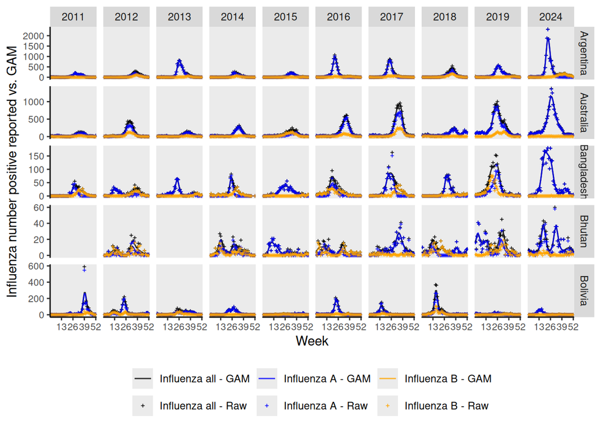

```r
inf_gam_plot_cy
```

```r
download_file(
  path = "plots/inf_gam_vs_raw_cy.pdf",
  output_name = "inf_gam_vs_raw_cy.pdf",
  button_label = "Download inf_gam_vs_raw_cy.pdf",
  button_type = "danger",
  has_icon = TRUE,
  icon = "fa fa-save",
  self_contained = FALSE
)
```

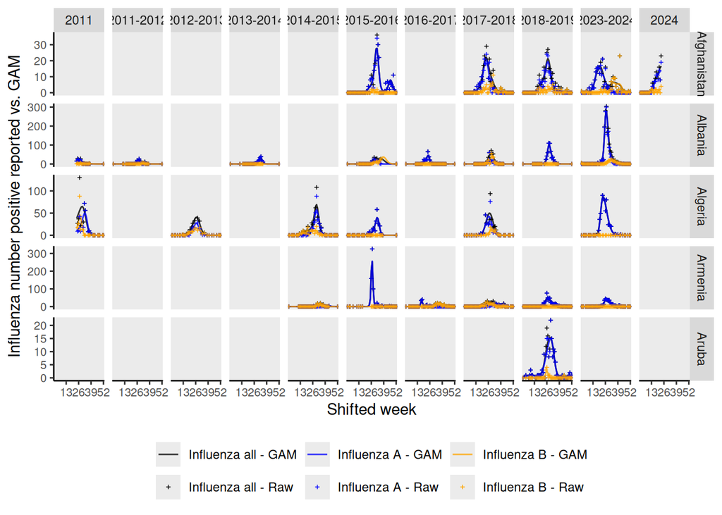

```r
inf_gam_plot_sy
```

```r
download_file(
  path = "plots/inf_gam_vs_raw_sy.pdf",
  output_name = "inf_gam_vs_raw_sy.pdf",
  button_label = "Download inf_gam_vs_raw_sy.pdf",
  button_type = "danger",
  has_icon = TRUE,
  icon = "fa fa-save",
  self_contained = FALSE
)
```

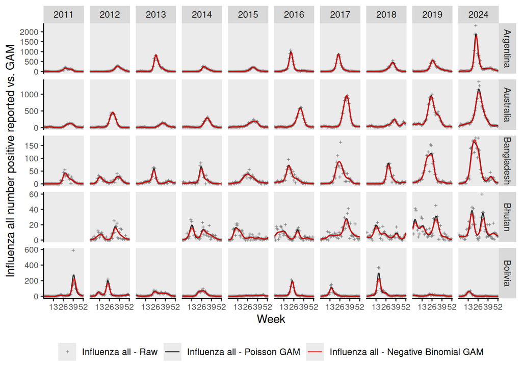

```r
inf_gam_family_plot_cy
```

```r
download_file(
  path = "plots/inf_all_gam_family_vs_raw_cy.pdf",
  output_name = "inf_all_gam_family_vs_raw_cy.pdf",
  button_label = "Download inf_all_gam_family_vs_raw_cy.pdf",
  button_type = "danger",
  has_icon = TRUE,
  icon = "fa fa-save",
  self_contained = FALSE
)
```

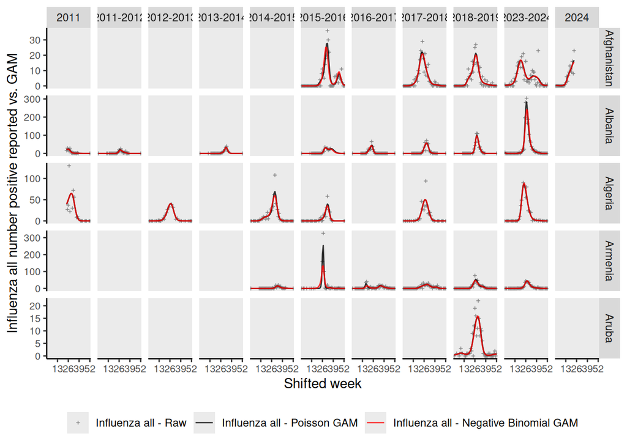

```r
inf_gam_family_plot_sy
```

```r
download_file(
  path = "plots/inf_all_gam_family_vs_raw_sy.pdf",
  output_name = "inf_all_gam_family_vs_raw_sy.pdf",
  button_label = "Download inf_all_gam_family_vs_raw_sy.pdf",
  button_type = "danger",
  has_icon = TRUE,
  icon = "fa fa-save",
  self_contained = FALSE
)
```

The GAM fits above visually track the raw weekly counts well for most country-periods; the diagnostics below assess whether a negative binomial family improves on this further.

To determine which family fits the data better, we compare the Poisson and negative binomial GAMs fit for each country period and response variable using AIC (lower is better). A difference of more than 2 AIC points ($\Delta AIC = AIC_{Poisson} - AIC_{NB}$) is taken as evidence favoring one family over the other; smaller differences are treated as equivalent.

```r
# safely extract AIC (returns NA if a model failed to fit or converge)
safe_aic <- function(mdl) {
  tryCatch(AIC(mdl), error = function(e) NA_real_)
}

gam_family_aic <- bind_rows(
  inf_model_cy %>%
    transmute(COUNTRY, data_group, partition = "CY",
              INF_ALL_poisson = purrr::map_dbl(inf_all_mdl, safe_aic),
              INF_ALL_nb      = purrr::map_dbl(inf_all_mdl_nb, safe_aic),
              INF_A_poisson   = purrr::map_dbl(inf_a_mdl, safe_aic),
              INF_A_nb        = purrr::map_dbl(inf_a_mdl_nb, safe_aic),
              INF_B_poisson   = purrr::map_dbl(inf_b_mdl, safe_aic),
              INF_B_nb        = purrr::map_dbl(inf_b_mdl_nb, safe_aic)),
  inf_model_sy %>%
    transmute(COUNTRY, data_group, partition = "SY",
              INF_ALL_poisson = purrr::map_dbl(inf_all_mdl, safe_aic),
              INF_ALL_nb      = purrr::map_dbl(inf_all_mdl_nb, safe_aic),
              INF_A_poisson   = purrr::map_dbl(inf_a_mdl, safe_aic),
              INF_A_nb        = purrr::map_dbl(inf_a_mdl_nb, safe_aic),
              INF_B_poisson   = purrr::map_dbl(inf_b_mdl, safe_aic),
              INF_B_nb        = purrr::map_dbl(inf_b_mdl_nb, safe_aic))
) %>%
  pivot_longer(cols = matches("_(poisson|nb)$"),
               names_to = c("variable","family"),
               names_pattern = "(INF_ALL|INF_A|INF_B)_(poisson|nb)",
               values_to = "aic") %>%
  pivot_wider(names_from = family, values_from = aic) %>%
  mutate(delta_aic = poisson - nb,
         preferred_family = case_when(is.na(delta_aic) ~ NA_character_,
                                      delta_aic > 2 ~ "Negative binomial",
                                      delta_aic < -2 ~ "Poisson",
                                      TRUE ~ "Equivalent"))

write_tsv(gam_family_aic, "data/gam_family_aic_comparison.tsv", na = "")
```

```r
gam_family_aic %>%
  filter(!is.na(preferred_family)) %>%
  select(COUNTRY, data_group, partition, variable, preferred_family) %>%
  arrange(partition, variable) %>%
  rename(Partition = partition, Variable = variable,
         "Preferred family (by AIC)" = preferred_family) %>%
  kable(format = "html") %>%
  kable_styling(bootstrap_options = c("striped", "hover", "condensed"), full_width = FALSE) %>%
  scroll_box(height = "400px")
```

| COUNTRY | data_group | Partition | Variable | Preferred family (by AIC) |
| --- | --- | --- | --- | --- |
| Argentina | 1 | CY | INF_A | Negative binomial |
| Argentina | 2 | CY | INF_A | Negative binomial |
| Australia | 1 | CY | INF_A | Negative binomial |
| Australia | 2 | CY | INF_A | Negative binomial |
| Bangladesh | 1 | CY | INF_A | Negative binomial |
| Bangladesh | 2 | CY | INF_A | Negative binomial |
| Bhutan | 1 | CY | INF_A | Negative binomial |
| Bhutan | 2 | CY | INF_A | Negative binomial |
| Bhutan | 3 | CY | INF_A | Negative binomial |
| Bolivia | 1 | CY | INF_A | Negative binomial |
| Bolivia | 2 | CY | INF_A | Equivalent |
| Brazil | 1 | CY | INF_A | Negative binomial |
| Brazil | 2 | CY | INF_A | Negative binomial |
| Brunei Darussalam | 1 | CY | INF_A | Poisson |
| Cambodia | 1 | CY | INF_A | Negative binomial |
| Cambodia | 2 | CY | INF_A | Poisson |
| Central African Republic | 1 | CY | INF_A | Equivalent |
| Central African Republic | 2 | CY | INF_A | Negative binomial |
| Chile | 1 | CY | INF_A | Negative binomial |
| Chile | 2 | CY | INF_A | Negative binomial |
| Colombia | 1 | CY | INF_A | Negative binomial |
| Colombia | 2 | CY | INF_A | Negative binomial |
| Cuba | 1 | CY | INF_A | Negative binomial |
| Cuba | 2 | CY | INF_A | Equivalent |
| Dominican Republic | 1 | CY | INF_A | Equivalent |
| Dominican Republic | 2 | CY | INF_A | Poisson |
| El Salvador | 1 | CY | INF_A | Equivalent |
| El Salvador | 2 | CY | INF_A | Poisson |
| El Salvador | 3 | CY | INF_A | Equivalent |
| Fiji | 1 | CY | INF_A | Negative binomial |

[output cut: 993 more lines]

AIC alone only reflects in-sample fit and can slightly favor the negative binomial simply because it has one extra free parameter (the dispersion, $\theta$), even when there is little real overdispersion in the data. To check this, we add three further diagnostics computed from the same already-fitted models: BIC (which penalizes that extra parameter more heavily), the fitted negative binomial $\theta$ itself (a very large $\theta$ means the negative binomial fit has effectively collapsed to the Poisson limit), and the Poisson Pearson dispersion statistic (values near 1 support Poisson; values well above 1 support negative binomial).

```r
# safely extract BIC (returns NA if a model failed to fit or converge)
safe_bic <- function(mdl) {
  tryCatch(BIC(mdl), error = function(e) NA_real_)
}

# safely extract the fitted negative binomial theta on its natural (non-log) scale
safe_nb_theta <- function(mdl) {
  tryCatch(mdl$family$getTheta(TRUE), error = function(e) NA_real_)
}

# safely compute the poisson pearson dispersion statistic (~1 supports poisson, >>1 supports negative binomial)
safe_dispersion <- function(mdl) {
  tryCatch(sum(residuals(mdl, type = "pearson")^2) / df.residual(mdl), error = function(e) NA_real_)
}

gam_family_diagnostics <- bind_rows(
  inf_model_cy %>%
    transmute(COUNTRY, data_group, partition = "CY",
              INF_ALL_bic_poisson = purrr::map_dbl(inf_all_mdl, safe_bic),
              INF_ALL_bic_nb = purrr::map_dbl(inf_all_mdl_nb, safe_bic),
              INF_ALL_theta_nb = purrr::map_dbl(inf_all_mdl_nb, safe_nb_theta),
              INF_ALL_dispersion_poisson = purrr::map_dbl(inf_all_mdl, safe_dispersion),
              INF_A_bic_poisson = purrr::map_dbl(inf_a_mdl, safe_bic),
              INF_A_bic_nb = purrr::map_dbl(inf_a_mdl_nb, safe_bic),
              INF_A_theta_nb = purrr::map_dbl(inf_a_mdl_nb, safe_nb_theta),
              INF_A_dispersion_poisson = purrr::map_dbl(inf_a_mdl, safe_dispersion),
              INF_B_bic_poisson = purrr::map_dbl(inf_b_mdl, safe_bic),
              INF_B_bic_nb = purrr::map_dbl(inf_b_mdl_nb, safe_bic),
              INF_B_theta_nb = purrr::map_dbl(inf_b_mdl_nb, safe_nb_theta),
              INF_B_dispersion_poisson = purrr::map_dbl(inf_b_mdl, safe_dispersion)),
  inf_model_sy %>%
    transmute(COUNTRY, data_group, partition = "SY",
              INF_ALL_bic_poisson = purrr::map_dbl(inf_all_mdl, safe_bic),
              INF_ALL_bic_nb = purrr::map_dbl(inf_all_mdl_nb, safe_bic),
              INF_ALL_theta_nb = purrr::map_dbl(inf_all_mdl_nb, safe_nb_theta),
              INF_ALL_dispersion_poisson = purrr::map_dbl(inf_all_mdl, safe_dispersion),
              INF_A_bic_poisson = purrr::map_dbl(inf_a_mdl, safe_bic),
              INF_A_bic_nb = purrr::map_dbl(inf_a_mdl_nb, safe_bic),
              INF_A_theta_nb = purrr::map_dbl(inf_a_mdl_nb, safe_nb_theta),
              INF_A_dispersion_poisson = purrr::map_dbl(inf_a_mdl, safe_dispersion),
              INF_B_bic_poisson = purrr::map_dbl(inf_b_mdl, safe_bic),
              INF_B_bic_nb = purrr::map_dbl(inf_b_mdl_nb, safe_bic),
              INF_B_theta_nb = purrr::map_dbl(inf_b_mdl_nb, safe_nb_theta),
              INF_B_dispersion_poisson = purrr::map_dbl(inf_b_mdl, safe_dispersion))
) %>%
  pivot_longer(cols = -c(COUNTRY, data_group, partition),
               names_to = c("variable", ".value"),
               names_pattern = "^(INF_ALL|INF_A|INF_B)_(bic_poisson|bic_nb|theta_nb|dispersion_poisson)$") %>%
  mutate(delta_bic = bic_poisson - bic_nb,
         bic_preferred_family = case_when(is.na(delta_bic) ~ NA_character_,
                                          delta_bic > 2 ~ "Negative binomial",
                                          delta_bic < -2 ~ "Poisson",
                                          TRUE ~ "Equivalent"))

write_tsv(gam_family_diagnostics, "data/gam_family_diagnostics.tsv", na = "")
```

```r
gam_family_diagnostics %>%
  filter(!is.na(bic_preferred_family)) %>%
  select(COUNTRY, data_group, partition, variable, bic_preferred_family) %>%
  arrange(partition, variable) %>%
  rename(Partition = partition, Variable = variable,
         "Preferred family (by BIC)" = bic_preferred_family) %>%
  kable(format = "html") %>%
  kable_styling(bootstrap_options = c("striped", "hover", "condensed"), full_width = FALSE) %>%
  scroll_box(height = "400px")
```

| COUNTRY | data_group | Partition | Variable | Preferred family (by BIC) |
| --- | --- | --- | --- | --- |
| Argentina | 1 | CY | INF_A | Negative binomial |
| Argentina | 2 | CY | INF_A | Negative binomial |
| Australia | 1 | CY | INF_A | Negative binomial |
| Australia | 2 | CY | INF_A | Negative binomial |
| Bangladesh | 1 | CY | INF_A | Negative binomial |
| Bangladesh | 2 | CY | INF_A | Negative binomial |
| Bhutan | 1 | CY | INF_A | Negative binomial |
| Bhutan | 2 | CY | INF_A | Negative binomial |
| Bhutan | 3 | CY | INF_A | Negative binomial |
| Bolivia | 1 | CY | INF_A | Negative binomial |
| Bolivia | 2 | CY | INF_A | Equivalent |
| Brazil | 1 | CY | INF_A | Negative binomial |
| Brazil | 2 | CY | INF_A | Negative binomial |
| Brunei Darussalam | 1 | CY | INF_A | Poisson |
| Cambodia | 1 | CY | INF_A | Negative binomial |
| Cambodia | 2 | CY | INF_A | Poisson |
| Central African Republic | 1 | CY | INF_A | Poisson |
| Central African Republic | 2 | CY | INF_A | Negative binomial |
| Chile | 1 | CY | INF_A | Negative binomial |
| Chile | 2 | CY | INF_A | Negative binomial |
| Colombia | 1 | CY | INF_A | Negative binomial |
| Colombia | 2 | CY | INF_A | Negative binomial |
| Cuba | 1 | CY | INF_A | Negative binomial |
| Cuba | 2 | CY | INF_A | Negative binomial |
| Dominican Republic | 1 | CY | INF_A | Equivalent |
| Dominican Republic | 2 | CY | INF_A | Poisson |
| El Salvador | 1 | CY | INF_A | Equivalent |
| El Salvador | 2 | CY | INF_A | Poisson |
| El Salvador | 3 | CY | INF_A | Equivalent |
| Fiji | 1 | CY | INF_A | Negative binomial |

[output cut: 993 more lines]

```r
gam_family_diagnostics %>%
  filter(!is.na(theta_nb)) %>%
  group_by(partition, variable) %>%
  summarise(median_theta = round(median(theta_nb), 1),
            pct_theta_gt50 = round(mean(theta_nb > 50) * 100, 1)) %>%
  ungroup() %>%
  rename(Partition = partition, Variable = variable,
         "Median fitted NB theta" = median_theta,
         "% country-periods with theta > 50" = pct_theta_gt50) %>%
  kable(format = "html") %>%
  kable_styling(bootstrap_options = c("striped", "hover", "condensed"), full_width = FALSE) %>%
  scroll_box(height = "400px")
```

| Partition | Variable | Median fitted NB theta | % country-periods with theta > 50 |
| --- | --- | --- | --- |
| CY | INF_A | 7.4 | 11.8 |
| CY | INF_ALL | 8.1 | 10.8 |
| CY | INF_B | 6.1 | 17.2 |
| SY | INF_A | 6.2 | 8.1 |
| SY | INF_ALL | 6.6 | 8.1 |
| SY | INF_B | 4.8 | 16.5 |

```r
gam_family_diagnostics %>%
  filter(!is.na(dispersion_poisson)) %>%
  group_by(partition, variable) %>%
  summarise(median_dispersion = round(median(dispersion_poisson), 2),
            pct_overdispersed = round(mean(dispersion_poisson > 1.5) * 100, 1)) %>%
  ungroup() %>%
  rename(Partition = partition, Variable = variable,
         "Median Pearson dispersion (Poisson)" = median_dispersion,
         "% country-periods with dispersion > 1.5" = pct_overdispersed) %>%
  kable(format = "html") %>%
  kable_styling(bootstrap_options = c("striped", "hover", "condensed"), full_width = FALSE) %>%
  scroll_box(height = "400px")
```

| Partition | Variable | Median Pearson dispersion (Poisson) | % country-periods with dispersion > 1.5 |
| --- | --- | --- | --- |
| CY | INF_A | 1.62 | 57.0 |
| CY | INF_ALL | 1.98 | 74.2 |
| CY | INF_B | 1.16 | 26.9 |
| SY | INF_A | 2.11 | 69.0 |
| SY | INF_ALL | 2.50 | 75.8 |
| SY | INF_B | 1.09 | 34.3 |

The analyses above confirm that the negative binomial model is slightly preferred, even though the model fits are nearly identical to the Poisson fitted distributions in most cases.

We will therefore use the negative binomial fitted values forwards for the subsequent analyses.

## 4. Burden calculations

The testing data across countries varies widely in its depth of coverage. It has been estimated globally that influenza infects between 5–10% of adults and 20–30% of children yearly (Fischer et al. 2014). These rates will vary per country but we can expect infection rates to be within the previously mentioned ranges.

With the current data, GAM curve estimations will be used to compute influenza burden for each yearly window (`inf_all_burden`):

$$inf\_all\_burden =
{inf\_all\_pred\_nb_{data\ period\ points} \over \sum
inf\_all\_pred\_nb_{data\ period\ points}}$$

```r
cal_y_sums <- co_cy %>%
  group_by(COUNTRY_CODE, YEAR) %>%
  summarise(sum_inf_all = sum(inf_all_pred_nb, na.rm = T), data_points = length(COUNTRY_CODE))

shifted_y_sums <- co_sy %>%
  group_by(COUNTRY_CODE, shifted_year) %>%
  summarise(sum_inf_all = sum(inf_all_pred_nb, na.rm = T), data_points = length(COUNTRY_CODE))

# calculate CY
co_cy <- co_cy %>%
  mutate(label = paste(COUNTRY, max_season, sep = "-")) %>%
  group_by(COUNTRY, YEAR) %>%
  mutate(points_in_data_year = length(WEEK)) %>%
  mutate(inf_all_burden = inf_all_pred_nb/sum(inf_all_pred_nb, na.rm = T) *
           (if_else(lubridate::leap_year(YEAR), points_in_data_year/53, points_in_data_year/52))) %>%
  ungroup()

# calculate sy
co_sy <- co_sy %>%
  mutate(label = paste(COUNTRY, max_season, sep = "-")) %>%
  group_by(COUNTRY, shifted_year) %>%
  mutate(points_in_data_year = length(shifted_week)) %>%
  mutate(inf_all_burden = inf_all_pred_nb/sum(inf_all_pred_nb, na.rm = T) *
           (if_else(lubridate::leap_year(shifted_year+1), points_in_data_year/53, points_in_data_year/52))) %>%
  ungroup()
```

We can then generate plots of the influenza burden for each country.

```r
# plot countries burdens (non filtered) to see results
burden_plot_cy <- co_cy %>%
  ggplot(aes(x=WEEK, y=inf_all_burden, group=YEAR)) +
  geom_line(aes(color=as.factor(YEAR))) +
  theme(legend.position = 'bottom') +
  facet_wrap_paginate(~label, nrow=5, ncol=5, page=1, scales = "free_y") +
  scale_x_continuous(expand = c(0,0), breaks = c(13,26,39,52), limits = c(0,53)) +
  ylab('Influenza burden of available years') +
  xlab('Week') +
  theme(axis.text=element_text(size=10),
        axis.title=element_text(size=11),
        plot.title=element_text(size=14, hjust=0.5)) +
  theme(panel.grid.major = element_blank(), panel.grid.minor = element_blank(),
        axis.line = element_line(colour = "black")) +
  guides(colour=guide_legend(title="Year", ncol=10))

b_num_pg_cy <- n_pages(burden_plot_cy)
pdf("plots/inf_all_burden_cy.pdf", paper = "USr", width = 9)
for(i in 1:b_num_pg_cy) {
  print(
    co_cy %>%
      ggplot(aes(x=WEEK, y=inf_all_burden, group=YEAR)) +
      geom_line(aes(color=as.factor(YEAR))) +
      theme(legend.position = 'bottom') +
      facet_wrap_paginate(~label, nrow=5, ncol=5, page=i, scales = "free_y") +
      scale_x_continuous(expand = c(0,0), breaks = c(13,26,39,52), limits = c(0,53)) +
      ylab('Influenza burden of available years') +
      xlab('Week') +
      theme(axis.text=element_text(size=10),
            axis.title=element_text(size=11),
            plot.title=element_text(size=14, hjust=0.5)) +
      theme(panel.grid.major = element_blank(), panel.grid.minor = element_blank(),
            axis.line = element_line(colour = "black")) +
      guides(colour=guide_legend(title="Year", ncol=10))
  )
}
invisible(dev.off())

burden_plot_sy <- co_sy %>%
      ggplot(aes(x=shifted_week, y=inf_all_burden, group=shifted_year)) +
      geom_line(aes(color=as.factor(shifted_year))) +
      theme(legend.position = 'bottom') +
      facet_wrap_paginate(~label, nrow=5, ncol=5, page=1, scales = "free_y") +
      scale_x_continuous(expand = c(0,0), breaks = c(13,26,39,52), limits = c(0,53)) +
      ylab('Influenza burden of available years') +
      xlab('Shifted Week') +
      theme(axis.text=element_text(size=10),
            axis.title=element_text(size=11),
            plot.title=element_text(size=14, hjust=0.5)) +
      theme(panel.grid.major = element_blank(), panel.grid.minor = element_blank(),
            axis.line = element_line(colour = "black")) +
      guides(colour=guide_legend(title="Shifted Year", ncol=10))

b_num_pg_sy <- n_pages(burden_plot_sy)
pdf("plots/inf_all_burden_sy.pdf", paper = "USr", width = 9)
for(i in 1:b_num_pg_sy) {
  print(
    co_sy %>%
      ggplot(aes(x=shifted_week, y=inf_all_burden, group=shifted_year)) +
      geom_line(aes(color=as.factor(shifted_year))) +
      theme(legend.position = 'bottom') +
      facet_wrap_paginate(~label, nrow=5, ncol=5, page=i, scales = "free_y") +
      scale_x_continuous(expand = c(0,0), breaks = c(13,26,39,52), limits = c(0,53)) +
      ylab('Influenza burden of available years') +
      xlab('Shifted Week') +
      theme(axis.text=element_text(size=10),
            axis.title=element_text(size=11),
            plot.title=element_text(size=14, hjust=0.5)) +
      theme(panel.grid.major = element_blank(), panel.grid.minor = element_blank(),
            axis.line = element_line(colour = "black")) +
      guides(colour=guide_legend(title="Shifted Year", ncol=10))
  )
}
invisible(dev.off())
```

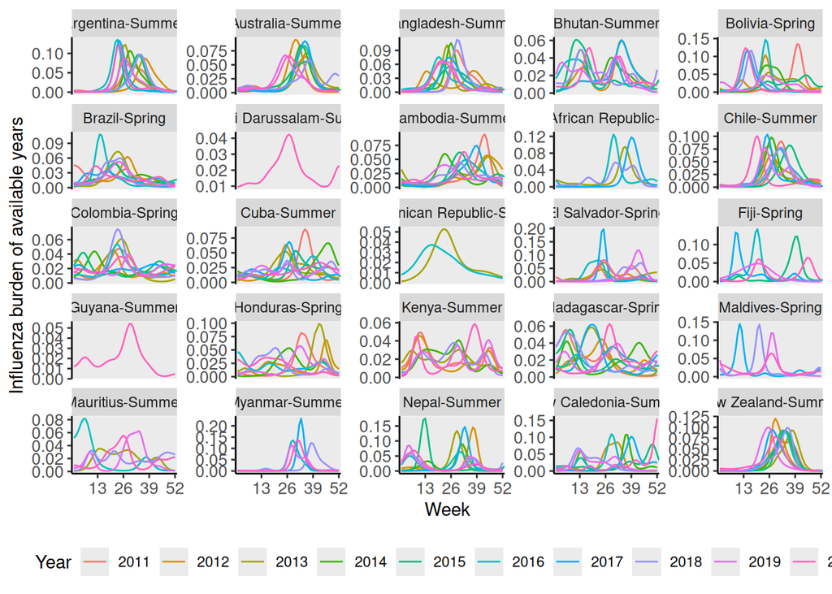

```r
burden_plot_cy
```

```r
download_file(
  path = "plots/inf_all_burden_cy.pdf",
  output_name = "inf_all_burden_cy.pdf",
  button_label = "Download inf_all_burden_cy.pdf",
  button_type = "danger",
  has_icon = TRUE,
  icon = "fa fa-save",
  self_contained = FALSE
)
```

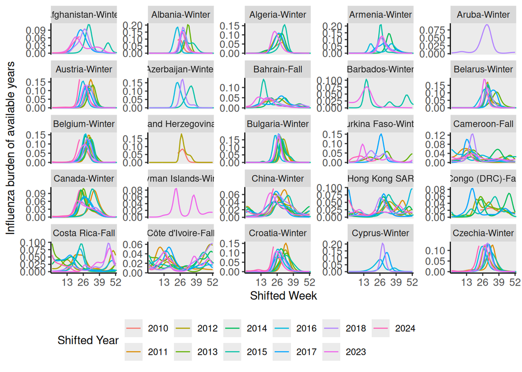

```r
burden_plot_sy
```

```r
download_file(
  path = "plots/inf_all_burden_sy.pdf",
  output_name = "inf_all_burden_sy.pdf",
  button_label = "Download inf_all_burden_sy.pdf",
  button_type = "danger",
  has_icon = TRUE,
  icon = "fa fa-save",
  self_contained = FALSE
)
```

## 5. Clustering

### 5.1 Split of Data By Years Covered

In order to get a sufficient comparison for the generation of time series clusters, **a minimum of 5 years of data is required** (>40% of the total period of data). Additionally, a minimum of at least one complete country to country window comparison was required (year or shifted year). This was done by finding the window with the maximum country representation and then filtering the dataset to countries within the maximum representation window.

Splitting of both the SY and CY data sets into `pass` and `hold` partitions based on the data requirement was completed. Countries within the `hold` partition with insufficient data for clustering, will be placed into generated draft clusters later.

```r
# Find list of countries that have a minimum number of specified years
# and maximize the number of countries included
find_max_year <- function(data, year_field = "YEAR", min_years = 5) {
  data_tbl <- as_tibble(table(data %>%
                                  filter(points_in_data_year >= 52) %>%
                                  group_by(COUNTRY_CODE, !!sym(year_field)) %>%
                                  summarise() %>%
                                  ungroup())) %>%
    pivot_wider(id_cols = COUNTRY_CODE, names_from = !!sym(year_field), values_from = n)

  data_tbl <- data_tbl %>% rowwise() %>%
    mutate(total = sum(c_across(matches("^\\d")))) %>%
    ungroup()

  data_tbl <- data_tbl %>% filter(total >= min_years)

  data_tbl_mat <- data_tbl %>% dplyr::select(matches("^\\d"))
  row.names(data_tbl_mat) <- data_tbl$COUNTRY_CODE

  years <- apply(data_tbl_mat, 2, sum)
  max_year <- names(which.max(years))

  out_list <- list()
  out_list[["max_year"]] <- max_year

  out_list[["max_year_countries"]] <- row.names(data_tbl_mat %>% filter(!!sym(max_year) > 0))

  return(out_list)
}

# Get CY set with max country inclusion
co_cy_set <- find_max_year(data = co_cy, year_field = "YEAR", min_years = 5)
# max year is 2019 includes:
# "ARG" "AUS" "BGD" "BOL" "BRA" "BTN" "CHL" "COL" "CUB" "FJI" "HND" "KEN"
# "KHM" "LKA" "MDG" "MMR" "MUS" "NCL" "NPL" "NZL" "PAN" "PER" "PHL" "PRY"
#" SLV" "THA" "UGA" "URY" "VNM" "ZAF" "ZMB"

# Split data into pass and hold partitions
co_cy_pass <- co_cy %>% filter(COUNTRY_CODE %in% co_cy_set$max_year_countries)
co_cy_hold <- co_cy %>% filter(COUNTRY_CODE %notin% co_cy_set$max_year_countries)

# Get CY set with max country inclusion
co_sy_set <- find_max_year(data = co_sy, year_field = "shifted_year", min_years = 5)
# max year is 2015 includes:
# "ALB" "ARM" "AUT" "BEL" "BGR" "BHR" "BLR" "CAN" "CHE" "CHN" "CIV" "CMR"
# "COD" "CRI" "CZE" "DEU" "DNK" "DZA" "ECU" "EGY" "ESP" "EST" "ETH" "FIN"
# "FRA" "GBR" "GEO" "GHA" "GRC" "GTM" "HKG" "HRV" "HUN" "IDN" "IND" "IRL"
# "IRN" "ISL" "ISR" "ITA" "JAM" "JOR" "JPN" "KAZ" "KGZ" "KOR" "LAO" "LBN"
# "LTU" "LUX" "LVA" "MAR" "MDA" "MEX" "MLT" "MNG" "MTQ" "MYS" "NIC" "NLD"
# "NOR" "OMN" "PAK" "POL" "PRT" "QAT" "ROU" "RUS" "SEN" "SGP" "SRB" "SVK"
# "SVN" "SWE" "TGO" "TUN" "TUR" "TZA" "UKR" "USA"

# Split data into pass and hold partitions
co_sy_pass <- co_sy %>% filter(COUNTRY_CODE %in% co_sy_set$max_year_countries)
co_sy_hold <- co_sy %>% filter(COUNTRY_CODE %notin% co_sy_set$max_year_countries)
```

Here is where we can summarize the number of countries that were included vs. excluded from analysis.

Countries excluded from the clustering analysis were those who had:

- <100 detections in all years and <40% of weeks reported across all time windows
- <5 years of data that were sufficient (at least 100 specimens per year and at least 40% of weeks reported on)

```r
library(gt)

### Number of years of data considered for analysis

n_yrs <- function(data, year_field = "YEAR") {
   data_tbl <- as_tibble(table(data %>%
                                  filter(points_in_data_year >= 52) %>%
                                  group_by(COUNTRY, !!sym(year_field)) %>%
                                  summarise() %>%
                                  ungroup())) %>%
    pivot_wider(id_cols = COUNTRY,
                names_from = !!sym(year_field),
                names_prefix = "year_",
                values_from = n)
  #
  # data_tbl <- data_tbl %>% rowwise() %>%
  #   mutate(total = sum(year_2011 , year_2012 , year_2013 , year_2014 , year_2015 , year_2016 , year_2017 , year_2018 ,
  #            year_2019 , year_2023 , year_2024, na.rm = T)) %>%
  #   ungroup()

  return(data_tbl)
}

# Also adding an indicator for whether the country was included in the "pass" for the comparison matrix...
#    A country was included in the "pass" if there was sufficient data for the year that the comparison matrix is based on:
#    CY: based on 2019 year
#    SY: based on the 2015 "shifted year"
n_yrs_cy <- n_yrs( data = co_cy, year_field = "YEAR") %>%
  rowwise() %>%
    mutate(total = sum(year_2011 , year_2012 , year_2013 , year_2014 , year_2015 , year_2016 , year_2017 , year_2018 ,
             year_2019 , year_2024, na.rm = T)) %>%
    ungroup() %>%
  mutate(matrix_pass = case_when(total >=5 & year_2019 == 1 ~ 1,
                                 total >=5 & year_2019 == 0 ~ 0,
                                 total <5 ~ 0))

n_yrs_sy <- n_yrs( data = co_sy, year_field = "shifted_year") %>%
    rowwise() %>%
    mutate(total = sum(year_2011 , year_2012 , year_2013 , year_2014 , year_2015 , year_2016 , year_2017 , year_2018 ,
                       year_2023, na.rm = T)) %>%
    ungroup() %>%
  mutate(matrix_pass = case_when(total >=5 & year_2015 == 1 ~ 1,
                                 total >=5 & year_2015 == 0 ~ 0,
                                 total <5 ~ 0))

n_yrs_overall <- bind_rows(n_yrs_cy, n_yrs_sy)


tbl_exclusions2 <- left_join(tbl_exclusions, n_yrs_overall %>% select(COUNTRY, total, matrix_pass), by = "COUNTRY") %>%
  mutate(flag_lt5yrs = case_when(total <5 | is.na(total) ~ "Exclude", # commented out below and restored this line: is.na(total) are countries that had no time windows meeting the >=100 detections and >=40% of weeks with detection data, so could not proceed to the GAM analysis. Some countries (e.g., Afghanistan) had partial windows that met this criteria (e.g., second half of 2024) but not enough complete windows (>=5), so fall out at this stage.
                                 #total <5 | flag_lowdata_sum <5 ~ "Exclude",
                                 T ~ "Include"),
         flag_matrixpass = case_when(matrix_pass == 1 ~ "Yes",
                                     total >=5 & matrix_pass == 0 ~ "No",
                                     flag_lt5yrs == "Exclude" ~ "Not applicable: too few time windows for analysis"),
         # sequential_flags = case_when(flag_lowdata == "Exclude" ~ "Too little data",
         #                            flag_lt5yrs == "Exclude" ~ "Too few years",
         #                            flag_matrixpass == "Exclude from matrix" ~ "No data for comparison matrix year",
         #                            T ~ "Include"),
         sequential_flags = case_when(#flag_lowdata == "Exclude" ~ "Too little data",
                                      flag_lt5yrs == "Exclude" ~ "Exclude: too few time windows",
                                      flag_matrixpass == "No" ~ "Exclude: no data for comparison matrix year",
                                      T ~ "Include"))

#write.csv(tbl_exclusions2, "C:/Users/ydi8/Desktop/temp_supptable1.csv")

# tbl_exclusions2 %>%
#   select(sequential_flags, flag_100detections, flag_fewweeks) %>% #, flag_matrixpass) %>%
#   tbl_summary(statistic = all_categorical() ~ "{n} ({p}%)",
#               label = list(
#     #flag_lowdata ~ "Too little data: <100 detections in all years or <40% of weeks with reports in all years",
#     flag_100detections ~ "<100 influenza detections in all years",
#     flag_fewweeks ~ "<40% of weeks had reported data across all years",
#     #flag_lt5yrs ~ "Fewer than 5 years with sufficient data",
#     #flag_matrixpass ~ "No data for year included in the comparison matrix",
#     sequential_flags ~ "Reasons for exclusion"
#   )) %>%
#   # Indent specific rows
#   modify_column_indent(
#     columns = label,
#     rows = variable %in% c("flag_100detections", "flag_fewweeks"), #, "flag_matrixpass"),
#     indent = 10L
#   ) %>%
#   as_gt() %>%
#   tab_style(
#     style = list(
#       cell_fill(color = "#FFFBC8")
#     ),
#     #locations = cells_body(rows = c(1, 6, 9, 12))
#     locations = cells_body(rows = c(1, 6, 9))
#   )


tbl_exclusions2 %>%
  select(sequential_flags) %>% #, flag_matrixpass) %>%
  tbl_summary(statistic = all_categorical() ~ "{n} ({p}%)",
              label = list(
    #flag_lowdata ~ "Too little data: <100 detections in all years or <40% of weeks with reports in all years",
    # flag_100detections ~ "<100 influenza detections in all years",
    # flag_fewweeks ~ "<40% of weeks had reported data across all years",
    #flag_lt5yrs ~ "Fewer than 5 years with sufficient data",
    #flag_matrixpass ~ "No data for year included in the comparison matrix",
    sequential_flags ~ "Reasons for exclusion"
  ))
```

| **Characteristic** | **N = 175**<sup>1</sup> |
| --- | --- |
| Reasons for exclusion |  |
| Exclude: no data for comparison matrix year | 1 (0.6%) |
| Exclude: too few time windows | 63 (36%) |
| Include | 111 (63%) |

<sup>1</sup> n (%)

### 5.2 Clustering and Weighting Functions

The following are functions used within clustering processes. Country boundary geometries used for mapping come from a WHO-provided shapefile (World Health Organization, n.d.-b).

```r
# Read in WHO shapefile and world map for downstream figures
# 1 ============================================================================
who_shp <- readRDS("data/who_shapefile.rds") %>%
  mutate(COUNTRY = case_when(
    CNTRY_TERR %in% unique(co$COUNTRY) ~ CNTRY_TERR,
    CNTRY_TERR == "Bolivia (Plurinational State of)" ~ "Bolivia",
    CNTRY_TERR == "Democratic Republic of the Congo" ~ "Congo (DRC)",
    CNTRY_TERR == "Czech Republic" ~ "Czechia",
    CNTRY_TERR == "Iran (Islamic Republic of)" ~ "Iran",
    CNTRY_TERR == "Lao People's Democratic Republic" ~ "Lao PDR",
    CNTRY_TERR == "Democratic People's Republic of Korea" ~ "North Korea",
    CNTRY_TERR == "The former Yugoslav Republic of Macedonia" ~ "North Macedonia",
    CNTRY_TERR == "West Bank and Gaza Strip" ~ "Palestine",
    CNTRY_TERR == "United Republic of Tanzania" ~ "Tanzania",
    CNTRY_TERR == "United Kingdom of Great Britain and Northern Ireland"~ "United Kingdom",
    CNTRY_TERR == "Venezuela (Bolivarian Republic of)" ~ "Venezuela",
    CNTRY_TERR == "San Marino" ~ "San Marino",
    CNTRY_TERR == "Puerto Rico" ~ "Puerto Rico",
    .default = NA_character_
  ))

# world map data
world_map <- map_data("world")

# check countries in series not in map data
countries_map_diff <-  unique(co$COUNTRY)[unique(co$COUNTRY) %notin% unique(world_map$region)]

# fix map data countries to match flunet data countries
world_map <- world_map %>%
  mutate(region = case_when(region == "China" & subregion == "Hong Kong" ~ "China, Hong Kong SAR",
                            region == "Democratic Republic of the Congo" ~ "Congo (DRC)",
                            region == "Ivory Coast" ~ "Côte d'Ivoire",
                            region == "Czech Republic" ~ "Czechia",
                            region == "Laos" ~ "Lao PDR",
                            region == "South Korea" ~ "Republic of Korea",
                            region == "Moldova" ~ "Republic of Moldova",
                            region == "Russia" ~ "Russian Federation",
                            region == "Tobago" | region == "Trinidad" ~ "Trinidad and Tobago",
                            #region == "Turkey" ~ "Türkiye",
                            region == "UK" ~ "United Kingdom",
                            #region == "Tanzania" ~ "United Republic of Tanzania",
                            region == "USA" ~ "United States of America",
                            region == "Vietnam" ~ "Viet Nam",
                            region == "Antigua" ~ "Antigua and Barbuda",
                            region == "Saint Barthelemy" ~ "Saint Barthélemy",
                            region == "Saint Kitts" ~ "Saint Kitts and Nevis",
                            region == "Saint Vincent" ~ "Saint Vincent and the Grenadines",
                            region == "Syrian" ~ "Syrian Arab Republic",
                            region == "Trinidad" ~ "Trinidad and Tobago",
                            region == "Virgin Islands" & subregion == " British" ~ "British Virgin Islands",
                            region == "Virgin Islands" & subregion == " US" ~ "US Virgin Islands",
                            TRUE ~ region))
# ============================================================================

## Data Preparation
# 2 ============================================================================

# Standardize column names based on dataset type
# COUNTRY_CODE (ISO3) is used as the clustering identifier throughout, since
# it's a stable key. COUNTRY is retained separately as a name lookup table.
standardize_columns <- function(raw_df, dataset_type) {
  year_col <- switch(dataset_type, "calendar" = "YEAR", "shifted" = "shifted_year",
                      stop("DATASET_TYPE must be 'calendar' or 'shifted'"))
  week_col <- switch(dataset_type, "calendar" = "WEEK", "shifted" = "shifted_week",
                      stop("DATASET_TYPE must be 'calendar' or 'shifted'"))

  required_cols <- c("COUNTRY", "COUNTRY_CODE", year_col, week_col, "inf_all_burden")
  missing_cols <- setdiff(required_cols, names(raw_df))
  if (length(missing_cols) > 0) stop("Missing expected columns in RAW_DF: ", paste(missing_cols, collapse = ", "))

  df <- raw_df %>%
    transmute(
      country      = COUNTRY_CODE,       # clustering identifier (ISO3)
      country_name = COUNTRY,            # retained for labeling
      year_col     = .data[[year_col]],
      week_col     = .data[[week_col]],
      value        = inf_all_burden
    )

  country_lookup <- df %>% distinct(country, country_name) %>% deframe()

  list(df = df, country_lookup = country_lookup)
}

# Build one WIDE matrix per year (rows = countries, cols = weeks)
build_year_matrices <- function(df) {
  years <- sort(unique(df$year_col))
  year_mats <- list()

  for (y in years) {
    wide <- df %>%
      filter(year_col == y) %>%
      select(country, week_col, value) %>%
      pivot_wider(names_from = week_col, values_from = value) %>%
      arrange(country)

    mat <- as.matrix(wide %>% select(-country))
    rownames(mat) <- wide$country

    complete_rows <- complete.cases(mat)
    if (!all(complete_rows)) {
      warning(sprintf("Year %s: dropping %d countries with incomplete weeks (unexpected given data design)",
                       y, sum(!complete_rows)))
      mat <- mat[complete_rows, , drop = FALSE]
    }

    n_weeks <- ncol(mat)
    year_mats[[as.character(y)]] <- list(
      matrix = mat, n_weeks = n_weeks, weight = n_weeks / WEEK_DENOM, countries = rownames(mat)
    )
  }
  year_mats
}
# ============================================================================

## Base Clustering and Validity Metrics (shared helper functions)
# 3 ============================================================================
run_single_clustering <- function(mat, k, algo) {
  d <- dist(mat, method = "euclidean")

  labels <- switch(algo,
    "kmeans"      = kmeans(mat, centers = k, nstart = 10, iter.max = 50)$cluster,
    "hclust_ward" = cutree(hclust(d, method = "ward.D2"), k = k),
    "hkmeans"     = factoextra::hkmeans(mat, k = k)$cluster,
    "pam"         = cluster::pam(d, k = k)$clustering,
    stop("Unknown algorithm: ", algo)
  )
  names(labels) <- rownames(mat)
  labels
}
```

```r
# Shared resampling logic: fixed-percentage subsample without replacement
draw_resample_indices <- function(n_year, resample_pct) {
  n_draw <- max(2, round(n_year * resample_pct))
  sample(seq_len(n_year), size = n_draw, replace = FALSE)
}

# Internal validity metrics (reused in ensemble diagnostics + k-selection)
compute_wss <- function(mat, labels) {
  sum(sapply(unique(labels), function(cl) {
    members <- mat[labels == cl, , drop = FALSE]
    if (nrow(members) < 2) return(0)
    center <- colMeans(members)
    sum(rowSums(sweep(members, 2, center)^2))
  }))
}

compute_calinski_harabasz <- function(mat, labels) {
  # CH = (between-cluster SS / (k-1)) / (within-cluster SS / (n-k)). Higher is better.
  n <- nrow(mat); k <- length(unique(labels))
  if (k < 2 || k >= n) return(NA)

  overall_center <- colMeans(mat)
  wss <- compute_wss(mat, labels)
  bss <- sum(sapply(unique(labels), function(cl) {
    members <- mat[labels == cl, , drop = FALSE]
    nrow(members) * sum((colMeans(members) - overall_center)^2)
  }))
  (bss / (k - 1)) / (wss / (n - k))
}

compute_dunn_index <- function(mat_or_dist, labels, is_dist = FALSE) {
  # Dunn = min inter-cluster distance / max intra-cluster diameter. Higher is better.
  d <- if (is_dist) as.matrix(mat_or_dist) else as.matrix(dist(mat_or_dist))
  clusters <- unique(labels)
  if (length(clusters) < 2) return(NA)

  inter_dists <- c()
  for (i in seq_along(clusters)) for (j in seq_along(clusters)) if (i < j) {
    idx_i <- which(labels == clusters[i]); idx_j <- which(labels == clusters[j])
    inter_dists <- c(inter_dists, min(d[idx_i, idx_j, drop = FALSE]))
  }
  intra_diams <- sapply(clusters, function(cl) {
    idx <- which(labels == cl)
    if (length(idx) < 2) return(0)
    max(d[idx, idx, drop = FALSE])
  })
  if (max(intra_diams) == 0) return(NA)
  min(inter_dists) / max(intra_diams)
}

compute_jaccard_similarity <- function(set1, set2) {
  uni <- length(union(set1, set2))
  if (uni == 0) return(NA)
  length(intersect(set1, set2)) / uni
}

# Verifies that a freshly-assigned names() vector is actually a reordering-safe
# match to its source names
.verify_name_alignment <- function(source_names_before_overwrite, expected_names, context = "") {
  if (length(source_names_before_overwrite) != length(expected_names)) {
    stop(sprintf("Name alignment check failed (%s): length mismatch (%d vs %d)",
                  context, length(source_names_before_overwrite), length(expected_names)))
  }
  if (!is.null(source_names_before_overwrite) &&
      !identical(as.character(source_names_before_overwrite), as.character(expected_names))) {
    stop(sprintf(
      "Name alignment check failed (%s): the function's own output names do not match the expected country order.\nThis means names(labels) <- ... would have silently MISALIGNED labels to the wrong countries.\nFirst few mismatches -- got: %s | expected: %s",
      context,
      paste(head(source_names_before_overwrite, 5), collapse = ", "),
      paste(head(expected_names, 5), collapse = ", ")
    ))
  }
  invisible(TRUE)
}


# Simple Adjusted Rand Index
compute_ari <- function(labels1, labels2) {
  common <- intersect(names(labels1), names(labels2))
  n <- length(common)

  if (n < 2) {
    warning(sprintf("compute_ari: only %d country(ies) in common between the two label sets -- returning NA", n))
    return(NA)
  }

  tab <- table(labels1[common], labels2[common])
  sum_comb <- function(x) sum(choose(x, 2))
  a <- sum_comb(tab); b <- sum_comb(rowSums(tab)); c <- sum_comb(colSums(tab))
  expected <- (b * c) / choose(n, 2)
  max_index <- (b + c) / 2

  if (is.na(expected) || is.na(max_index) || isTRUE(all.equal(max_index, expected))) return(NA)
  (a - expected) / (max_index - expected)
}

# ============================================================================

## Build Weighted Co-association Consensus Matrices
# 4 ============================================================================
# Each algorithm gets its own independent consensus matrix per k (not pooled
# together), so algorithms can be compared side-by-side and ONE chosen to
# carry forward. Bootstrap = 100% resample WITH replacement per year; a
# country drawn multiple times is collapsed to one entry before counting
# co-occurrence, so duplicate draws don't inflate pair-weights.
#
# Alongside consensus matrices, this records per-run silhouette, WSS,
# Calinski-Harabasz, and Dunn index (averaged across bootstraps) for each
# (algorithm, k) -- raw clustering-quality metrics computed directly on
# cluster assignments vs. data, NOT derived from the consensus matrix itself.
build_consensus_matrices <- function(year_mats, k_range, algos, n_boot, resample_pct = RESAMPLE_PCT) {
  all_countries <- sort(unique(unlist(lapply(year_mats, `[[`, "countries"))))
  n_all <- length(all_countries)
  knames <- paste0("k", k_range)

  blank_mat <- function() matrix(0, n_all, n_all, dimnames = list(all_countries, all_countries))
  numer <- setNames(lapply(algos, function(a) setNames(lapply(k_range, function(k) blank_mat()), knames)), algos)
  denom <- setNames(lapply(algos, function(a) setNames(lapply(k_range, function(k) blank_mat()), knames)), algos)
  quality <- setNames(lapply(algos, function(a) setNames(
    lapply(k_range, function(k) list(silhouette = c(), wss = c(), calinski_harabasz = c(), dunn = c())),
    knames)), algos)

  total_runs <- length(year_mats) * length(algos) * n_boot * length(k_range)
  pb_counter <- 0

  for (yname in names(year_mats)) {
    ymat <- year_mats[[yname]]$matrix
    weight <- year_mats[[yname]]$weight
    year_countries <- rownames(ymat)
    n_year <- length(year_countries)
    if (n_year < 2) next

    for (algo in algos) {
      for (b in seq_len(n_boot)) {
        boot_idx <- draw_resample_indices(n_year, resample_pct)
        boot_mat <- ymat[boot_idx, , drop = FALSE]
        unique_present <- rownames(boot_mat)  # no duplicates possible -- sampling without replacement
        if (length(unique_present) < 2) next
```

```r
        unique_mat <- boot_mat

        for (k in k_range) {
          k_eff <- min(k, length(unique_present))
          if (k_eff < 2) next
          kname <- paste0("k", k)

          labels <- run_single_clustering(boot_mat, k_eff, algo)

          # --- quality metrics ---
          sil <- if (length(unique(labels)) >= 2 && length(unique(labels)) < length(unique_present)) {
            tryCatch(mean(cluster::silhouette(as.integer(labels), dist(unique_mat))[, "sil_width"]),
                      error = function(e) NA)
          } else NA
          q <- quality[[algo]][[kname]]
          q$silhouette <- c(q$silhouette, sil)
          q$wss <- c(q$wss, tryCatch(compute_wss(unique_mat, labels), error = function(e) NA))
          q$calinski_harabasz <- c(q$calinski_harabasz, tryCatch(compute_calinski_harabasz(unique_mat, labels), error = function(e) NA))
          q$dunn <- c(q$dunn, tryCatch(compute_dunn_index(unique_mat, labels), error = function(e) NA))
          quality[[algo]][[kname]] <- q

          # --- co-association tally ---
          present <- unique_present
          for (i in seq_len(length(present) - 1)) {
            ci <- present[i]; li <- labels[ci]
            for (j in (i + 1):length(present)) {
              cj <- present[j]; lj <- labels[cj]
              denom[[algo]][[kname]][ci, cj] <- denom[[algo]][[kname]][ci, cj] + weight
              denom[[algo]][[kname]][cj, ci] <- denom[[algo]][[kname]][cj, ci] + weight
              if (li == lj) {
                numer[[algo]][[kname]][ci, cj] <- numer[[algo]][[kname]][ci, cj] + weight
                numer[[algo]][[kname]][cj, ci] <- numer[[algo]][[kname]][cj, ci] + weight
              }
            }
          }
        }
        pb_counter <- pb_counter + length(k_range)
      }
      cat(sprintf("Finished year %s, algorithm %s (%d/%d runs done)\n", yname, algo, pb_counter, total_runs))
    }
  }

  consensus <- setNames(lapply(algos, function(algo) {
    setNames(lapply(knames, function(kn) {
      cm <- numer[[algo]][[kn]] / denom[[algo]][[kn]]
      diag(cm) <- 1
      cm[is.nan(cm)] <- NA
      cm
    }), knames)
  }), algos)

  quality_summary <- do.call(rbind, lapply(algos, function(algo) {
    do.call(rbind, lapply(k_range, function(k) {
      q <- quality[[algo]][[paste0("k", k)]]
      data.frame(algorithm = algo, k = k,
                 mean_silhouette = mean(q$silhouette, na.rm = TRUE), sd_silhouette = sd(q$silhouette, na.rm = TRUE),
                 mean_wss = mean(q$wss, na.rm = TRUE), sd_wss = sd(q$wss, na.rm = TRUE),
                 mean_ch = mean(q$calinski_harabasz, na.rm = TRUE), sd_ch = sd(q$calinski_harabasz, na.rm = TRUE),
                 mean_dunn = mean(q$dunn, na.rm = TRUE), sd_dunn = sd(q$dunn, na.rm = TRUE))
    }))
  }))

  list(consensus = consensus, countries = all_countries, quality_summary = quality_summary)
}

# ============================================================================

## Ensemble Diagnostics (compare the 4 base algorithms)
# 5 ============================================================================
# These operate on consensus/algorithm lists to help you pick one algorithm.

# Consensus CDF
plot_consensus_cdf_compare <- function(consensus_by_algo) {
  cdf_df <- do.call(rbind, lapply(names(consensus_by_algo), function(algo) {
    do.call(rbind, lapply(names(consensus_by_algo[[algo]]), function(kname) {
      vals <- consensus_by_algo[[algo]][[kname]][upper.tri(consensus_by_algo[[algo]][[kname]])]
      data.frame(algorithm = algo, k = kname, value = vals[!is.na(vals)])
    }))
  }))
  ggplot(cdf_df, aes(x = value, color = k)) +
    stat_ecdf(geom = "step", linewidth = 0.8) + facet_wrap(~algorithm) +
    labs(title = "Consensus CDF by Algorithm and k", x = "Consensus index value", y = "CDF") +
    theme_minimal()
}

# Delta-area (Monti et al. heuristic)
compute_delta_area <- function(consensus_list, k_range) {
  areas <- sapply(names(consensus_list), function(kname) {
    vals <- sort(consensus_list[[kname]][upper.tri(consensus_list[[kname]])])
    vals <- vals[!is.na(vals)]
    if (length(vals) < 2) return(NA)
    y <- seq_along(vals) / length(vals)
    sum(diff(vals) * (head(y, -1) + tail(y, -1)) / 2)
  })
  data.frame(k = k_range, area = areas, delta_area = c(NA, diff(areas) / areas[-length(areas)]))
}

compute_delta_area_compare <- function(consensus_by_algo, k_range) {
  do.call(rbind, lapply(names(consensus_by_algo), function(algo) {
    df <- compute_delta_area(consensus_by_algo[[algo]], k_range); df$algorithm <- algo; df
  }))
}

plot_delta_area_compare <- function(delta_df_compare) {
  ggplot(delta_df_compare, aes(x = k, y = delta_area, color = algorithm)) +
    geom_line() + geom_point(size = 2) +
    labs(title = "Delta-Area by Algorithm",
         x = "k", y = "Relative increase in area") +
    theme_minimal()
}

# PAC (Proportion of Ambiguous Clustering)
compute_pac <- function(consensus_list, lower = 0.1, upper = 0.9) {
  sapply(consensus_list, function(cm) {
    vals <- cm[upper.tri(cm)]; vals <- vals[!is.na(vals)]
    mean(vals > lower & vals < upper)
  })
}

compute_pac_compare <- function(consensus_by_algo, lower = 0.1, upper = 0.9) {
  do.call(rbind, lapply(names(consensus_by_algo), function(algo) {
    pac_vals <- compute_pac(consensus_by_algo[[algo]], lower, upper)
    data.frame(algorithm = algo, k = names(pac_vals), pac = pac_vals, row.names = NULL)
  }))
}

plot_pac_compare <- function(pac_df_compare) {
  ggplot(pac_df_compare, aes(x = k, y = pac, color = algorithm, group = algorithm)) +
    geom_line() + geom_point(size = 2) +
    labs(title = "Proportion of Ambiguous Clustering (PAC) by Algorithm",
         subtitle = "Lower is more stable", x = "k", y = "PAC") +
    theme_minimal()
}
# ============================================================================

## Silhouette / WSS / CH / Dunn comparison plots
# 6 ============================================================================
# quality_summary: data frame from build_consensus_matrices()$quality_summary
.plot_quality_metric <- function(quality_summary, metric_mean, metric_sd = NULL, title, ylab, higher_better = TRUE) {
  p <- ggplot(quality_summary, aes(x = k, y = .data[[metric_mean]], color = algorithm)) +
    geom_line() + geom_point(size = 2)
  if (!is.null(metric_sd)) {
    p <- p + geom_errorbar(aes(ymin = .data[[metric_mean]] - .data[[metric_sd]],
                                ymax = .data[[metric_mean]] + .data[[metric_sd]]), width = 0.15, alpha = 0.5)
  }
  p + labs(title = title, subtitle = paste("Averaged across bootstrap runs;", if (higher_better) "higher is better" else "lower is tighter"),
            x = "k", y = ylab) + theme_minimal()
}
```

```r
plot_silhouette_compare <- function(qs) .plot_quality_metric(qs,
                                                             "mean_silhouette",
                                                             "sd_silhouette",
                                                             "Mean Silhouette Width by Algorithm and k",
                                                             "Mean silhouette width")

plot_wss_compare <- function(qs) .plot_quality_metric(qs,
                                                      "mean_wss",
                                                      NULL,
                                                      "Mean WSS by Algorithm and k",
                                                      "Mean WSS",
                                                      higher_better = FALSE)

plot_ch_compare <- function(qs) .plot_quality_metric(qs,
                                                     "mean_ch",
                                                     "sd_ch",
                                                     "Mean Calinski-Harabasz Index by Algorithm and k",
                                                     "Mean CH index")

plot_dunn_compare <- function(qs) .plot_quality_metric(qs,
                                                       "mean_dunn",
                                                       "sd_dunn",
                                                       "Mean Dunn Index by Algorithm and k",
                                                       "Mean Dunn index")
# ============================================================================

## Composite algorithm ranking (PAC + silhouette + CH + Dunn, normalized)
# 7 ============================================================================
# Heuristic aid, not a definitive answer.
# Needs check against individual plots and heatmaps/maps before
# committing to an algorithm.
compute_algorithm_ranking <- function(quality_summary, pac_compare) {
  pac_compare$k <- as.integer(gsub("k", "", pac_compare$k))
  merged <- merge(quality_summary, pac_compare, by = c("algorithm", "k"))

  minmax_norm <- function(x) {
    rng <- range(x, na.rm = TRUE)
    if (diff(rng) == 0) return(rep(0.5, length(x)))
    (x - rng[1]) / diff(rng)
  }

  merged %>%
    group_by(k) %>%
    mutate(norm_pac = minmax_norm(1 - pac), norm_sil = minmax_norm(mean_silhouette),
           norm_ch = minmax_norm(mean_ch), norm_dunn = minmax_norm(mean_dunn),
           composite_score = rowMeans(cbind(norm_pac, norm_sil, norm_ch, norm_dunn), na.rm = TRUE)) %>%
    ungroup() %>% arrange(k, desc(composite_score))
}

plot_algorithm_ranking <- function(ranked_df) {
  ggplot(ranked_df, aes(x = k, y = composite_score, color = algorithm)) +
    geom_line() + geom_point(size = 2) +
    labs(title = "Composite Algorithm Ranking (PAC + Silhouette + CH + Dunn, normalized)",
         subtitle = "Higher = better overall; normalized within each k across algorithms",
         x = "k", y = "Composite score (0-1)") +
    theme_minimal()
}

# ============================================================================

## Jaccard resampling stability for one (year, algorithm, k)
# 8 ============================================================================
# Standard cluster-stability approach (Hennig 2007 / fpc::clusterboot logic):
# 1. Cluster the FULL (non-bootstrap) data for a given year/algorithm/k --
#    this is the "reference" clustering.
# 2. For each of n_boot bootstrap resamples, re-cluster and find each
#    reference cluster's BEST-MATCHING cluster in the resample (by Jaccard
#    similarity of member country sets).
# 3. Average the best-match Jaccard score per reference cluster across
#    resamples -- this tells you how "real"/replicable each cluster is.
#
# This is an on-demand diagnostic for a SPECIFIC combination of interest.
# It re-runs clustering independently of build_consensus_matrices() rather
# than reusing its output, since retaining per-resample label sets for every
# (year, algorithm, k) by default would be very memory- and compute-heavy.
compute_jaccard_stability <- function(year_mats,
                                      year_name,
                                      algo, k, n_boot = 100,
                                      resample_pct = RESAMPLE_PCT,
                                      seed = 1234) {
  set.seed(seed)
  ymat <- year_mats[[year_name]]$matrix
  year_countries <- rownames(ymat)
  n_year <- length(year_countries)
  if (k >= n_year) stop(sprintf("k (%d) must be less than countries in year %s (%d)", k, year_name, n_year))

  ref_labels <- run_single_clustering(ymat, k, algo)
  ref_clusters <- setNames(lapply(unique(ref_labels), function(cl) names(ref_labels)[ref_labels == cl]),
                            paste0("ref_cluster_", unique(ref_labels)))
  best_match <- setNames(lapply(names(ref_clusters), function(x) c()), names(ref_clusters))

  for (b in seq_len(n_boot)) {
    boot_idx <- draw_resample_indices(n_year, resample_pct)
    boot_mat <- ymat[boot_idx, , drop = FALSE]
    unique_present <- rownames(boot_mat)
    if (length(unique_present) <= k) next

    labels <- tryCatch(run_single_clustering(boot_mat, k, algo), error = function(e) NULL)
    if (is.null(labels)) next
    boot_clusters <- lapply(unique(labels), function(cl) names(labels)[labels == cl])

    for (rc in names(ref_clusters)) {
      jaccards <- sapply(boot_clusters, function(bc) compute_jaccard_similarity(ref_clusters[[rc]], bc))
      best_match[[rc]] <- c(best_match[[rc]], max(jaccards, na.rm = TRUE))
    }
  }

  summary_df <- do.call(rbind, lapply(names(ref_clusters), function(rc) {
    scores <- best_match[[rc]]
    data.frame(cluster = rc, n_countries = length(ref_clusters[[rc]]),
               mean_jaccard = mean(scores, na.rm = TRUE), sd_jaccard = sd(scores, na.rm = TRUE),
               stability = cut(mean(scores, na.rm = TRUE), breaks = c(-Inf, 0.5, 0.75, Inf),
                                labels = c("unstable", "moderate", "stable")))
  }))
  list(summary = summary_df, ref_clusters = ref_clusters, ref_labels = ref_labels)
}
```

```r
# ============================================================================

## Per-year Stability (across all algorithms/k, and across all years)
# 9 ============================================================================
# Answers: "how internally consistent is THIS year's bootstrap clustering,"
# independent of how it combines with other years in the pooled consensus
# matrix.

# Stability summary for one year, across a grid of algorithms x k

compute_year_stability_summary <- function(year_mats, year_name, algos = ALGOS,
                                           k_range = K_RANGE,
                                           n_boot = 100,
                                           resample_pct = RESAMPLE_PCT,
                                           seed = 1234) {
  n_year <- length(year_mats[[year_name]]$countries)

  results <- do.call(rbind, lapply(algos, function(algo) {
    do.call(rbind, lapply(k_range, function(k) {
      if (k >= n_year) return(NULL)  # can't cluster k >= n_countries
      jac <- tryCatch(
        compute_jaccard_stability(year_mats, year_name, algo, k,
                                  n_boot = n_boot,
                                  resample_pct = resample_pct, seed = seed),
        error = function(e) NULL
      )
      if (is.null(jac)) return(NULL)
      data.frame(year = year_name, algorithm = algo, k = k,
                 mean_jaccard = mean(jac$summary$mean_jaccard, na.rm = TRUE),
                 min_jaccard  = min(jac$summary$mean_jaccard, na.rm = TRUE),
                 n_clusters   = nrow(jac$summary))
    }))
  }))

  cat(sprintf("\nYear %s stability summary (n = %d countries):\n", year_name, n_year))
  cat(sprintf("Overall mean Jaccard across all (algorithm, k) combinations tested: %.3f\n",
              mean(results$mean_jaccard, na.rm = TRUE)))
  print(results)

  results
}

# ============================================================================

## Run across all years, to compare year-level stability
# 10 ============================================================================
## WARNING: expensive -- runs compute_jaccard_stability() (itself n_boot
## resamples) for EVERY (year, algorithm, k) combination. Consider reducing
## n_boot, algos, or k_range for an initial pass across many years.

compare_year_stability <- function(year_mats,
                                   algos = ALGOS, k_range = K_RANGE,
                                   n_boot = 100, resample_pct = RESAMPLE_PCT,
                                   seed = 1234) {
  all_years <- names(year_mats)
  do.call(rbind, lapply(all_years, function(yname) {
    compute_year_stability_summary(year_mats, yname,
                                   algos = algos, k_range = k_range,
                                   n_boot = n_boot, resample_pct = resample_pct,
                                   seed = seed)
  }))
}

plot_year_stability <- function(year_stability_df) {
  summary_by_year <- year_stability_df %>%
    group_by(year) %>%
    summarise(mean_jaccard = mean(mean_jaccard, na.rm = TRUE), .groups = "drop")

  ggplot(summary_by_year, aes(x = year, y = mean_jaccard, group = 1)) +
    geom_line() + geom_point(size = 2) +
    geom_hline(yintercept = 0.5, linetype = "dashed", color = "darkgreen") +
    labs(title = "Mean Resampling Stability (Jaccard) by Year",
         subtitle = "Averaged across all tested algorithms and k",
         x = "Year", y = "Mean Jaccard stability") +
    theme_minimal() +
    theme(axis.text.x = element_text(angle = 45, hjust = 1))
}

# ============================================================================

## Formal k-selection stats (Elbow, Silhouette-max, CH-peak)
# 11 ============================================================================
# Runs on a SINGLE representative year's full (non-bootstrap) data. It is lighter
# weight than the ensemble machinery. Use this as an independent cross-check
# against the ensemble-based diagnostics.

.kmeans_wss <- function(mat, k) {
  if (k == 1) {
    center <- colMeans(mat)
    return(sum(rowSums(sweep(mat, 2, center)^2)))
  }
  kmeans(mat, centers = k, nstart = 10)$tot.withinss
}

compute_elbow_k <- function(mat, k_range) {
  k_full <- sort(union(1, k_range))
  wss_vals <- sapply(k_full, function(k) .kmeans_wss(mat, k))

  x <- (k_full - min(k_full)) / (max(k_full) - min(k_full))
  y <- (wss_vals - min(wss_vals)) / (max(wss_vals) - min(wss_vals))
  x1 <- x[1]; y1 <- y[1]; x2 <- x[length(x)]; y2 <- y[length(y)]
  dist_to_line <- abs((y2 - y1) * x - (x2 - x1) * y + x2 * y1 - y2 * x1) / sqrt((y2 - y1)^2 + (x2 - x1)^2)

  candidate_idx <- which(k_full >= 2)
  elbow_k <- k_full[candidate_idx][which.max(dist_to_line[candidate_idx])]
  list(k_range = k_full, wss = wss_vals, elbow_k = elbow_k)
}

compute_silhouette_max_k <- function(mat, k_range) {
  sil_vals <- sapply(k_range, function(k) {
    km <- kmeans(mat, centers = k, nstart = 10)
    mean(cluster::silhouette(km$cluster, dist(mat))[, "sil_width"])
  })
  list(k_range = k_range, silhouette = sil_vals, best_k = k_range[which.max(sil_vals)])
}

compute_ch_peak_k <- function(mat, k_range) {
  ch_vals <- sapply(k_range, function(k) compute_calinski_harabasz(mat, kmeans(mat, centers = k, nstart = 10)$cluster))
  list(k_range = k_range, ch = ch_vals, best_k = k_range[which.max(ch_vals)])
}
# ============================================================================

## Plots for each k-selection method
# 12 ============================================================================

# Elbow Method plot
plot_elbow <- function(res, title = "Elbow Method (WSS)") {
  ggplot(data.frame(k = res$k_range, wss = res$wss), aes(k, wss)) +
    geom_line() + geom_point(size = 2) +
    scale_x_continuous(breaks = res$k_range) +
    labs(title = title, x = "k", y = "Total WSS") + theme_minimal()
}

# Silhouette-Max plot
plot_silhouette_max <- function(res, title = "Silhouette-Max Method") {
  ggplot(data.frame(k = res$k_range, silhouette = res$silhouette), aes(k, silhouette)) +
    geom_line() + geom_point(size = 2) +
    geom_vline(xintercept = res$best_k, linetype = "dashed", color = "red") +
    scale_x_continuous(breaks = res$k_range) +
    labs(title = title, x = "k", y = "Mean silhouette width") + theme_minimal()
}
```

```r
# Calinski-Harabasz plot
plot_ch_peak <- function(res, title = "Calinski-Harabasz Peak Method") {
  ggplot(data.frame(k = res$k_range, ch = res$ch), aes(k, ch)) +
    geom_line() + geom_point(size = 2) +
    geom_vline(xintercept = res$best_k, linetype = "dashed", color = "red") +
    scale_x_continuous(breaks = res$k_range) +
    labs(title = title, subtitle = sprintf("Suggested k = %d", res$best_k), x = "k", y = "Calinski-Harabasz index") + theme_minimal()
}

# Combined panel: runs all 3 methods on one year's matrix
run_k_selection_panel <- function(mat, k_range = 2:8, seed = 1234) {
  cat("Running elbow method...\n");               elbow_res <- compute_elbow_k(mat, k_range)
  cat("WARNING - Automated elbow selection may be inaccurate!\n")
  cat("Running silhouette-max method...\n");       sil_res   <- compute_silhouette_max_k(mat, k_range)
  cat("Running Calinski-Harabasz peak method...\n"); ch_res  <- compute_ch_peak_k(mat, k_range)

  list(elbow = elbow_res, silhouette = sil_res, calinski_harabasz = ch_res)
}

# Returns a list of 3 ggplot objects
# you must explicitly print() each one to see it
plot_k_selection_panel <- function(panel_result) {
  list(elbow = plot_elbow(panel_result$elbow), silhouette = plot_silhouette_max(panel_result$silhouette),
       ch = plot_ch_peak(panel_result$calinski_harabasz))
}
# ============================================================================

## Final Clustering: turn one chosen consensus matrix into discrete clusters
# 13 ============================================================================
# Two families of method, both operating on the SAME consensus matrix for a
# manually-chosen algorithm + k, and both returning an IDENTICAL output shape
# (labels, labels_df, method, graph_obj) so they're interchangeable in
# downstream code (compute_item_consensus, plot_cluster_map, plot_consensus_graph):
#
#   extract_final_clusters()       - hierarchical, average linkage, on (1 - consensus)
#   extract_final_clusters_graph() - louvain / leiden / walktrap / spectral,
#                                    on a graph built from the consensus matrix

# Hierarchical (the conventional consensus-clustering)
# This approach was not used for the final results but was tested
extract_final_clusters <- function(cm, k_final, country_lookup = NULL, linkage = "ward.D2") {
  cm_fill <- cm; cm_fill[is.na(cm_fill)] <- 0
  hc <- hclust(as.dist(1 - cm_fill), method = linkage)
  labels_raw <- cutree(hc, k = k_final)

  # cutree() already returns a named vector aligned to the dist/hclust input
  # order -- verify that order actually matches rownames(cm) before trusting
  # the overwrite below, rather than assuming it silently.
  .verify_name_alignment(names(labels_raw), rownames(cm), context = "extract_final_clusters/cutree")
  labels <- labels_raw
  names(labels) <- rownames(cm)

  cat(sprintf("Final clustering: hierarchical (%s linkage) on (1 - consensus matrix), k = %d\n", linkage, k_final))

  result <- list(labels = labels, hclust_obj = hc,
                 method = sprintf("hclust(linkage='%s') on (1 - consensus matrix), k=%d", linkage, k_final))
  if (!is.null(country_lookup)) {
    result$labels_df <- data.frame(country_code = names(labels), country_name = country_lookup[names(labels)],
                                   cluster = unname(labels)) %>% arrange(cluster, country_name)
  }
  result
}

# Graph-based consensus determination of final clusters from consensus emsemble
# louvain/leiden: resolution-tuned to hit k_final exactly (modularity tiebreak).
# walktrap: native k control via cutree-style cut on its dendrogram.
# spectral: kernlab::specc directly on the consensus matrix (native k control);
extract_final_clusters_graph <- function(cm, k_final, country_lookup = NULL,
                                         algorithm = c("louvain", "leiden", "walktrap", "spectral"),
                                         edge_threshold = 0, resolution_range = seq(0.1, 3, by = 0.05), seed = 1234) {
  algorithm <- match.arg(algorithm)
  set.seed(seed)

  cm_fill <- cm; cm_fill[is.na(cm_fill)] <- 0; diag(cm_fill) <- 0
  cm_fill[cm_fill < edge_threshold] <- 0
  g <- igraph::graph_from_adjacency_matrix(cm_fill, mode = "undirected", weighted = TRUE, diag = FALSE)

  isolated <- igraph::degree(g) == 0
  if (any(isolated)) {
    warning(sprintf("%d countries have no edges above threshold (%g) and are excluded: %s",
                    sum(isolated), edge_threshold, paste(igraph::V(g)$name[isolated], collapse = ", ")))
    g <- igraph::delete_vertices(g, which(isolated))
  }
  active <- igraph::V(g)$name
  n_available <- length(active)

  if (algorithm %in% c("louvain", "leiden")) {
    run_comm <- function(r) {
      if (algorithm == "louvain") igraph::cluster_louvain(g, weights = igraph::E(g)$weight, resolution = r)
      else igraph::cluster_leiden(g, weights = igraph::E(g)$weight, objective_function = "modularity", resolution = r)
    }
    # modularity computed from (graph, membership) directly -- cluster_leiden()
    # does not cache a modularity value on its result object the way
    # cluster_louvain() does, so this form is needed to work for both.
    search <- Filter(Negate(is.null), lapply(resolution_range, function(r) {
      comm <- tryCatch(run_comm(r), error = function(e) NULL)
      if (is.null(comm)) return(NULL)
      mem <- igraph::membership(comm)
      mod <- tryCatch(igraph::modularity(g, mem, weights = igraph::E(g)$weight), error = function(e) NA)
      list(resolution = r, n_comm = length(unique(mem)), modularity = mod, comm = comm)
    }))
    matching <- Filter(function(x) x$n_comm == k_final, search)
    if (length(matching) == 0) {
      stop(sprintf("No resolution produced k = %d communities. Achieved: %s",
                   k_final, paste(sort(unique(sapply(search, `[[`, "n_comm"))), collapse = ", ")))
    }
    best <- matching[[which.max(sapply(matching, `[[`, "modularity"))]]
    mem <- igraph::membership(best$comm)

    # membership() is documented to return results in vertex order (matching
    # active/V(g)$name)
    .verify_name_alignment(names(mem), active, context = sprintf("extract_final_clusters_graph/%s", algorithm))
    labels <- setNames(as.integer(mem), active)
```

```r
    cat(sprintf("Final clustering: %s, resolution = %.3f, k = %d\n",
                algorithm, best$resolution, k_final, best$modularity))
    extra <- list(resolution = best$resolution, modularity = best$modularity, community_obj = best$comm)
    method_str <- sprintf("%s on consensus graph, resolution=%.3f, k=%d", algorithm, best$resolution, k_final)

  } else if (algorithm == "walktrap") {
    if (k_final >= n_available) stop(sprintf("k_final (%d) must be less than available countries (%d)", k_final, n_available))
    comm <- igraph::cluster_walktrap(g, weights = igraph::E(g)$weight)
    mem <- igraph::cut_at(comm, no = k_final)

    # cut_at() returns a plain unnamed integer vector in vertex order -- unlike
    # membership(), it has no names to check against 'active' directly, but we
    # can still confirm its LENGTH matches before blindly assigning names.
    if (length(mem) != length(active)) {
      stop(sprintf("Name alignment check failed (walktrap): cut_at() returned %d labels for %d active vertices",
                   length(mem), length(active)))
    }
    labels <- setNames(as.integer(mem), active)
    mod <- tryCatch(igraph::modularity(g, mem, weights = igraph::E(g)$weight), error = function(e) NA)

    cat(sprintf("Final clustering: walktrap, k = %d\n", k_final, mod))
    extra <- list(modularity = mod, community_obj = comm)
    method_str <- sprintf("walktrap on consensus graph, k=%d", k_final)

  } else { # spectral
    if (k_final >= n_available) stop(sprintf("k_final (%d) must be less than available countries (%d)", k_final, n_available))
    sim_mat <- cm_fill[active, active]   # explicit reordering to 'active' order
    spec_result <- kernlab::specc(kernlab::as.kernelMatrix(sim_mat), centers = k_final)

    # specc() returns a plain unnamed cluster-assignment vector in the same row
    # order as its input kernel matrix (sim_mat, explicitly ordered by
    # 'active'). Verify length as a sanity check before assigning names.
    spec_labels <- as.integer(spec_result@.Data)
    if (length(spec_labels) != length(active)) {
      stop(sprintf("Name alignment check failed (spectral): specc() returned %d labels for %d active countries",
                   length(spec_labels), length(active)))
    }
    labels <- setNames(spec_labels, active)
    mod <- tryCatch(igraph::modularity(g, labels, weights = igraph::E(g)$weight), error = function(e) NA)

    cat(sprintf("Final clustering: spectral (kernlab::specc), k = %d\n", k_final, mod))
    cat("(graph_obj built afterward for plotting only -- clustering used the consensus matrix directly)\n")
    extra <- list(modularity = mod, specc_obj = spec_result)
    method_str <- sprintf("spectral (kernlab::specc) on consensus matrix, k=%d", k_final)
  }

  if (any(isolated)) cat(sprintf("(%d isolated countries excluded -- see warning above)\n", sum(isolated)))

  result <- c(list(labels = labels, graph_obj = g, method = method_str), extra)
  if (!is.null(country_lookup)) {
    result$labels_df <- data.frame(country_code = names(labels), country_name = country_lookup[names(labels)],
                                   cluster = unname(labels)) %>% arrange(cluster, country_name)
  }
  result
}

# Compare final-clustering methods against each other (ARI)
compare_final_clustering_methods <- function(cm, k_final, country_lookup = NULL, graph_algorithm = "louvain") {
  hier  <- extract_final_clusters(cm, k_final, country_lookup = country_lookup)
  graph <- extract_final_clusters_graph(cm, k_final, country_lookup = country_lookup, algorithm = graph_algorithm)
  common <- intersect(names(hier$labels), names(graph$labels))
  ari <- compute_ari(hier$labels, graph$labels)

  comparison_df <- data.frame(
    country_code = common,
    country_name = if (!is.null(country_lookup)) country_lookup[common] else NA,
    hierarchical_cluster = hier$labels[common], graph_cluster = graph$labels[common]
  ) %>% arrange(hierarchical_cluster, graph_cluster)

  cat(sprintf("\nAgreement (hierarchical vs %s): ARI = %.4f (1 = identical, 0 = random)\n", graph_algorithm, ari))
  cat(sprintf("Compared on %d common countries\n", length(common)))
  if (length(common) < length(hier$labels)) {
    cat(sprintf("Note: %d countries excluded from graph method (isolated)\n", length(hier$labels) - length(common)))
  }
  list(hierarchical = hier, graph = graph, ari = ari, comparison_df = comparison_df)
}

# Compare ALL 5 final-clustering methods at once (pairwise ARI matrix)
compare_all_clustering_methods <- function(cm, k_final, country_lookup = NULL) {
  method_fns <- list(
    hierarchical = function() extract_final_clusters(cm, k_final, country_lookup = country_lookup),
    louvain  = function() extract_final_clusters_graph(cm, k_final, country_lookup = country_lookup, algorithm = "louvain"),
    leiden   = function() extract_final_clusters_graph(cm, k_final, country_lookup = country_lookup, algorithm = "leiden"),
    walktrap = function() extract_final_clusters_graph(cm, k_final, country_lookup = country_lookup, algorithm = "walktrap"),
    spectral = function() extract_final_clusters_graph(cm, k_final, country_lookup = country_lookup, algorithm = "spectral")
  )

  # Iterate over method_fns DIRECTLY (not names(method_fns)) so lapply
  # preserves the list names automatically
  results_raw <- lapply(method_fns, function(fn) {
    tryCatch(fn(), error = function(e) { warning(conditionMessage(e)); NULL })
  })
  results <- Filter(Negate(is.null), results_raw)

  if (length(results) == 0) stop("All clustering methods failed -- check warnings above for details.")
  if (length(results) < length(method_fns)) {
    failed <- setdiff(names(method_fns), names(results))
    cat(sprintf("Note: %d method(s) failed and were excluded: %s\n", length(failed), paste(failed, collapse = ", ")))
  }

  # Diagnostic: how many countries did each method actually produce labels
  # for? Graph-based methods silently exclude isolated (zero-edge) countries,
  # so coverage can legitimately differ between methods
  coverage <- sapply(results, function(r) length(r$labels))
  cat("\nCountries covered by each method:\n"); print(coverage)
  if (length(unique(coverage)) > 1) {
    cat("Note: coverage differs across methods -- likely due to isolated/zero-weight-edge\n")
    cat("countries being excluded by graph-based methods but not by hierarchical clustering.\n")
    cat("Pairwise ARI below is computed only on each pair's COMMON countries.\n")
  }
```

```r
  mn <- names(results)
  ari_matrix <- matrix(NA, length(mn), length(mn), dimnames = list(mn, mn))
  for (i in seq_along(mn)) for (j in seq_along(mn)) {
    ari_matrix[i, j] <- compute_ari(results[[mn[i]]]$labels, results[[mn[j]]]$labels)
  }
  cat("\nPairwise Adjusted Rand Index across methods:\n"); print(round(ari_matrix, 3))
  list(results = results, ari_matrix = ari_matrix, coverage = coverage)
}
# ============================================================================

## Diagnostics on the Final Clustering Output
# 14 ============================================================================

# Consensus heatmap for a specific algorithm + k
plot_consensus_heatmap <- function(cm, order_countries = NULL, title = "", country_lookup = NULL) {
  if (!is.null(order_countries)) {
    cm <- cm[order_countries, order_countries]
  } else {
    cm_fill <- cm; cm_fill[is.na(cm_fill)] <- 0
    hc <- hclust(as.dist(1 - cm_fill), method = "average")
    cm <- cm[hc$order, hc$order]
  }
  if (!is.null(country_lookup)) { rownames(cm) <- country_lookup[rownames(cm)]; colnames(cm) <- country_lookup[colnames(cm)] }

  melted <- melt(cm, varnames = c("Country1", "Country2"), value.name = "Consensus")
  ggplot(melted, aes(Country1, Country2, fill = Consensus)) +
    geom_tile() + scale_fill_gradient(low = "white", high = "darkred", na.value = "grey90") +
    theme_minimal() + theme(axis.text.x = element_text(angle = 90, hjust = 1, size = 6), axis.text.y = element_text(size = 6)) +
    labs(title = title, x = NULL, y = NULL)
}

# Item consensus: per-country stability within its assigned cluster
# Averages this country's pairwise consensus value against every
# other member of its own final cluster. This is a proxy for "how often did
# this country run with its final group," expressed as an averaged pairwise
# agreement score
compute_item_consensus <- function(cm, final_labels) {
  countries <- names(final_labels)
  sapply(countries, function(ci) {
    same <- countries[final_labels == final_labels[ci] & countries != ci]
    if (length(same) == 0) return(NA)
    mean(cm[ci, same], na.rm = TRUE)
  })
}

# Literal cluster-membership percentage
# across all bootstrap resamples (for the algorithm/k), answers what
# percentage of the time was this country grouped with the majority of its
# own final cluster's other members? Requires knowing the final
# cluster assignment first
compute_bootstrap_membership_pct <- function(year_mats, final_labels, algo,
                                             k, n_boot = 100,
                                             resample_pct = RESAMPLE_PCT,
                                             seed = 1234) {
  set.seed(seed)
  all_countries <- names(final_labels)

  hits <- setNames(rep(0, length(all_countries)), all_countries)
  opportunities <- setNames(rep(0, length(all_countries)), all_countries)

  for (yname in names(year_mats)) {
    ymat <- year_mats[[yname]]$matrix
    year_countries <- rownames(ymat)
    n_year <- length(year_countries)
    if (n_year < 2) next

    for (b in seq_len(n_boot)) {
      boot_idx <- draw_resample_indices(n_year, resample_pct)
      boot_mat <- ymat[boot_idx, , drop = FALSE]
      unique_present <- rownames(boot_mat)   # no duplicates possible -- sampling without replacement
      if (length(unique_present) < 2) next

      k_eff <- min(k, length(unique_present))
      if (k_eff < 2) next

      resample_labels <- tryCatch(run_single_clustering(boot_mat, k_eff, algo), error = function(e) NULL)
      if (is.null(resample_labels)) next

      for (ci in unique_present) {
        if (!(ci %in% all_countries)) next  # skip countries not in final_labels (e.g. excluded as isolated)

        own_cluster <- final_labels[ci]
        own_clustermates <- setdiff(all_countries[final_labels == own_cluster], ci)
        clustermates_present <- intersect(own_clustermates, unique_present)

        opportunities[ci] <- opportunities[ci] + 1
        if (length(clustermates_present) == 0) next

        ci_resample_cluster <- resample_labels[ci]
        same_resample_cluster_mates <- sum(resample_labels[clustermates_present] == ci_resample_cluster)

        if (same_resample_cluster_mates > length(clustermates_present) / 2) {
          hits[ci] <- hits[ci] + 1
        }
      }
    }
  }

  pct <- ifelse(opportunities > 0, 100 * hits / opportunities, NA)
  data.frame(country_code = all_countries, final_cluster = unname(final_labels[all_countries]),
             bootstrap_membership_pct = round(pct, 1), n_opportunities = opportunities,
             row.names = NULL) %>% arrange(final_cluster, desc(bootstrap_membership_pct))
}

# RAW cluster-assignment tally across ALL years/bootstraps:
# This is the rawest possible stability view: for every country, tally how
# many times it was assigned to each cluster, across every bootstrap run and
# every year combined, with no consensus matrix involved.
#
# Cluster labels are arbitrary per run To make raw tallying meaningful, every run's labels are
# first aligned to a single fixed reference clustering via best-overlap
# matching (each run's cluster is mapped to whichever reference cluster it
# shares the most members with). The reference clustering itself is built
# once, from the single most complete year's full data.
# This fixes what "cluster 1," "cluster 2", etc. for the rest of the
# tally, in the same way a reference clustering anchors Jaccard stability
# elsewhere in this pipeline.
#
# Once aligned, a country's raw tally across (aligned_cluster_1_count,
# aligned_cluster_2_count, ..., aligned_cluster_k_count) directly shows
# whether it is consistently assigned to one cluster (e.g. 95/100 in cluster
# 2) or whether its assignment is genuinely SPLIT across clusters (e.g.
# 55/100 cluster 1, 45/100 cluster 2). The latter being a country that
# "shifts clusters" in the most literal, label-level sense.
#
# reference_year: which year's FULL data to build the alignment anchor from
#                 (defaults to the year with the most countries, i.e. the
#                 "anchor year" with maximum coverage).
```

```r
compute_raw_cluster_tally <- function(year_mats, algo, k, n_boot = 100, resample_pct = RESAMPLE_PCT, seed = 1234, reference_year = NULL) {
  set.seed(seed)

  if (is.null(reference_year)) {
    reference_year <- names(which.max(sapply(year_mats, function(y) length(y$countries))))
    cat(sprintf("No reference_year specified -- using '%s' (most countries: %d)\n",
                reference_year, length(year_mats[[reference_year]]$countries)))
  }

  ref_mat <- year_mats[[reference_year]]$matrix
  ref_labels <- run_single_clustering(ref_mat, k, algo)

  align_labels <- function(run_labels, ref_labels) {
    common <- intersect(names(run_labels), names(ref_labels))
    if (length(common) == 0) return(NULL)

    overlap <- table(run_labels[common], ref_labels[common])

    mapping <- c()
    used_ref <- c()
    for (r in rownames(overlap)[order(-apply(overlap, 1, max))]) {
      candidates <- overlap[r, ]
      candidates[names(candidates) %in% used_ref] <- -1
      best_ref <- names(candidates)[which.max(candidates)]
      mapping[r] <- best_ref
      used_ref <- c(used_ref, best_ref)
    }

    aligned <- mapping[as.character(run_labels)]
    names(aligned) <- names(run_labels)
    aligned
  }

  all_countries <- sort(unique(unlist(lapply(year_mats, `[[`, "countries"))))
  tally <- matrix(0, nrow = length(all_countries), ncol = k,
                   dimnames = list(all_countries, paste0("aligned_cluster_", seq_len(k))))
  n_runs_present <- setNames(rep(0, length(all_countries)), all_countries)

  for (yname in names(year_mats)) {
    ymat <- year_mats[[yname]]$matrix
    year_countries <- rownames(ymat)
    n_year <- length(year_countries)
    if (n_year <= k) next

    for (b in seq_len(n_boot)) {
      boot_idx <- draw_resample_indices(n_year, resample_pct)
      boot_mat <- ymat[boot_idx, , drop = FALSE]
      unique_present <- rownames(boot_mat)
      if (length(unique_present) <= k) next

      labels <- tryCatch(run_single_clustering(boot_mat, k, algo), error = function(e) NULL)
      if (is.null(labels)) next

      aligned <- align_labels(labels, ref_labels)
      if (is.null(aligned)) next

      for (c in names(aligned)) {
        col_idx <- as.integer(aligned[c])
        tally[c, col_idx] <- tally[c, col_idx] + 1
        n_runs_present[c] <- n_runs_present[c] + 1
      }
    }
  }

  tally_df <- as.data.frame(tally)
  tally_df$country_code <- rownames(tally_df)
  tally_df$n_runs_present <- n_runs_present[rownames(tally_df)]

  tally_df$modal_cluster <- apply(tally[, seq_len(k), drop = FALSE], 1, function(x) {
    if (sum(x) == 0) return(NA)
    paste0("aligned_cluster_", which.max(x))
  })
  tally_df$shift_score <- apply(tally[, seq_len(k), drop = FALSE], 1, function(x) {
    if (sum(x) == 0) return(NA)
    1 - max(x) / sum(x)
  })

  tally_df <- tally_df %>%
    select(country_code, n_runs_present, modal_cluster, shift_score, everything()) %>%
    arrange(desc(shift_score))

  cat(sprintf("\nReference clustering built from year '%s', algorithm '%s', k = %d, resample_pct = %.2f\n",
              reference_year, algo, k, resample_pct))
  cat("\nMost-shifting countries (highest shift_score = assignment most split across clusters):\n")
  print(head(tally_df[, c("country_code", "n_runs_present", "modal_cluster", "shift_score")], 15))

  tally_df
}

# Raw cluster-assignment tally, kept per year:
# Identical alignment mechanism to compute_raw_cluster_tally() (one fixed
# reference clustering, built once; every run's labels aligned to
# it via greedy best-overlap matching), but keeps YEAR as a visible
# dimension in the tally instead of summing across all years into one
# combined count.
#
# Returns a long-format data frame: one row per (year, country), with that
# year's own tally across aligned clusters and its own shift_score;
# directly comparable to compute_raw_cluster_tally()'s pooled shift_score,
# since both use the same reference clustering/alignment.
compute_raw_cluster_tally_by_year <- function(year_mats, algo, k,
                                              n_boot = 100,
                                              resample_pct = RESAMPLE_PCT,
                                              seed = 1234,
                                              reference_year = NULL) {
  set.seed(seed)

  if (is.null(reference_year)) {
    reference_year <- names(which.max(sapply(year_mats, function(y) length(y$countries))))
    cat(sprintf("No reference_year specified -- using '%s' (most countries: %d)\n",
                reference_year, length(year_mats[[reference_year]]$countries)))
  }

  ref_mat <- year_mats[[reference_year]]$matrix
  ref_labels <- run_single_clustering(ref_mat, k, algo)

  align_labels <- function(run_labels, ref_labels) {
    common <- intersect(names(run_labels), names(ref_labels))
    if (length(common) == 0) return(NULL)
    overlap <- table(run_labels[common], ref_labels[common])

    mapping <- c()
    used_ref <- c()
    for (r in rownames(overlap)[order(-apply(overlap, 1, max))]) {
      candidates <- overlap[r, ]
      candidates[names(candidates) %in% used_ref] <- -1
      best_ref <- names(candidates)[which.max(candidates)]
      mapping[r] <- best_ref
      used_ref <- c(used_ref, best_ref)
    }

    aligned <- mapping[as.character(run_labels)]
    names(aligned) <- names(run_labels)
    aligned
  }

  results <- do.call(rbind, lapply(names(year_mats), function(yname) {
    ymat <- year_mats[[yname]]$matrix
    year_countries <- rownames(ymat)
    n_year <- length(year_countries)
    if (n_year <= k) return(NULL)

    tally <- matrix(0, nrow = n_year, ncol = k,
                     dimnames = list(year_countries, paste0("aligned_cluster_", seq_len(k))))
    n_runs_present <- setNames(rep(0, n_year), year_countries)

    for (b in seq_len(n_boot)) {
      boot_idx <- draw_resample_indices(n_year, resample_pct)
      boot_mat <- ymat[boot_idx, , drop = FALSE]
      unique_present <- rownames(boot_mat)
      if (length(unique_present) <= k) next

      labels <- tryCatch(run_single_clustering(boot_mat, k, algo), error = function(e) NULL)
      if (is.null(labels)) next
```

```r
      aligned <- align_labels(labels, ref_labels)
      if (is.null(aligned)) next

      for (c in names(aligned)) {
        col_idx <- as.integer(aligned[c])
        tally[c, col_idx] <- tally[c, col_idx] + 1
        n_runs_present[c] <- n_runs_present[c] + 1
      }
    }

    tally_df <- as.data.frame(tally)
    tally_df$country_code <- rownames(tally_df)
    tally_df$year <- yname
    tally_df$n_runs_present <- n_runs_present[rownames(tally_df)]
    tally_df$modal_cluster <- apply(tally, 1, function(x) if (sum(x) == 0) NA else paste0("aligned_cluster_", which.max(x)))
    tally_df$shift_score <- apply(tally, 1, function(x) if (sum(x) == 0) NA else 1 - max(x) / sum(x))

    tally_df
  }))

  results <- results %>%
    select(year, country_code, n_runs_present, modal_cluster, shift_score, everything()) %>%
    arrange(country_code, year)

  cat(sprintf("\nReference clustering built from year '%s', algorithm '%s', k = %d, resample_pct = %.2f\n",
              reference_year, algo, k, resample_pct))
  results
}

# Side-by-side comparison of both cluster country stability measures
compare_stability_measures <- function(cm, final_labels, year_mats, algo, k, n_boot = 100,
                                        resample_pct = RESAMPLE_PCT, country_lookup = NULL, seed = 1234) {
  cat("Computing item consensus (Option A -- fast, reuses existing consensus matrix)...\n")
  item_cons <- compute_item_consensus(cm, final_labels)

  cat("Computing bootstrap membership percentage (Option B -- re-runs resampling)...\n")
  boot_pct <- compute_bootstrap_membership_pct(year_mats, final_labels, algo, k, n_boot = n_boot,
                                                resample_pct = resample_pct, seed = seed)

  combined <- boot_pct %>%
    mutate(item_consensus = round(item_cons[country_code], 3)) %>%
    { if (!is.null(country_lookup)) mutate(., country_name = country_lookup[country_code], .after = country_code) else . } %>%
    arrange(final_cluster, desc(bootstrap_membership_pct))

  cat("\nCombined stability table (sorted by cluster, then bootstrap membership %):\n")
  print(combined)
  combined
}


# World map of stability metric
# Useful for visually spotting where the geographically weak/ambiguous
# countries are.
plot_stability_map <- function(values, title = "Cluster Stability by Country",
                                legend_name = "Stability", low_color = "orange",
                                high_color = "steelblue", fix_france = TRUE) {
  world <- rnaturalearth::ne_countries(scale = "medium", returnclass = "sf")

  world$iso3_resolved <- ifelse(
    is.na(world$iso_a3) | world$iso_a3 == "-99",
    world$iso_a3_eh,
    world$iso_a3
  )

  if (fix_france) {
    fra_idx <- which(world$iso3_resolved == "FRA")
    if (length(fra_idx) == 1) {
      fra_row <- world[fra_idx, ]
      fra_parts <- tryCatch(sf::st_cast(fra_row, "POLYGON", warn = FALSE), error = function(e) NULL)
      if (!is.null(fra_parts) && nrow(fra_parts) > 1) {
        bboxes <- lapply(seq_len(nrow(fra_parts)), function(i) sf::st_bbox(fra_parts[i, ]))
        is_mainland <- sapply(bboxes, function(b) b["xmin"] > -6 && b["xmax"] < 12 && b["ymin"] > 40 && b["ymax"] < 52)
        if (any(is_mainland)) {
          mainland_geom <- sf::st_union(sf::st_geometry(fra_parts[is_mainland, ]))
          sf::st_geometry(world)[fra_idx] <- sf::st_geometry(sf::st_sf(geometry = mainland_geom))[[1]]
        }
      }
    }
  }

  value_df <- data.frame(iso3_resolved = names(values), stability_value = unname(values))
  world_joined <- world %>% left_join(value_df, by = "iso3_resolved")

  unmatched <- setdiff(names(values), world$iso3_resolved)
  if (length(unmatched) > 0) {
    warning(sprintf("plot_stability_map: %d country code(s) did not match any map country: %s",
                     length(unmatched), paste(unmatched, collapse = ", ")))
  }

  ggplot(world_joined) +
    geom_sf(aes(fill = stability_value), color = "white", linewidth = 0.1) +
    scale_fill_gradient(low = low_color, high = high_color, na.value = "grey85", name = legend_name) +
    coord_sf(crs = "+proj=robin") + theme_minimal() +
    theme(axis.text = element_blank(), axis.ticks = element_blank(), panel.grid = element_blank()) +
    labs(title = title)
}

# World map of cluster assignments
plot_cluster_map <- function(final_labels, title = "Country Cluster Assignments",
                              fix_france = TRUE) {
  world <- rnaturalearth::ne_countries(scale = "medium", returnclass = "sf")

  world$iso3_resolved <- ifelse(
    is.na(world$iso_a3) | world$iso_a3 == "-99",
    world$iso_a3_eh,
    world$iso_a3
  )

  if (fix_france) {
    fra_idx <- which(world$iso3_resolved == "FRA")
    if (length(fra_idx) == 1) {
      fra_row <- world[fra_idx, ]
      fra_parts <- tryCatch(sf::st_cast(fra_row, "POLYGON", warn = FALSE), error = function(e) NULL)

      if (!is.null(fra_parts) && nrow(fra_parts) > 1) {
        # Keep only the polygon(s) overlapping mainland Europe's bounding box
        # (roughly lon -5 to 10, lat 41 to 52 covers metropolitan France + Corsica)
        bboxes <- lapply(seq_len(nrow(fra_parts)), function(i) sf::st_bbox(fra_parts[i, ]))
        is_mainland <- sapply(bboxes, function(b) b["xmin"] > -6 && b["xmax"] < 12 && b["ymin"] > 40 && b["ymax"] < 52)

        if (any(is_mainland)) {
          mainland_geom <- sf::st_union(sf::st_geometry(fra_parts[is_mainland, ]))
          sf::st_geometry(world)[fra_idx] <- sf::st_geometry(sf::st_sf(geometry = mainland_geom))[[1]]
        }
        # If no piece matches the mainland bounding box, silently leave
        # France's original (combined) geometry in place rather than risk
        # dropping it entirely -- a slightly-too-large France beats no France.
      }
    }
  }

  cluster_df <- data.frame(iso3_resolved = names(final_labels), cluster = factor(unname(final_labels)))
  world_joined <- world %>% left_join(cluster_df, by = "iso3_resolved")

  world_joined$cluster <- factor(ifelse(is.na(as.character(world_joined$cluster)), "No data",
                                        as.character(world_joined$cluster)),
                                  levels = c(levels(cluster_df$cluster), "No data"))
```

```r
  unmatched <- setdiff(names(final_labels), world$iso3_resolved)
  if (length(unmatched) > 0) {
    warning(sprintf("plot_cluster_map: %d country code(s) in final_labels did not match any map country: %s",
                     length(unmatched), paste(unmatched, collapse = ", ")))
  }

  cluster_colors <- scales::hue_pal()(nlevels(cluster_df$cluster))
  names(cluster_colors) <- levels(cluster_df$cluster)
  fill_values <- c(cluster_colors, "No data" = "grey85")

  ggplot(world_joined) +
    geom_sf(aes(fill = cluster), color = "white", linewidth = 0.1) +
    scale_fill_manual(values = fill_values, name = "Cluster") +
    coord_sf(crs = "+proj=robin") + theme_minimal() +
    theme(axis.text = element_blank(), axis.ticks = element_blank(), panel.grid = element_blank()) +
    labs(title = title)
}

# Plot the consensus graph itself (works for any graph-based method output) ----
plot_consensus_graph <- function(graph_result, country_lookup = NULL, min_edge_weight = 0.1, layout = "fr",
                                 node_size = 4, label_nodes = TRUE, title = "Consensus Graph with Community Assignments") {
  g <- graph_result$graph_obj
  labels <- graph_result$labels
  igraph::V(g)$cluster <- factor(labels[igraph::V(g)$name])
  igraph::V(g)$display_name <- if (!is.null(country_lookup)) country_lookup[igraph::V(g)$name] else igraph::V(g)$name

  g_plot <- igraph::delete_edges(g, which(igraph::E(g)$weight < min_edge_weight))
  cluster_colors <- scales::hue_pal()(nlevels(igraph::V(g)$cluster))
  names(cluster_colors) <- levels(igraph::V(g)$cluster)

  set.seed(1234)
  p <- ggraph::ggraph(g_plot, layout = layout) +
    ggraph::geom_edge_link(aes(edge_alpha = weight, edge_width = weight), color = "grey50") +
    ggraph::scale_edge_width(range = c(0.2, 2), guide = "none") +
    ggraph::scale_edge_alpha(range = c(0.1, 0.8), guide = "none") +
    ggraph::geom_node_point(aes(color = cluster), size = node_size) +
    scale_color_manual(values = cluster_colors, name = "Cluster") +
    theme_void() + labs(title = title, subtitle = sprintf("Edges below consensus = %.2f hidden for readability", min_edge_weight))

  if (label_nodes) p <- p + ggraph::geom_node_text(aes(label = display_name), repel = TRUE, size = 3)
  p
}

# ============================================================================

## Validity indices computed on the CONSENSUS DISTANCE (not raw data)
# 15 ============================================================================
# Given the consensus matrix already built, how good/stable are clusters extracted
# from it, and what k does the consensus structure itself support? (independent of which base
# algorithm produced it).

compute_consensus_validity <- function(cm, labels) {
  cm_fill <- cm; cm_fill[is.na(cm_fill)] <- 0
  common <- intersect(rownames(cm_fill), names(labels))
  d_mat <- as.matrix(as.dist(1 - cm_fill))[common, common]
  labels <- labels[common]
  n <- length(labels)

  sil <- tryCatch(mean(cluster::silhouette(as.integer(factor(labels)), as.dist(d_mat))[, "sil_width"]), error = function(e) NA)
  # CH needs centroids, which a pure distance matrix lacks -- approximate via classical MDS first
  ch <- tryCatch(compute_calinski_harabasz(cmdscale(d_mat, k = min(n - 2, 10)), labels), error = function(e) NA)
  dunn <- tryCatch(compute_dunn_index(d_mat, labels, is_dist = TRUE), error = function(e) NA)

  data.frame(k = length(unique(labels)), silhouette = sil, calinski_harabasz = ch, dunn = dunn)
}

sweep_consensus_validity <- function(cm, k_range, method_fn, method_name = "method") {
  do.call(rbind, Filter(Negate(is.null), lapply(k_range, function(k) {
    labels <- tryCatch(method_fn(cm, k), error = function(e) NULL)
    if (is.null(labels)) return(NULL)
    df <- compute_consensus_validity(cm, labels); df$method <- method_name; df
  })))
}

compare_k_selection_all_methods <- function(cm, k_range, country_lookup = NULL) {
  method_fns <- list(
    hierarchical = function(cm, k) extract_final_clusters(cm, k, country_lookup = country_lookup)$labels,
    louvain  = function(cm, k) extract_final_clusters_graph(cm, k, country_lookup = country_lookup, algorithm = "louvain")$labels,
    leiden   = function(cm, k) extract_final_clusters_graph(cm, k, country_lookup = country_lookup, algorithm = "leiden")$labels,
    walktrap = function(cm, k) extract_final_clusters_graph(cm, k, country_lookup = country_lookup, algorithm = "walktrap")$labels,
    spectral = function(cm, k) extract_final_clusters_graph(cm, k, country_lookup = country_lookup, algorithm = "spectral")$labels
  )
  do.call(rbind, lapply(names(method_fns), function(name) sweep_consensus_validity(cm, k_range, method_fns[[name]], name)))
}

plot_consensus_validity_compare <- function(validity_df, metric = c("silhouette", "calinski_harabasz", "dunn")) {
  metric <- match.arg(metric)
  ggplot(validity_df, aes(x = k, y = .data[[metric]], color = method)) +
    geom_line() + geom_point(size = 2) +
    labs(title = sprintf("Consensus-Matrix %s by Final-Clustering Method and k",
                          switch(metric, silhouette = "Silhouette", calinski_harabasz = "Calinski-Harabasz", dunn = "Dunn Index")),
         subtitle = "Computed on (1 - consensus matrix) distance, not raw weekly data", x = "k", y = metric) +
    theme_minimal()
}

# Plot: shift score trajectory per country across years (line plot)
plot_raw_cluster_shift_by_year <- function(tally_by_year_df, country_lookup = NULL, highlight_countries = NULL) {
  df <- tally_by_year_df
  if (!is.null(country_lookup)) df$country_label <- country_lookup[df$country_code] else df$country_label <- df$country_code

  if (!is.null(highlight_countries)) {
    df <- df %>% filter(country_code %in% highlight_countries)
  }

  ggplot(df, aes(x = year, y = shift_score, group = country_code, color = country_label)) +
    geom_line(alpha = 0.6) + geom_point(size = 1.5, alpha = 0.7) +
    labs(title = "Raw Cluster-Assignment Shift Score by Country and Year",
         subtitle = "Higher = assignment more evenly split across clusters that year (less stable)",
         x = "Year", y = "Shift score", color = "Country") +
    theme_minimal() +
    theme(axis.text.x = element_text(angle = 45, hjust = 1),
          legend.position = if (is.null(highlight_countries)) "none" else "right")
}
```

```r
# Heatmap: country x year grid of shift score (often more readable
plot_raw_cluster_shift_heatmap <- function(tally_by_year_df, country_lookup = NULL) {
  df <- tally_by_year_df
  if (!is.null(country_lookup)) df$country_label <- country_lookup[df$country_code] else df$country_label <- df$country_code

  # Order countries by their overall mean shift score, so the most-shifting
  # countries (across all years) appear together at the top of the heatmap.
  order_df <- df %>% group_by(country_code) %>%
    summarise(mean_shift = mean(shift_score, na.rm = TRUE), .groups = "drop") %>%
    arrange(desc(mean_shift))
  df$country_label <- factor(df$country_label, levels = rev(unique(df$country_label[match(order_df$country_code, df$country_code)])))

  ggplot(df, aes(x = year, y = country_label, fill = shift_score)) +
    geom_tile() +
    scale_fill_gradient(low = "white", high = "steelblue", na.value = "grey85", name = "Shift score") +
    labs(title = "Raw Cluster-Assignment Shift Score by Country and Year", x = "Year", y = NULL) +
    theme_minimal() +
    theme(axis.text.x = element_text(angle = 45, hjust = 1), axis.text.y = element_text(size = 6))
}

plot_raw_cluster_membership_heatmap <- function(tally_by_year_df, country_lookup = NULL) {
  df <- tally_by_year_df
  if (!is.null(country_lookup)) df$country_label <- country_lookup[df$country_code] else df$country_label <- df$country_code

  # Order countries by their overall mean shift score, so the most-shifting
  # countries (across all years) appear together at the top of the heatmap.
  order_df <- df %>% group_by(country_code) %>%
    summarise(mean_shift = mean(shift_score, na.rm = TRUE), .groups = "drop") %>%
    arrange(desc(mean_shift))
  df$country_label <- factor(df$country_label, levels = rev(unique(df$country_label[match(order_df$country_code, df$country_code)])))

  ggplot(df, aes(x = year, y = country_label, fill = modal_cluster)) +
    geom_tile() +
    labs(title = "Raw Aligned Cluster-Assignment by Country and Year", x = "Year", y = NULL) +
    theme_minimal() +
    theme(axis.text.x = element_text(angle = 45, hjust = 1), axis.text.y = element_text(size = 6))
}


# ============================================================================

## Full Pipeline Wrapper
# 16 ============================================================================
# Runs all 4 base algorithms independently through the ensemble (Sections 3-4).
# This does NOT choose a winner, information needs review (quality_summary/pac/delta_area) via
# plots and metrics produced in the pipeline, then manually proceed to final clustering
# of the consensus information via graph methods.


run_consensus_pipeline <- function(raw_df, dataset_type, k_range = K_RANGE, algos = ALGOS, n_boot = N_BOOT, resample_pct = RESAMPLE_PCT) {
  cat("Standardizing columns for dataset type:", dataset_type, "\n")
  std <- standardize_columns(raw_df, dataset_type)

  cat("Building year matrices...\n")
  year_mats <- build_year_matrices(std$df)

  cat(sprintf("Running ensemble (algorithm x year x resample x k), resample_pct = %.2f, kept separate per algorithm...\n", resample_pct))
  cat("This may take a while depending on data size and n_boot.\n")
  result <- build_consensus_matrices(year_mats, k_range, algos, n_boot, resample_pct = resample_pct)

  list(
    year_mats       = year_mats,
    consensus       = result$consensus,          # consensus[[algo]][[kname]]
    countries       = result$countries,
    country_lookup  = std$country_lookup,
    delta_area      = compute_delta_area_compare(result$consensus, k_range),
    pac             = compute_pac_compare(result$consensus),
    quality_summary = result$quality_summary
  )
}
# ============================================================================
```

### 5.3 Generation and Evaluation of Cluster Ensemble Sets

We will compute country-to-country time series ensembles on data year windows (calendar/shifted) for each passed data partition (`co_cy_pass`/`co_sy_pass`) between each country’s full set of year-level burden curves.

The process starts by splitting the data into separate tables by year, then for each year repeatedly drawing random resamples (without replacement) of 90% of that year’s countries, computing distribution Euclidean distances, and clustering them.

We chose Euclidean distance as it is the most appropriate distance metric, as our goal is to group series most critically by their average epidemic timings. Since our curves are all aligned and normalized, some of the potential pitfalls of Euclidean distance do not apply for our dataset (phase penalty, amplitude denomination, etc). The strictness of the calculation to timing sensitivity, is a feature for our purposes.

We will be testing algorithms of `hclust`, `kmeans`, `pam` and `hkmeans` over candidate values of k from k = 2 to k = 8. Across all these resampling runs, the pipeline tracks how often each pair of countries ends up in the same cluster versus how often they had the chance to, dividing one by the other to get a consensus score between 0 and 1 for every pair, with partial years down-weighted in this tally.

This resampling procedure produces a consensus matrix for each algorithm and k, summarizing how reliably countries cluster together across all the resampling. From there, diagnostic metrics help to evaluate the clustering algorithms.

```r
# Raw data is expected with these ORIGINAL column names:
# Calendar-year data: COUNTRY, COUNTRY_CODE, YEAR,         WEEK,         inf_all_burden
# Shifted-year data:  COUNTRY, COUNTRY_CODE, shifted_year, shifted_week, inf_all_burden

N_BOOT <- 100 # bootstrap resamples per (year, algorithm) for cross algorithm testing
K_RANGE <- 2:8 # k sweep range
ALGOS <- c("kmeans", "hclust_ward", "hkmeans", "pam") # clustering algorithms
WEEK_DENOM <- 52 # weight denominator for partial years
RESAMPLE_PCT  <- 0.9 # fraction of each year's countries drawn

# Calendar-year Pass QC Partition (co_cy_pass)
pipeline_calendar <- run_consensus_pipeline(co_cy_pass,
                                            k_range = K_RANGE,
                                            algos = ALGOS,
                                            n_boot = N_BOOT,
                                            resample_pct = RESAMPLE_PCT,
                                            dataset_type = "calendar")
```

```
## Standardizing columns for dataset type: calendar
## Building year matrices...
## Running ensemble (algorithm x year x resample x k), resample_pct = 0.90, kept separate per algorithm...
## This may take a while depending on data size and n_boot.
## Finished year 2011, algorithm kmeans (700/28000 runs done)
## Finished year 2011, algorithm hclust_ward (1400/28000 runs done)
## Finished year 2011, algorithm hkmeans (2100/28000 runs done)
## Finished year 2011, algorithm pam (2800/28000 runs done)
## Finished year 2012, algorithm kmeans (3500/28000 runs done)
## Finished year 2012, algorithm hclust_ward (4200/28000 runs done)
## Finished year 2012, algorithm hkmeans (4900/28000 runs done)
## Finished year 2012, algorithm pam (5600/28000 runs done)
## Finished year 2013, algorithm kmeans (6300/28000 runs done)
## Finished year 2013, algorithm hclust_ward (7000/28000 runs done)
## Finished year 2013, algorithm hkmeans (7700/28000 runs done)
## Finished year 2013, algorithm pam (8400/28000 runs done)
## Finished year 2014, algorithm kmeans (9100/28000 runs done)
## Finished year 2014, algorithm hclust_ward (9800/28000 runs done)
## Finished year 2014, algorithm hkmeans (10500/28000 runs done)
## Finished year 2014, algorithm pam (11200/28000 runs done)
## Finished year 2015, algorithm kmeans (11900/28000 runs done)
## Finished year 2015, algorithm hclust_ward (12600/28000 runs done)
## Finished year 2015, algorithm hkmeans (13300/28000 runs done)
## Finished year 2015, algorithm pam (14000/28000 runs done)
## Finished year 2016, algorithm kmeans (14700/28000 runs done)
## Finished year 2016, algorithm hclust_ward (15400/28000 runs done)
## Finished year 2016, algorithm hkmeans (16100/28000 runs done)
## Finished year 2016, algorithm pam (16800/28000 runs done)
## Finished year 2017, algorithm kmeans (17500/28000 runs done)
## Finished year 2017, algorithm hclust_ward (18200/28000 runs done)
## Finished year 2017, algorithm hkmeans (18900/28000 runs done)
## Finished year 2017, algorithm pam (19600/28000 runs done)
## Finished year 2018, algorithm kmeans (20300/28000 runs done)
## Finished year 2018, algorithm hclust_ward (21000/28000 runs done)
## Finished year 2018, algorithm hkmeans (21700/28000 runs done)
## Finished year 2018, algorithm pam (22400/28000 runs done)
## Finished year 2019, algorithm kmeans (23100/28000 runs done)
## Finished year 2019, algorithm hclust_ward (23800/28000 runs done)
## Finished year 2019, algorithm hkmeans (24500/28000 runs done)
## Finished year 2019, algorithm pam (25200/28000 runs done)
## Finished year 2024, algorithm kmeans (25900/28000 runs done)
## Finished year 2024, algorithm hclust_ward (26600/28000 runs done)
## Finished year 2024, algorithm hkmeans (27300/28000 runs done)
## Finished year 2024, algorithm pam (28000/28000 runs done)
```

```r
# Shifted-year Pass QC Partition (co_sy_pass)
pipeline_shifted <- run_consensus_pipeline(co_sy_pass,
                                           k_range = K_RANGE,
                                           algos = ALGOS,
                                           n_boot = N_BOOT,
                                           resample_pct = RESAMPLE_PCT,
                                           dataset_type = "shifted")
```

```
## Standardizing columns for dataset type: shifted
## Building year matrices...
## Running ensemble (algorithm x year x resample x k), resample_pct = 0.90, kept separate per algorithm...
## This may take a while depending on data size and n_boot.
## Finished year 2010, algorithm kmeans (700/30800 runs done)
## Finished year 2010, algorithm hclust_ward (1400/30800 runs done)
## Finished year 2010, algorithm hkmeans (2100/30800 runs done)
## Finished year 2010, algorithm pam (2800/30800 runs done)
## Finished year 2011, algorithm kmeans (3500/30800 runs done)
## Finished year 2011, algorithm hclust_ward (4200/30800 runs done)
## Finished year 2011, algorithm hkmeans (4900/30800 runs done)
## Finished year 2011, algorithm pam (5600/30800 runs done)
## Finished year 2012, algorithm kmeans (6300/30800 runs done)
## Finished year 2012, algorithm hclust_ward (7000/30800 runs done)
## Finished year 2012, algorithm hkmeans (7700/30800 runs done)
## Finished year 2012, algorithm pam (8400/30800 runs done)
## Finished year 2013, algorithm kmeans (9100/30800 runs done)
## Finished year 2013, algorithm hclust_ward (9800/30800 runs done)
## Finished year 2013, algorithm hkmeans (10500/30800 runs done)
## Finished year 2013, algorithm pam (11200/30800 runs done)
## Finished year 2014, algorithm kmeans (11900/30800 runs done)
## Finished year 2014, algorithm hclust_ward (12600/30800 runs done)
## Finished year 2014, algorithm hkmeans (13300/30800 runs done)
## Finished year 2014, algorithm pam (14000/30800 runs done)
## Finished year 2015, algorithm kmeans (14700/30800 runs done)
## Finished year 2015, algorithm hclust_ward (15400/30800 runs done)
## Finished year 2015, algorithm hkmeans (16100/30800 runs done)
## Finished year 2015, algorithm pam (16800/30800 runs done)
## Finished year 2016, algorithm kmeans (17500/30800 runs done)
## Finished year 2016, algorithm hclust_ward (18200/30800 runs done)
## Finished year 2016, algorithm hkmeans (18900/30800 runs done)
## Finished year 2016, algorithm pam (19600/30800 runs done)
## Finished year 2017, algorithm kmeans (20300/30800 runs done)
## Finished year 2017, algorithm hclust_ward (21000/30800 runs done)
## Finished year 2017, algorithm hkmeans (21700/30800 runs done)
## Finished year 2017, algorithm pam (22400/30800 runs done)
## Finished year 2018, algorithm kmeans (23100/30800 runs done)
## Finished year 2018, algorithm hclust_ward (23800/30800 runs done)
## Finished year 2018, algorithm hkmeans (24500/30800 runs done)
## Finished year 2018, algorithm pam (25200/30800 runs done)
## Finished year 2023, algorithm kmeans (25900/30800 runs done)
## Finished year 2023, algorithm hclust_ward (26600/30800 runs done)
## Finished year 2023, algorithm hkmeans (27300/30800 runs done)
## Finished year 2023, algorithm pam (28000/30800 runs done)
## Finished year 2024, algorithm kmeans (28700/30800 runs done)
## Finished year 2024, algorithm hclust_ward (29400/30800 runs done)
## Finished year 2024, algorithm hkmeans (30100/30800 runs done)
## Finished year 2024, algorithm pam (30800/30800 runs done)
```

We’ll then plot metrics to evaluate clustering algorithm performance for each partition.

First for the calendar year partition metrics:

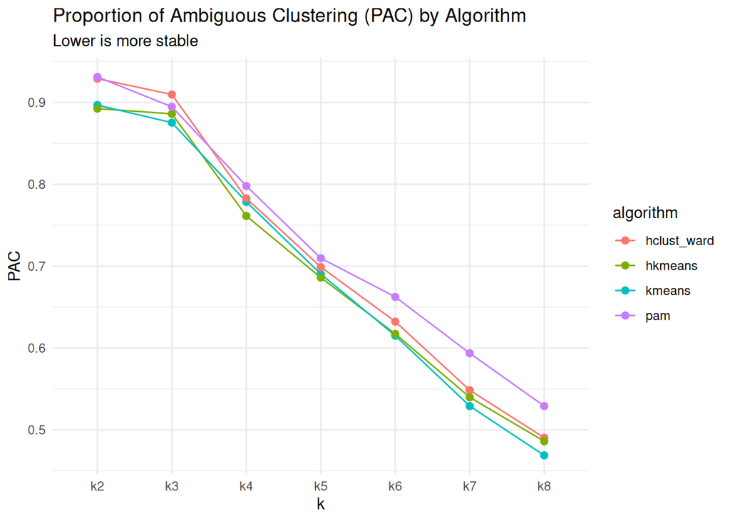

```r
plot_pac_compare(pipeline_calendar$pac)
```

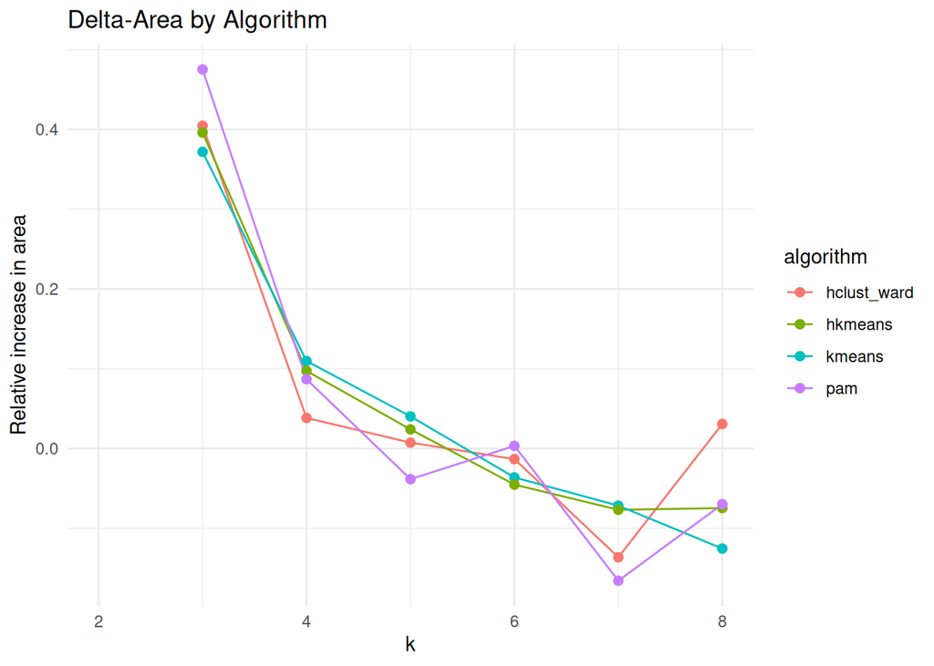

```r
plot_delta_area_compare(pipeline_calendar$delta_area)
```

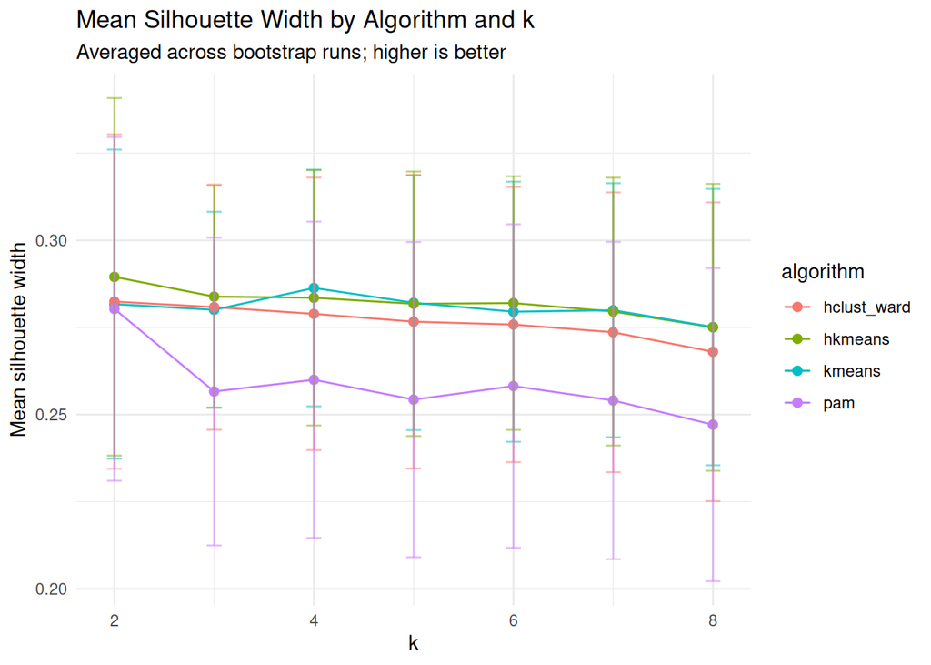

```r
plot_silhouette_compare(pipeline_calendar$quality_summary)
```

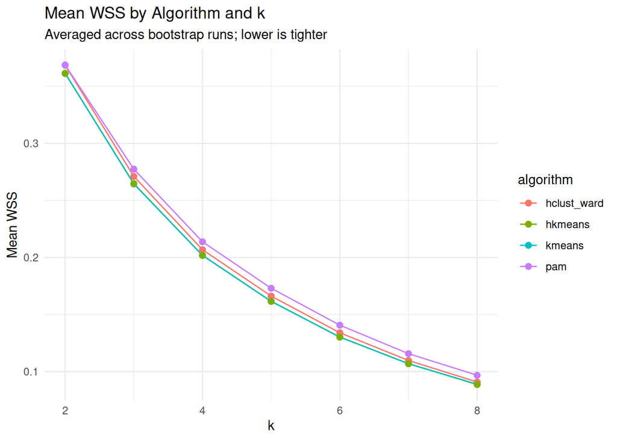

```r
plot_wss_compare(pipeline_calendar$quality_summary)
```

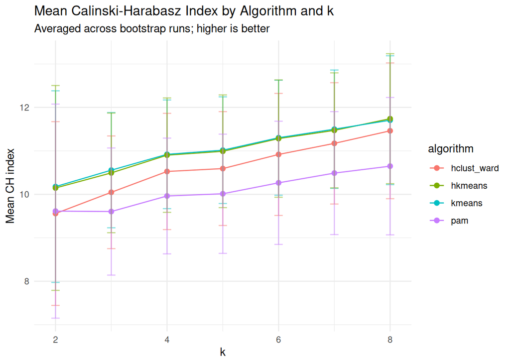

```r
plot_ch_compare(pipeline_calendar$quality_summary)
```

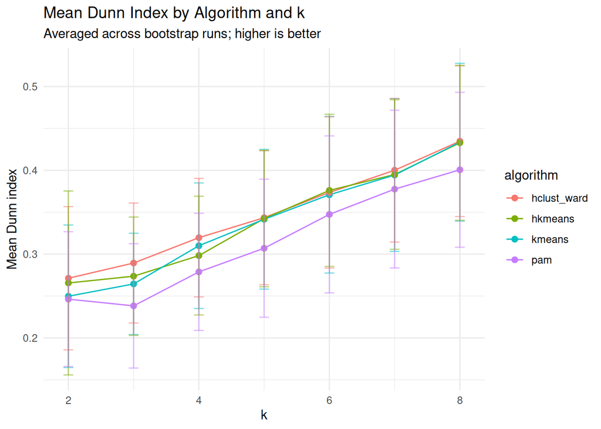

```r
plot_dunn_compare(pipeline_calendar$quality_summary)
```

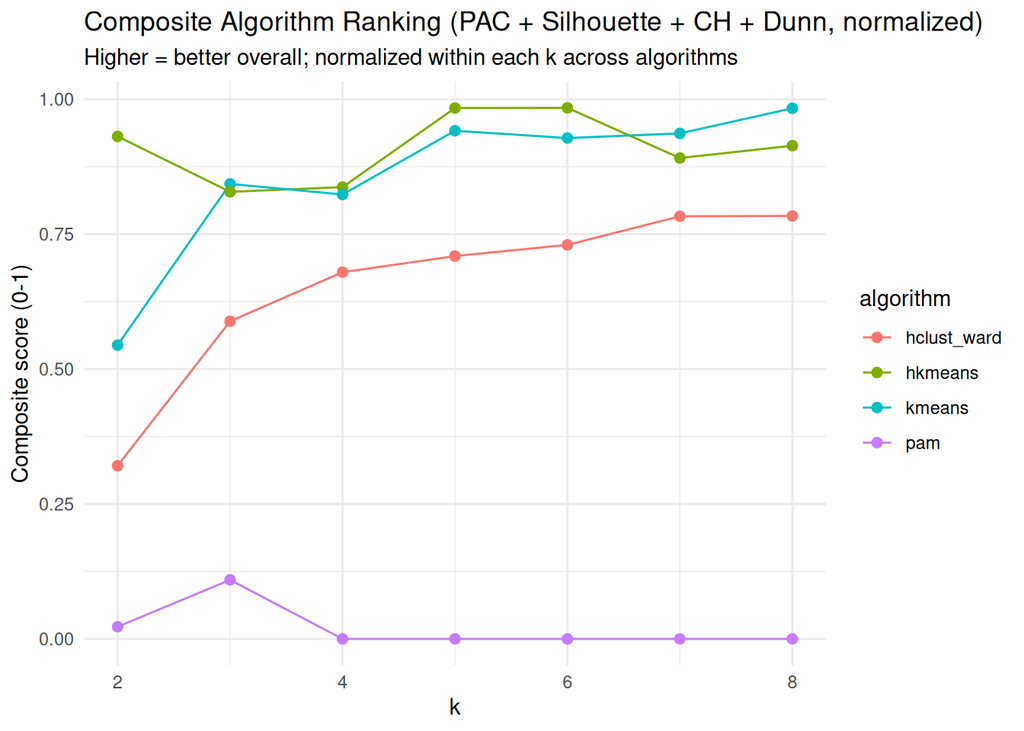

```r
algo_ranking <- compute_algorithm_ranking(pipeline_calendar$quality_summary, pipeline_calendar$pac)
plot_algorithm_ranking(algo_ranking)
```

Then for the shifted year partition metrics:

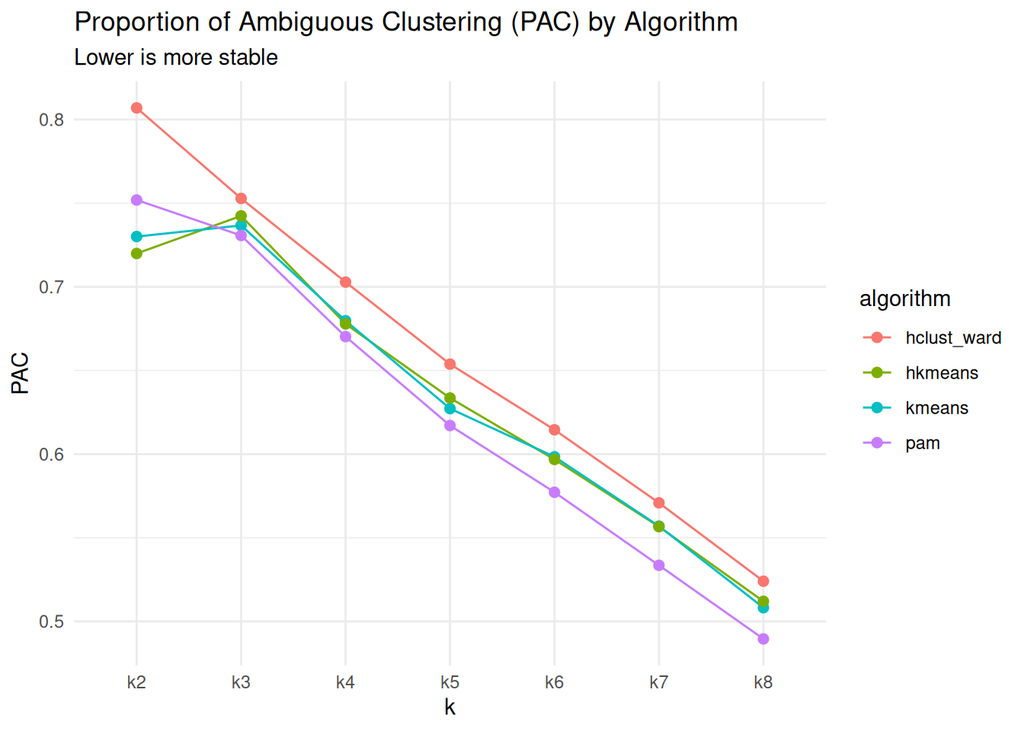

```r
plot_pac_compare(pipeline_shifted$pac)
```

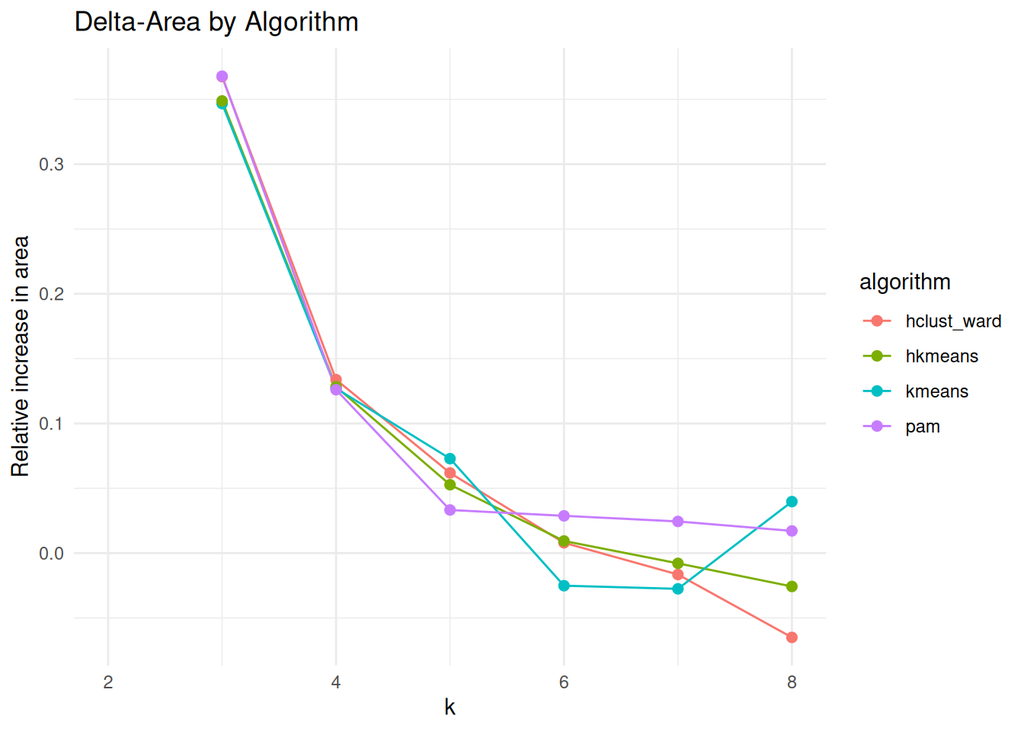

```r
plot_delta_area_compare(pipeline_shifted$delta_area)
```

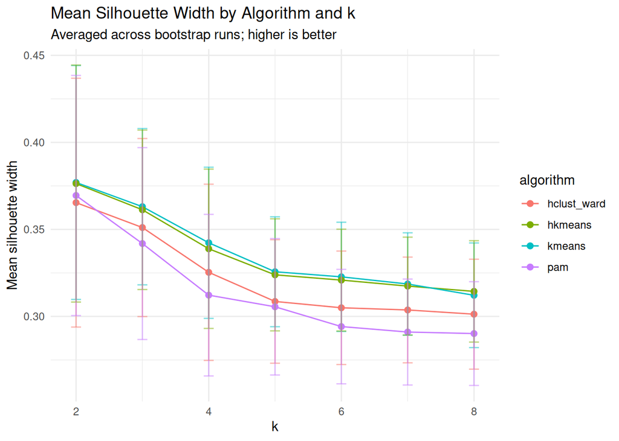

```r
plot_silhouette_compare(pipeline_shifted$quality_summary)
```

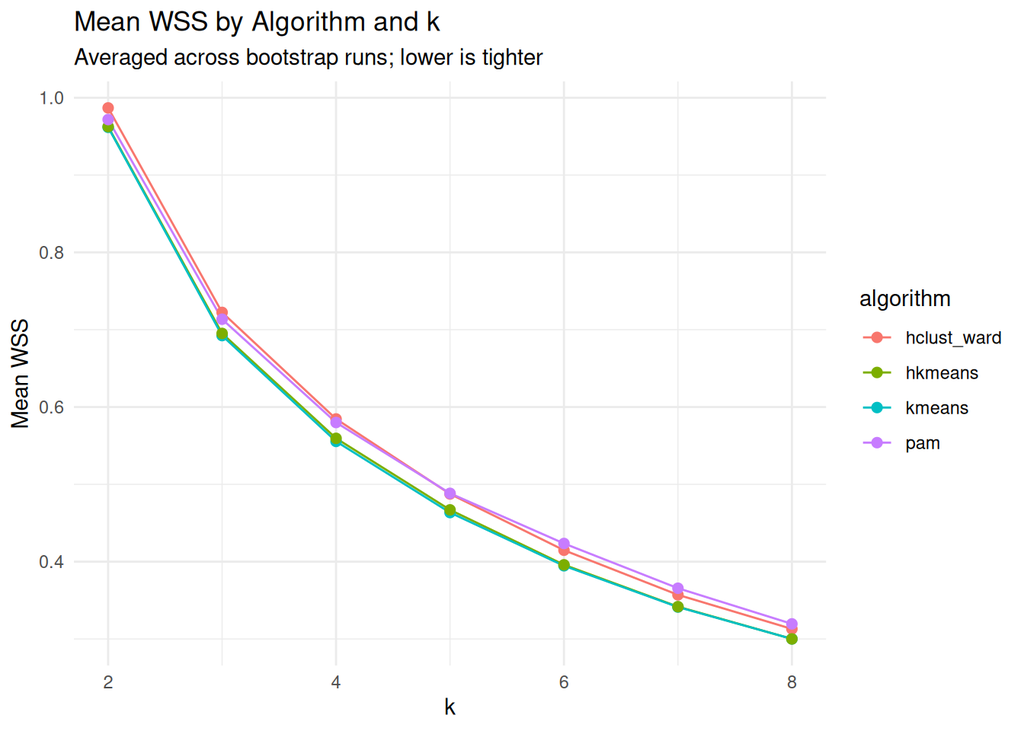

```r
plot_wss_compare(pipeline_shifted$quality_summary)
```

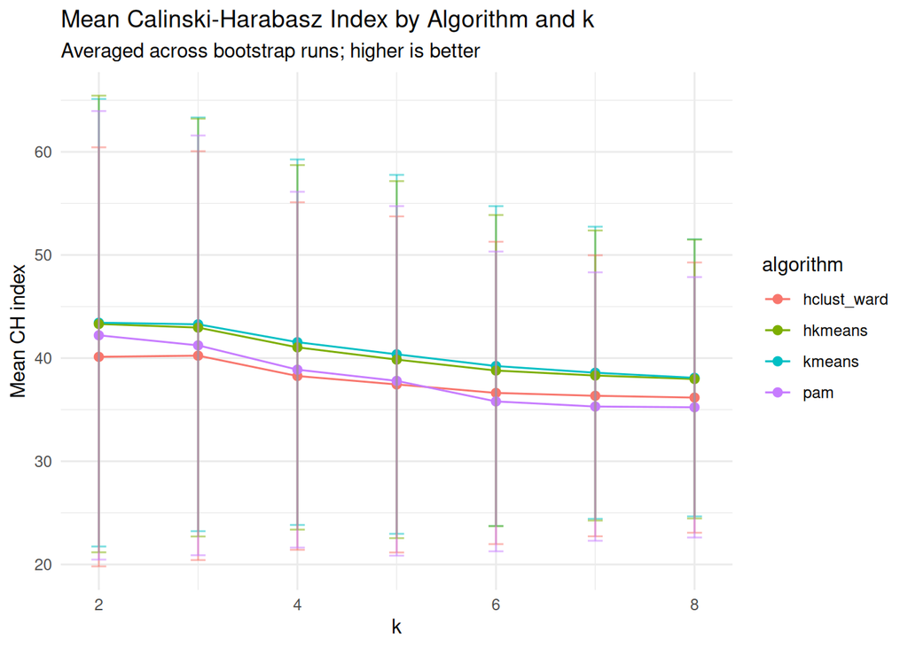

```r
plot_ch_compare(pipeline_shifted$quality_summary)
```

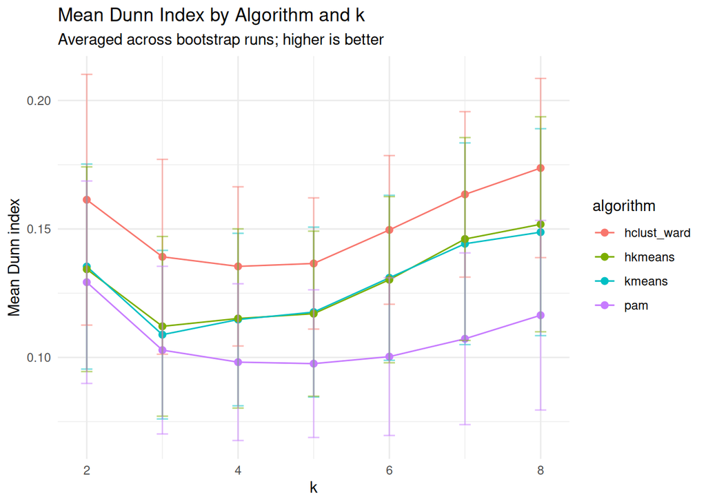

```r
plot_dunn_compare(pipeline_shifted$quality_summary)
```

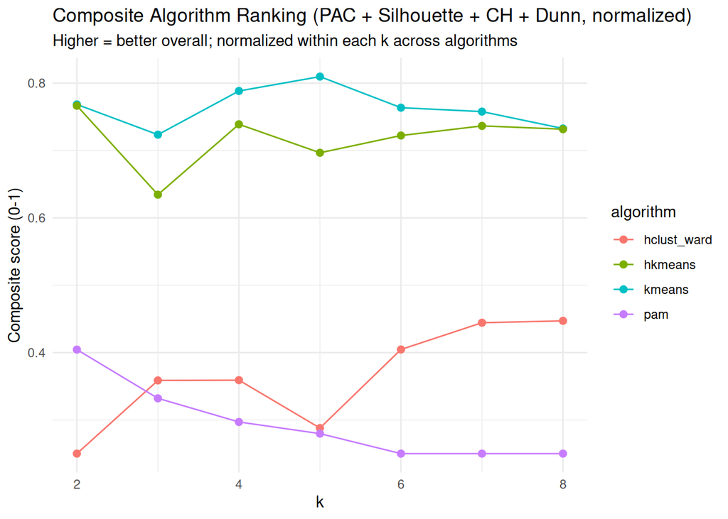

```r
algo_ranking_shifted <- compute_algorithm_ranking(pipeline_shifted$quality_summary, pipeline_shifted$pac)
plot_algorithm_ranking(algo_ranking_shifted)
```

### 5.4 Determination of Ensemble k-value From Anchor Year

To determine the overall final k-value to use for the ensemble clustering we will compute metrics based on the anchor year of each dataset. The anchor year is the year which has the most country-to-country representation in the dataset, which was computed while creating the `*_pass` data partitions.

First we’ll compute assessment metrics for the calendar year partition:

```r
anchor_year_matrix <- pipeline_calendar$year_mats[[co_cy_set$max_year]]$matrix
k_panel <- run_k_selection_panel(anchor_year_matrix, k_range = 2:8)
```

```
## Running elbow method...
## WARNING - Automated elbow selection may be inaccurate!
## Running silhouette-max method...
## Running Calinski-Harabasz peak method...
```

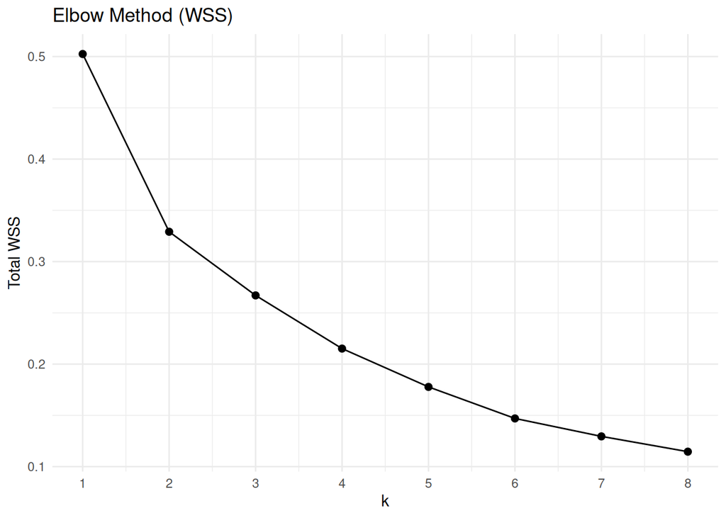

```r
# plot_elbow() RETURNS a list of 3 ggplot objects -- it does NOT
# display them automatically in a script. Print each explicitly:
panel_plots <- plot_k_selection_panel(k_panel)
print(panel_plots$elbow)
```

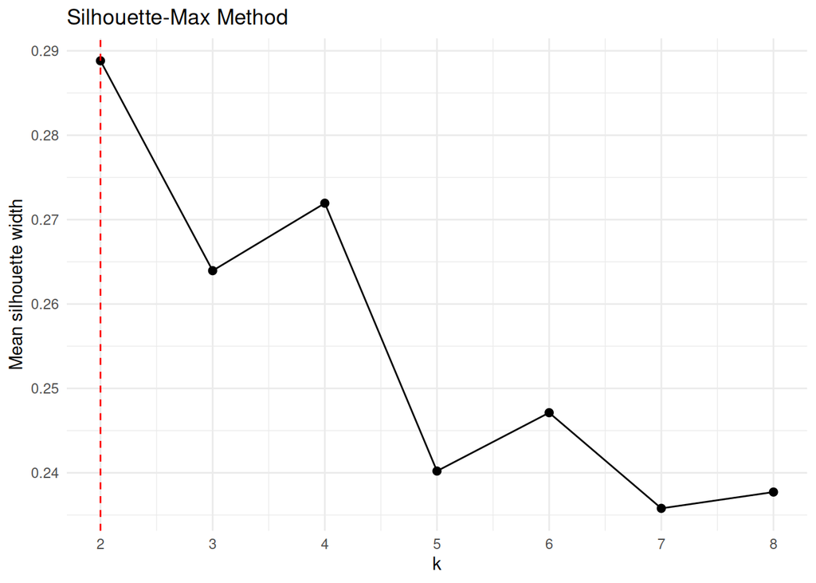

```r
print(panel_plots$silhouette)
```

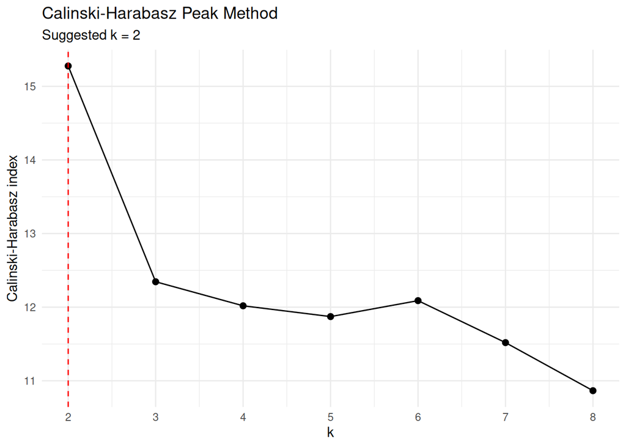

```r
print(panel_plots$ch)
```

Overall, for the calendar year partition, the metrics point to an optimum k-value of k = 2.

Now we’ll repeat the assessment metrics for the shifted year partition:

```r
# anchor year matrix and metric calculation
anchor_year_matrix_shifted <- pipeline_shifted$year_mats[[co_sy_set$max_year]]$matrix
k_panel_shifted <- run_k_selection_panel(anchor_year_matrix_shifted, k_range = 2:8)
```

```
## Running elbow method...
## WARNING - Automated elbow selection may be inaccurate!
## Running silhouette-max method...
## Running Calinski-Harabasz peak method...
```

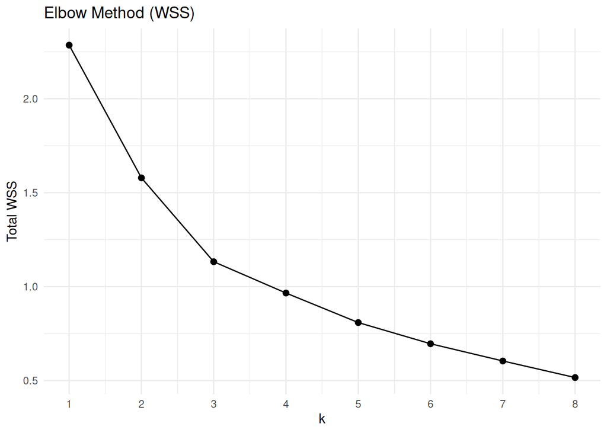

```r
# plotting of metrics
panel_plots_shifted <- plot_k_selection_panel(k_panel_shifted)
print(panel_plots_shifted$elbow)
```

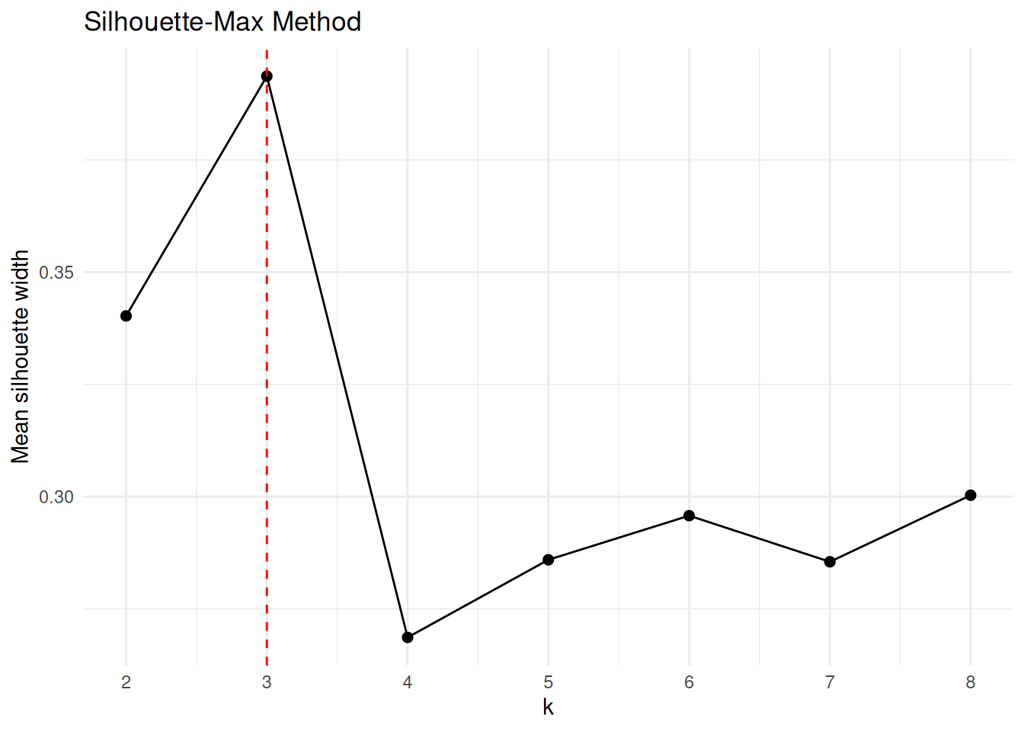

```r
print(panel_plots_shifted$silhouette)
```

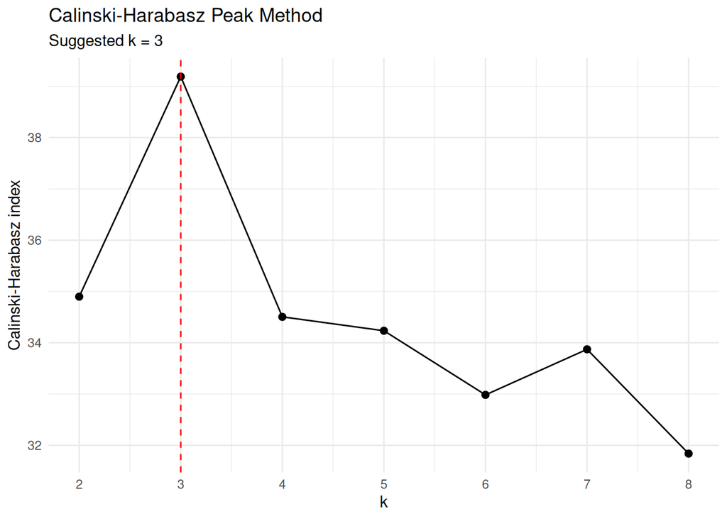

```r
print(panel_plots_shifted$ch)
```

Overall, for the shifted year partition, the metrics point to an optimal k-value of k = 3.

Now, we’ll set the chosen algorithm and k-values for each data partition and run a final robust resampling clustering run to generate the final ensemble sets.

```r
CHOSEN_ALGO <- "kmeans"
K_FINAL     <- 2
K_FINAL_SHIFTED <- 3

pipeline_calendar_final <- run_consensus_pipeline(co_cy_pass,
                                                  k_range = K_FINAL,
                                                  algos = CHOSEN_ALGO,
                                                  n_boot = 1000,
                                                  resample_pct = RESAMPLE_PCT,
                                                  dataset_type = "calendar")
```

```
## Standardizing columns for dataset type: calendar
## Building year matrices...
## Running ensemble (algorithm x year x resample x k), resample_pct = 0.90, kept separate per algorithm...
## This may take a while depending on data size and n_boot.
## Finished year 2011, algorithm kmeans (1000/10000 runs done)
## Finished year 2012, algorithm kmeans (2000/10000 runs done)
## Finished year 2013, algorithm kmeans (3000/10000 runs done)
## Finished year 2014, algorithm kmeans (4000/10000 runs done)
## Finished year 2015, algorithm kmeans (5000/10000 runs done)
## Finished year 2016, algorithm kmeans (6000/10000 runs done)
## Finished year 2017, algorithm kmeans (7000/10000 runs done)
## Finished year 2018, algorithm kmeans (8000/10000 runs done)
## Finished year 2019, algorithm kmeans (9000/10000 runs done)
## Finished year 2024, algorithm kmeans (10000/10000 runs done)
```

```r
pipeline_shifted_final <- run_consensus_pipeline(co_sy_pass,
                                                 k_range = K_FINAL_SHIFTED,
                                                 algos = CHOSEN_ALGO,
                                                 n_boot = 1000,
                                                 resample_pct = RESAMPLE_PCT,
                                                 dataset_type = "shifted")
```

```
## Standardizing columns for dataset type: shifted
## Building year matrices...
## Running ensemble (algorithm x year x resample x k), resample_pct = 0.90, kept separate per algorithm...
## This may take a while depending on data size and n_boot.
## Finished year 2010, algorithm kmeans (1000/11000 runs done)
## Finished year 2011, algorithm kmeans (2000/11000 runs done)
## Finished year 2012, algorithm kmeans (3000/11000 runs done)
## Finished year 2013, algorithm kmeans (4000/11000 runs done)
## Finished year 2014, algorithm kmeans (5000/11000 runs done)
## Finished year 2015, algorithm kmeans (6000/11000 runs done)
## Finished year 2016, algorithm kmeans (7000/11000 runs done)
## Finished year 2017, algorithm kmeans (8000/11000 runs done)
## Finished year 2018, algorithm kmeans (9000/11000 runs done)
## Finished year 2023, algorithm kmeans (10000/11000 runs done)
## Finished year 2024, algorithm kmeans (11000/11000 runs done)
```

We can then assess the relative stability of the resampled results per year.

First for the calendar year partition:

```r
all_year_stability <- compare_year_stability(pipeline_calendar_final$year_mats,
                                             algos = CHOSEN_ALGO,
                                             k_range = K_FINAL,
                                             resample_pct = RESAMPLE_PCT,
                                             n_boot = 1000) # for metric assessment not actual matrices
```

```
##
## Year 2011 stability summary (n = 23 countries):
## Overall mean Jaccard across all (algorithm, k) combinations tested: 0.858
##   year algorithm k mean_jaccard min_jaccard n_clusters
## 1 2011    kmeans 2    0.8583826   0.8519866          2
##
## Year 2012 stability summary (n = 27 countries):
## Overall mean Jaccard across all (algorithm, k) combinations tested: 0.833
##   year algorithm k mean_jaccard min_jaccard n_clusters
## 1 2012    kmeans 2    0.8332849   0.8200786          2
##
## Year 2013 stability summary (n = 27 countries):
## Overall mean Jaccard across all (algorithm, k) combinations tested: 0.724
##   year algorithm k mean_jaccard min_jaccard n_clusters
## 1 2013    kmeans 2    0.7235103   0.7197598          2
##
## Year 2014 stability summary (n = 25 countries):
## Overall mean Jaccard across all (algorithm, k) combinations tested: 0.793
##   year algorithm k mean_jaccard min_jaccard n_clusters
## 1 2014    kmeans 2    0.7926832    0.777278          2
##
## Year 2015 stability summary (n = 24 countries):
## Overall mean Jaccard across all (algorithm, k) combinations tested: 0.822
##   year algorithm k mean_jaccard min_jaccard n_clusters
## 1 2015    kmeans 2    0.8220343   0.8008213          2
##
## Year 2016 stability summary (n = 29 countries):
## Overall mean Jaccard across all (algorithm, k) combinations tested: 0.866
##   year algorithm k mean_jaccard min_jaccard n_clusters
## 1 2016    kmeans 2    0.8662976   0.8556036          2
##
## Year 2017 stability summary (n = 28 countries):
## Overall mean Jaccard across all (algorithm, k) combinations tested: 0.732
##   year algorithm k mean_jaccard min_jaccard n_clusters
## 1 2017    kmeans 2    0.7315968   0.7106221          2
##
## Year 2018 stability summary (n = 29 countries):
## Overall mean Jaccard across all (algorithm, k) combinations tested: 0.803
##   year algorithm k mean_jaccard min_jaccard n_clusters
## 1 2018    kmeans 2     0.803373   0.7869473          2
##
## Year 2019 stability summary (n = 31 countries):
## Overall mean Jaccard across all (algorithm, k) combinations tested: 0.850
##   year algorithm k mean_jaccard min_jaccard n_clusters
## 1 2019    kmeans 2    0.8504281   0.8403553          2
##
## Year 2024 stability summary (n = 31 countries):
## Overall mean Jaccard across all (algorithm, k) combinations tested: 0.859
##   year algorithm k mean_jaccard min_jaccard n_clusters
## 1 2024    kmeans 2    0.8590995   0.8427987          2
```

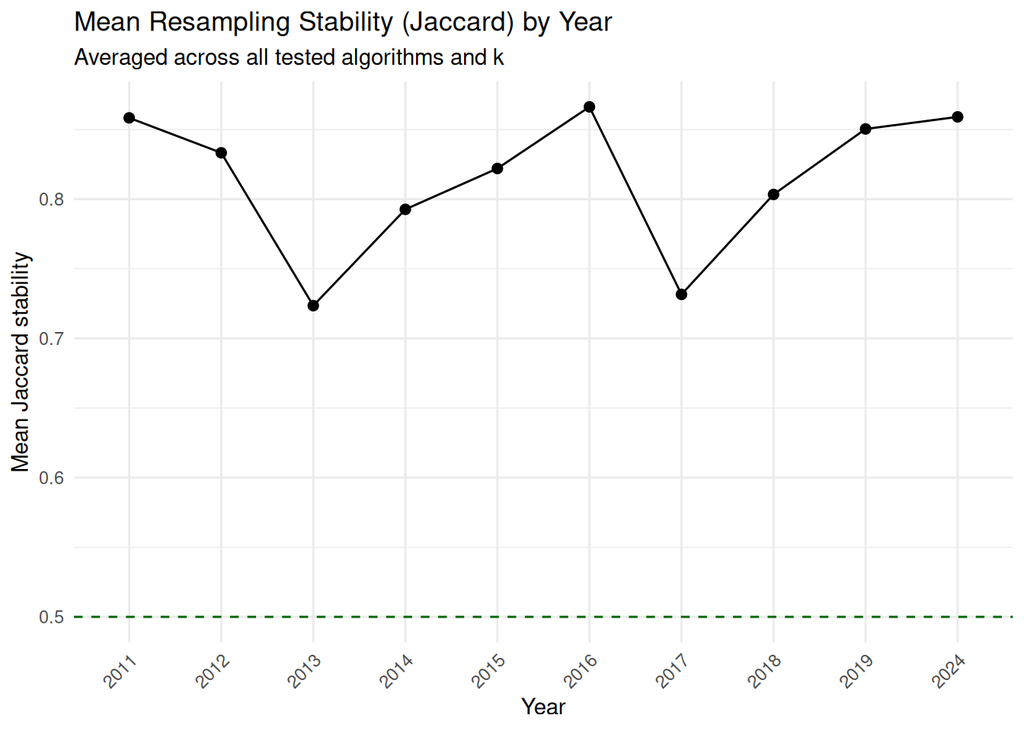

```r
plot_year_stability(all_year_stability)
```

Then for the shifted year partition:

```r
all_year_stability_shifted <- compare_year_stability(pipeline_shifted_final$year_mats,
                                                     algos = CHOSEN_ALGO,
                                                     k_range = K_FINAL_SHIFTED,
                                                     resample_pct = RESAMPLE_PCT,
                                                     n_boot = 1000) # for metric assessment not actual matrices
```

```
##
## Year 2010 stability summary (n = 64 countries):
## Overall mean Jaccard across all (algorithm, k) combinations tested: 0.781
##   year algorithm k mean_jaccard min_jaccard n_clusters
## 1 2010    kmeans 3    0.7808986   0.7394707          3
##
## Year 2011 stability summary (n = 62 countries):
## Overall mean Jaccard across all (algorithm, k) combinations tested: 0.846
##   year algorithm k mean_jaccard min_jaccard n_clusters
## 1 2011    kmeans 3    0.8457037   0.7992405          3
##
## Year 2012 stability summary (n = 74 countries):
## Overall mean Jaccard across all (algorithm, k) combinations tested: 0.781
##   year algorithm k mean_jaccard min_jaccard n_clusters
## 1 2012    kmeans 3     0.781353   0.7283439          3
##
## Year 2013 stability summary (n = 66 countries):
## Overall mean Jaccard across all (algorithm, k) combinations tested: 0.739
##   year algorithm k mean_jaccard min_jaccard n_clusters
## 1 2013    kmeans 3    0.7387467   0.6287125          3
##
## Year 2014 stability summary (n = 72 countries):
## Overall mean Jaccard across all (algorithm, k) combinations tested: 0.888
##   year algorithm k mean_jaccard min_jaccard n_clusters
## 1 2014    kmeans 3    0.8879833   0.8824902          3
##
## Year 2015 stability summary (n = 80 countries):
## Overall mean Jaccard across all (algorithm, k) combinations tested: 0.862
##   year algorithm k mean_jaccard min_jaccard n_clusters
## 1 2015    kmeans 3     0.862217   0.8304311          3
##
## Year 2016 stability summary (n = 73 countries):
## Overall mean Jaccard across all (algorithm, k) combinations tested: 0.872
##   year algorithm k mean_jaccard min_jaccard n_clusters
## 1 2016    kmeans 3    0.8719522   0.8546861          3
##
## Year 2017 stability summary (n = 79 countries):
## Overall mean Jaccard across all (algorithm, k) combinations tested: 0.880
##   year algorithm k mean_jaccard min_jaccard n_clusters
## 1 2017    kmeans 3    0.8801873   0.8755176          3
##
## Year 2018 stability summary (n = 78 countries):
## Overall mean Jaccard across all (algorithm, k) combinations tested: 0.791
##   year algorithm k mean_jaccard min_jaccard n_clusters
## 1 2018    kmeans 3    0.7907964   0.7631019          3
##
## Year 2023 stability summary (n = 77 countries):
## Overall mean Jaccard across all (algorithm, k) combinations tested: 0.784
##   year algorithm k mean_jaccard min_jaccard n_clusters
## 1 2023    kmeans 3    0.7840707    0.699276          3
##
## Year 2024 stability summary (n = 60 countries):
## Overall mean Jaccard across all (algorithm, k) combinations tested: 0.877
##   year algorithm k mean_jaccard min_jaccard n_clusters
## 1 2024    kmeans 3    0.8771721   0.8505331          3
```